# Project Final Submission Template

### Step 1a: Planning

#### Identify the information in the file your program will read

Some of the definitions of the columns mentioned below are sourced from the FBI:UCR website where more information can be found on the crimes. All the data mentioned below occurred in 2015. All column are bold and all definitions are in a blue font color for easier identification.

- **States**: 50 different states of the United States of America
- **University/College**: The names of universities and colleges within each state
- **Campus**: The names of the available campuses within each universities - Blanks present within this column due to not all universities and colleges having various campus locations
- **Student Enrollment**: total number of students enrolled in each universities or college with multiple campuses OR total number of students enrolled in each university or college that has one campus - Blanks values present due to university or college not reporting their enrollment count
- **Violent Crime**: the sum of Murder & Nonnegligent Manslaughter, Rape, Robbery, and Aggravated Assault data values occurred in each university or college
- **Murder & Nonnegligent Manslaughter**: The total number of times occurred within each university or college

*Definition*: the willful (nonnegligent) killing of one human being by another

- **Rape (revised definition)**: The total number of times occurred within each university or college - includes blank values due to missing information and lack of rape reports from some universities and colleges

*Definition*: Penetration, no matter how slight, of the vagina or anus with any body part or object, or oral penetration by a sex organ of another person, without the consent of the victim. (This includes the offenses of rape, sodomy, and sexual assault with an object as converted from data submitted via the National Incident-Based Reporting System)

- **Rape (legacy definition)**: The total frequency/times occurred in each university or college - includes blank values due to missing information and lack of rape reports from some universities and colleges

*Definition*: Forcible rape is the carnal knowledge of a female forcibly and against her will

- **Robbery**: The total frequency/times occurred in each university or college

*Definition*: the taking or attempting to take anything of value from the care, custody, or control of a person or persons by force or threat of force or violence and/or by putting the victim in fear

- **Aggravated Assault**: The total frequency/times occurred in each university or college

*Definition*: unlawful attack by one person upon another for the purpose of inflicting severe or aggravated bodily injury

- **Property Crime**: the sum of Burglary, Larceny Theft, Motor Vehicle Theft, and Arson data values occurred in each university or college
- **Burglary**: data values of the number of times this type of theft occurred in each university or college

*Definition*: the unlawful entry of a building to commit a felony or theft

- **Larceny Theft**: data values of the number of times this type of theft occurred in each university or college

*Definition*: the unlawful taking, carrying, leading, or riding away of property from the possession or constructive possession of another

- **Motor Vehicle Theft**: data values of the number of times this type of theft occurred in each university or college

*Definition*: the theft or attempted theft of a motor vehicle

- **Arson**: data values of the number of times this type of crime occurred in each university or college - includes blank values due to missing information and lack of arson reporting from some universities and colleges

*Definition*: any willful or malicious burning or attempting to burn, with or without intent to defraud, a dwelling house, public building, motor vehicle or aircraft, personal property of another, etc.

### Step 1b: Planning

#### Brainstorm ideas for what your program will produce

#### Select the idea you will build on for subsequent steps

The chosen idea was idea #1(also bolded for further clarification)

- **Idea One**:

Plot a bar chart that displays the property crime rate of each state from the inputted list. This visualization attempts to display property crime rates of the given list of US states. If all the US states are not present in the inputted list, the property crime rate would be zero for the missing US states.

```
How To/Computation:
```

Total state property crime is the sum of all property crime data values in every unversity and college for each state. Total number of enrollment in each state is the sum of all the students enrolled in every university and college in each state. The property crime rate would be attained by dividing the total state property crime by the total number of enrollment in each given state of the list.

- *Idea Two*:

Plot a scatterplot of total number of students enrolled for each inputted state(x axis) and total frequency of the violent crime per state (y axis). Each point in the scatterplot would be representing each state that is given by the inputted list. This visualization attempts to find the top three states from the list with the highest frequency of violent crime and student enrollment.

```
How To/Computation:
```

Total number of students in each inputted state is the sum of all the students enrolled in every university and college in each state. Frequency of the violent crime per state is the violent crime of every university and college of each state summed up.

- *Idea Three*:

Plot a pie chart of the total number of property crime occured in the dataset and how many percentages of it belongs to the inputted list of states. This visualization attempts to find how many percentages from the total property crime, occured in US universities and colleges, belongs to the states inputted in the list. In other words out of all the property crime occured on campus how much of it belongs to each inputted state.

```
How To/Computation:
```

Sum all the property crime of all the US states to get the total number of property crime. Sum all the property crime of each university or college of the inputted states to find the total property crime of each state from the list. Divide the total property crime of each state inputted by the total property crime within the US then times it by 100 to get the percentage of property crime occured in each state given by the list.

### Step 1c: Planning

#### Write or draw examples of what your program will produce

The goal of this project is to find the state with the highest property crime rate given a list of US states. The information source for this project is in a file called 'crimes_by_campus.csv', when calling the main function, the input and output would look like:

```
main('crimes_by_campus.csv')
```

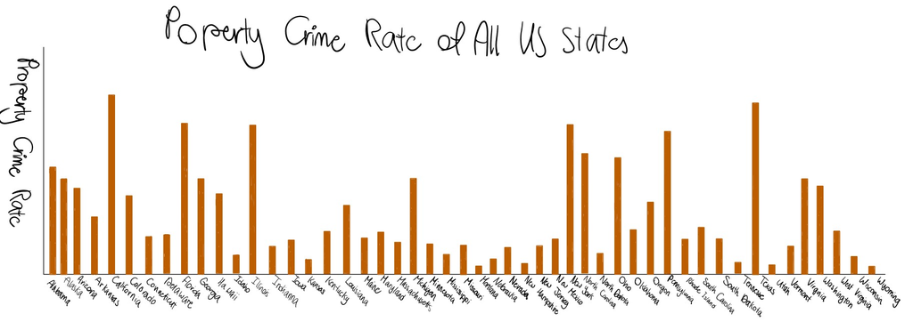

The goal of the main function is to produce a bar graph of all us states and their property crime rates where the veiwer can distinguish between the state with the highest property crime rate within the inputted list.

The graph should have one bar for each US states and the percentage of each property crime rate in each state. The bar that is the tallest among all the states, is the state with the highest property crime rate. The graph above is an example of inputting all 50 US states to visualize all states' property crime rates. Keep in mind that the values for the property crime rates in the graph above are only examples and they do not reflect the results from the data set itself.

### Step 2a: Building

#### Document which information you will represent in your data definitions

#### Design data definitions

The information represented:

1. **States**:
   - *Importance*: Included this information from the data because I needed to separate my data values on the bar graph and using the states was the simplest and most effective way (easier for the viewer to ditinguish between bar heights).
   - *Definition Type*: I decided to use an enumeration for this to specify and be clear with the name of each state - showing that they are all part of the US. The alternative was to use data definition for a string which I decided against since it would be too broad for what I was looking for.
2. **Student Enrollment**:
   - *Importance*: Included this information because I needed to find the population of people attending university or college within each state. It was also included since this column is used to generate the output of my graph.
   - *Definition Type*: I decided to represent this data dfinition as a list of integers (arbitrary sized) for the simplicity of the code and the fact that later into the project I would have to add up all student enrollment (integers) from a list
3. **Property Crime**:
   - *Importance*: Included this information since it is the other part of how I generate the output for the bars on my graph.
   - It was the ideal column to choose from compared to others (eg. violent crime) since it had higher data values therefore making the calculation simpler and easier to understand.
   - *Definition Type*: The data definition is the same as student enrollment - list of integers (arbitrary sized) since I will be adding up all the property crimes in my function

```python
from cs103 import *
from typing import NamedTuple, List
import csv
from typing import Optional
from enum import Enum
import matplotlib.pyplot as plt
##################
# Data Definitions

UsStates = Enum('UsStates', ['Alabama', 'Alaska', 'Arizona', 'Arkansas', 'California',
                            'Colorado', 'Connecticut', 'Delaware', 'Florida', 'Georgia',
                            'Hawaii', 'Idaho', 'Illinois', 'Indiana', 'Iowa', 'Kansas',
                            'Kentucky', 'Louisiana', 'Maine', 'Maryland', 'Massachusetts',
                            'Michigan', 'Minnesota', 'Mississippi', 'Missouri', 'Montana',
                            'Nebraska', 'Nevada', 'New_Hampshire', 'New_Jersey', 'New_Mexico',
                            'New_York', 'North_Carolina', 'North_Dakota', 'Ohio', 'Oklahoma',
                            'Oregon', 'Pennsylvania', 'Rhode_Island', 'South_Carolina',
                            'South_Dakota', 'Tennessee', 'Texas', 'Utah', 'Vermont', 'Virginia',
                            'Washington', 'West_Virginia', 'Wisconsin', 'Wyoming'])
# interp. a state from United States of America (Total number of 50 states)
# examples are redundant for enumerations

# template based on enumeration (50 cases)
@typecheck
@typecheck
def fn_for_us_states(s: UsStates) -> ...:
    if s == UsStates.Alabama:
        return ...
    elif s == UsStates.Alaska:
        return ...
    elif s == UsStates.Arizona:
        return ...
    elif s == UsStates.Arkansas:
        return ...
    elif s == UsStates.California:
        return ...
    elif s == UsStates.Colorado:
        return ...
    elif s == UsStates.Connecticut:
        return ...
    elif s == UsStates.Delaware:
        return ...
    elif s == UsStates.Florida:
        return ...
    elif s == UsStates.Georgia:
        return ...
    elif s == UsStates.Hawaii:
        return ...
    elif s == UsStates.Idaho:
        return ...
    elif s == UsStates.Illinois:
        return ...
    elif s == UsStates.Indiana:
        return ...
    elif s == UsStates.Iowa:
        return ...
    elif s == UsStates.Kansas:
        return ...
    elif s == UsStates.Kentucky:
        return ...
    elif s == UsStates.Louisiana:
        return ...
    elif s == UsStates.Maine:
        return ...
    elif s == UsStates.Maryland:
        return ...
    elif s == UsStates.Massachusetts:
        return ...
    elif s == UsStates.Michigan:
        return ...
    elif s == UsStates.Minnesota:
        return ...
    elif s == UsStates.Mississippi:
        return ...
    elif s == UsStates.Missouri:
        return ...
    elif s == UsStates.Montana:
        return ...
    elif s == UsStates.Nebraska:
        return ...
    elif s == UsStates.Nevada:
        return ...
    elif s == UsStates.New_Hampshire:
        return ...
    elif s == UsStates.New_Jersey:
        return ...
    elif s == UsStates.New_Mexico:
        return ...
    elif s == UsStates.New_York:
        return ...
    elif s == UsStates.North_Carolina:
        return ...
    elif s == UsStates.North_Dakota:
        return ...
    elif s == UsStates.Ohio:
        return ...
    elif s == UsStates.Oklahoma:
        return ...
    elif s == UsStates.Oregon:
        return ...
    elif s == UsStates.Pennsylvania:
        return ...
    elif s == UsStates.Rhode_Island:
        return ...
    elif s == UsStates.South_Carolina:
        return ...
    elif s == UsStates.South_Dakota:
        return ...
    elif s == UsStates.Tennessee:
        return ...
    elif s == UsStates.Texas:
        return ...
    elif s == UsStates.Utah:
        return ...
    elif s == UsStates.Vermont:
        return ...
    elif s == UsStates.Virginia:
        return ...
    elif s == UsStates.Washington:
        return ...
    elif s == UsStates.West_Virginia:
        return ...
    elif s == UsStates.Wisconsin:
        return ...
    elif s == UsStates.Wyoming:
        return ...

CrimeData = NamedTuple('CrimeData', [('state', UsStates),
                                     ('enrollment', int),    # in range [0,...)
                                     ('prop_crime', int)])   # in range [0,...)
# interp. data of crime in 50 different states of the United States of America with the
# number of students enrolled in each state and the number of property crime committed
# in each state. The number of students enrolled and the number of property crimes committed
# can be a minimum of 0 or above.

CD1 = CrimeData(UsStates.Alabama, 0, 0)
CD2 = CrimeData(UsStates.Alaska, 230054, 543643)
CD3 = CrimeData(UsStates.Arizona, 234412, 7454)
CD4 = CrimeData(UsStates.Arkansas, 45453, 97878)
CD5 = CrimeData(UsStates.California, 7854, 2311)
CD6 = CrimeData(UsStates.Colorado, 1324, 55754)
CD7 = CrimeData(UsStates.Connecticut, 124324, 666)
CD8 = CrimeData(UsStates.Delaware, 9978, 8564)
CD9 = CrimeData(UsStates.Florida, 999, 24232)
CD10 = CrimeData(UsStates.Georgia, 111, 2)
CD11 = CrimeData(UsStates.Hawaii, 1000, 3)
CD12 = CrimeData(UsStates.Idaho, 10, 4)
CD13 = CrimeData(UsStates.Illinois, 123, 20)
CD14 = CrimeData(UsStates.Indiana, 444, 664)
CD15 = CrimeData(UsStates.Iowa, 345, 8976)
CD16 = CrimeData(UsStates.Kansas, 1, 6849)
CD17 = CrimeData(UsStates.Kentucky, 12, 953)
CD18 = CrimeData(UsStates.Louisiana, 1234, 849)
CD19 = CrimeData(UsStates.Maine, 3400, 953)
CD20 = CrimeData(UsStates.Maryland, 78600, 495)
CD21 = CrimeData(UsStates.Massachusetts, 20000, 64953)
CD22 = CrimeData(UsStates.Michigan, 600, 689)
CD23 = CrimeData(UsStates.Minnesota, 300, 84953)
CD24 = CrimeData(UsStates.Mississippi, 10, 6953)
CD25 = CrimeData(UsStates.Missouri, 353, 49)
CD26 = CrimeData(UsStates.Montana, 6556, 53)
CD27 = CrimeData(UsStates.Nebraska, 21123, 493)
CD28 = CrimeData(UsStates.Nevada, 4533567, 68)
CD29 = CrimeData(UsStates.New_Hampshire, 6678, 84)
CD30 = CrimeData(UsStates.New_Jersey, 777, 85)
CD31 = CrimeData(UsStates.New_Mexico, 4, 89)
CD32 = CrimeData(UsStates.New_York, 5432, 43)
CD33 = CrimeData(UsStates.North_Carolina, 9430, 63)
CD34 = CrimeData(UsStates.North_Dakota, 300, 693)
CD35 = CrimeData(UsStates.Ohio, 10000, 2456)
CD36 = CrimeData(UsStates.Oklahoma, 1, 2)
CD37 = CrimeData(UsStates.Oregon, 20, 543)
CD38 = CrimeData(UsStates.Pennsylvania, 560000, 6788)
CD39 = CrimeData(UsStates.Rhode_Island, 321, 77999)
CD40 = CrimeData(UsStates.South_Carolina, 100, 60000)
CD41 = CrimeData(UsStates.South_Dakota, 10, 68000)
CD42 = CrimeData(UsStates.Tennessee, 100000, 68495300)
CD43 = CrimeData(UsStates.Texas, 645, 67696)
CD44 = CrimeData(UsStates.Utah, 567, 245535)
CD45 = CrimeData(UsStates.Vermont, 4, 31)
CD46 = CrimeData(UsStates.Virginia, 137886, 99)
CD47 = CrimeData(UsStates.Washington, 2342, 890)
CD48 = CrimeData(UsStates.West_Virginia, 211, 8666)
CD49 = CrimeData(UsStates.Wisconsin, 23422, 2222)
CD50 = CrimeData(UsStates.Wyoming, 456, 213)

# template based on compound (3 fields) and reference rule (once)
@typecheck
def fn_for_crime_data(cd: CrimeData) -> ...:
    return ...(fn_for_us_states(cd.state),
               cd.enrollment,
               cd.prop_crime)

# List[CrimeData]
# interp. a list of crime data
LOCD0 = []
LOCD1 = [CD1, CD2]
LOCD1 = [CD1, CD2, CD3, CD4, CD5]

# template based on arbitrary-sized data and reference rule
@typecheck
def fn_for_locd(locd: List[CrimeData]) -> ...:
    # description of accumulator
    acc = ... # type: ...

    for cd in locd:
        acc = ...(fn_for_crime_data(cd), acc)

    return ...(acc)

# List[int]
# interp. a list of integers
LOI0 = []
LOI1 = [1, -12]

# template based on arbitrary-sized data
@typecheck
def fn_for_loi(loi: List[int]) -> ...:
    # description of accumulator
    acc = ... # type: ...

    for i in loi:
        acc = ...(i, acc)

    return ...(acc)

# List[float]
# interp. a list of floats
LOF0 = []
LOF1 = [0.0, 1.02]

# template based on arbitrary-sized data
@typecheck
def fn_for_lof(lof: List[float]) -> ...:
    # description of accumulator
    acc = ... # type: ...

    for f in lof:
        acc = ...(f, acc)

    return ...(acc)

# List[str]
# interp. a list of strings
LOS0 = []
LOS1 = ['hello', 'world']

# template based on arbitrary-sized data
@typecheck
def fn_for_los(los: List[str]) -> ...:
    # description of accumulator
    acc = ... # type: ...

    for s in los:
        acc = ...(s, acc)

    return ...(acc)
```

[output not shown]

### Step 2b and 2c: Building

#### Design a function to read the information and store it as data in your program

#### Design functions to analyze the data

Complete these steps in the code cell below. You will likely want to rename the analyze function so that the function name describes what your analysis function does.

```python
### Mini explaination for the code
# I'm so sorry in advance for the amount of code you will be reading in this project, there is A LOT.
# There is a function to find total enrollment, a function to find total crime and a function to find
# the crime rate for each state (there's also 2 helper functions per state that check the state type)
# ... there's 50 states, hence why the code became so long :)

# rates_together function was made instead of a traditional composition function since there would
# be many steps involved therefore making the program more error prone if the composition route
# was chosen. Having the rates_together allowed for more accuracy since each state has its own rate function

from matplotlib import pyplot
###########
# Functions

@typecheck
def main(filename: str) -> None:
    """
    Reads the file from given filename, analyzes the data, returns a visualization(bar graph)
    of property crime rates for each state of United States of America
    """
    # return None   #stub
    # Template from HtDAP, based on function composition

    return crime_rate_visual(read(filename))


@typecheck
def read(filename: str) -> List[CrimeData]:
    """
    reads information from the specified file and returns a list of Crime Data
    that includes the state, the university/college enrollment amount and the number of
    property crimes comitted.
    """
    # return []  #stub
    # Template from HtDAP

    # locd contains the result so far
    locd = [] # type: List[CrimeData]

    with open(filename) as csvfile:

        reader = csv.reader(csvfile)
        next(reader)

        for row in reader:
            if filter_empty_cells(row):
                cd = CrimeData(parse_state(row[0]), parse_int(row[3]), parse_int(row[10]))
                locd.append(cd)

    return locd

@typecheck
def crime_rate_visual(locd: List[CrimeData]) -> None:
    """
    plots a bar graph of property crime rates from a list of crime data. Each bar in the
    visualization represents the property crime rate of one state.
    """
    # return None  #stub
    # Template from viz


    state_num = [1,2,3,4,5,6,7,8,9,10,11,12,13,14,15,16,17,18,19,20,21,22,23,24,25,26,27,28,29,30,31,32,33,
                34,35,36,37,38,39,40,41,42,43,44,45,46,47,48,49,50]

    labels = ['Alabama', 'Alaska', 'Arizona', 'Arkansas', 'California',
                'Colorado', 'Connecticut', 'Delaware', 'Florida', 'Georgia',
                'Hawaii', 'Idaho', 'Illinois', 'Indiana', 'Iowa', 'Kansas',
                'Kentucky', 'Louisiana', 'Maine', 'Maryland','Massachusetts',
                'Michigan', 'Minnesota', 'Mississippi', 'Missouri', 'Montana',
                'Nebraska', 'Nevada', 'New Hampshire', 'New Jersey', 'New Mexico',
                'New York', 'North Carolina', 'North Dakota', 'Ohio', 'Oklahoma',
                'Oregon', 'Pennsylvania', 'Rhode Island', 'South Carolina',
                'South Dakota', 'Tennessee', 'Texas', 'Utah', 'Vermont', 'Virginia',
                'Washington', 'West Virginia', 'Wisconsin', 'Wyoming']

    y_values = rates_together(locd)

    # sets the spacing between each bar
    x = (range(len(state_num)))
    new_x = [0.25*i for i in x]

    # sets the size of the plot
    plt.figure(figsize=[20, 9])

    # set the labels for the axes
    plt.xlabel('All US States')
    plt.ylabel('Property Crime Rate')
    plt.title('Visualization of Property Crime Rate per Total Enrollment in ALL US States')

    # adds x axis labels and rotates them
    plt.bar(new_x, y_values, color = 'red', align='center', width=0.2)
    plt.xticks(new_x, labels)
    plt.xticks(rotation=75)

    # show the plot
    pyplot.show()

    return None

@typecheck
def filter_empty_cells(columns: List[str]) -> bool:
    """
    return True if the number of students enrolled in the university or college is reported.
    returns False if the university or college did not report their student enrollment count (meaning
    there is no data present for enrollment numbers for that institution)
    """
    # return True  #stub
    # template treats columns as atomic and uses indexing instead
    # return ...(columns)  #template

    return columns[3] != ""

@typecheck
def parse_state(s: str) -> UsStates:
    """
    return the corresponding form of UsStates when given a state name in a form of a string.
    ASSUMESTION: assumes that the inputted string is a US state name
    """
    # return UsStates.Alabama  #stub
    # return ...(s)  #template


    if s == 'Alabama':
        return UsStates.Alabama
    elif s == 'Alaska':
        return UsStates.Alaska
    elif s == 'Arizona':
        return UsStates.Arizona
    elif s == 'Arkansas':
        return UsStates.Arkansas
    elif s == 'California':
        return UsStates.California
    elif s == 'Colorado':
        return UsStates.Colorado
    elif s == 'Connecticut':
        return UsStates.Connecticut
    elif s == 'Delaware':
        return UsStates.Delaware
    elif s == 'Florida':
        return UsStates.Florida
    elif s == 'Georgia':
        return UsStates.Georgia
    elif s == 'Hawaii':
        return UsStates.Hawaii
    elif s == 'Idaho':
        return UsStates.Idaho
    elif s == 'Illinois':
        return UsStates.Illinois
    elif s == 'Indiana':
        return UsStates.Indiana
    elif s == 'Iowa':
        return UsStates.Iowa
    elif s == 'Kansas':
        return UsStates.Kansas
    elif s == 'Kentucky':
        return UsStates.Kentucky
    elif s == 'Louisiana':
        return UsStates.Louisiana
    elif s == 'Maine':
        return UsStates.Maine
    elif s == 'Maryland':
        return UsStates.Maryland
    elif s == 'Massachusetts':
        return UsStates.Massachusetts
    elif s == 'Michigan':
        return UsStates.Michigan
    elif s == 'Minnesota':
        return UsStates.Minnesota
    elif s == 'Mississippi':
        return UsStates.Mississippi
    elif s == 'Missouri':
        return UsStates.Missouri
    elif s == 'Montana' :
        return UsStates.Montana
    elif s == 'Nebraska' :
        return UsStates.Nebraska
    elif s == 'Nevada':
        return UsStates.Nevada
    elif s == 'New Hampshire':
        return UsStates.New_Hampshire
    elif s == 'New Jersey':
        return UsStates.New_Jersey
    elif s == 'New Mexico':
        return UsStates.New_Mexico
    elif s == 'New York':
        return UsStates.New_York
    elif s == 'North Carolina':
        return UsStates.North_Carolina
    elif s == 'North Dakota':
        return UsStates.North_Dakota
    elif s == 'Ohio':
        return UsStates.Ohio
    elif s == 'Oklahoma':
        return UsStates.Oklahoma
    elif s == 'Oregon':
        return UsStates.Oregon
    elif s == 'Pennsylvania':
        return UsStates.Pennsylvania
    elif s == 'Rhode Island':
        return UsStates.Rhode_Island
    elif s == 'South Carolina':
        return UsStates.South_Carolina
    elif s == 'South Dakota':
        return UsStates.South_Dakota
    elif s == 'Tennessee':
        return UsStates.Tennessee
    elif s == 'Texas':
        return UsStates.Texas
    elif s == 'Utah':
        return UsStates.Utah
    elif s == 'Vermont':
        return UsStates.Vermont
    elif s == 'Virginia':
        return UsStates.Virginia
    elif s == 'Washington':
        return UsStates.Washington
    elif s == 'West Virginia':
        return UsStates.West_Virginia
    elif s == 'Wisconsin':
        return UsStates.Wisconsin
    elif s == 'Wyoming':
        return UsStates.Wyoming
```

```python
@typecheck
def rates_together(locd: List[CrimeData]) -> list[float]:
    """
    returns a list of floats that represent the property crime rates of each state.
    If the inputted list of crime data doesn't include a state, the returning rate of said
    state in the list of floats is zero
    """
    # return []   #stub
    # template based on List[float]

    return [total_alabama_rate(locd), total_alaska_rate(locd), total_arizona_rate(locd),
             total_arkansas_rate(locd), total_california_rate(locd), total_colorado_rate(locd),
             total_connecticut_rate(locd), total_delaware_rate(locd), total_florida_rate(locd),
             total_georgia_rate(locd), total_hawaii_rate(locd), total_idaho_rate(locd), total_illinois_rate(locd),
             total_indiana_rate(locd), total_iowa_rate(locd), total_kansas_rate(locd), total_kentucky_rate(locd),
             total_louisiana_rate(locd), total_maine_rate(locd), total_maryland_rate(locd),
             total_massachusetts_rate(locd), total_michigan_rate(locd), total_minnesota_rate(locd),
             total_mississippi_rate(locd), total_missouri_rate(locd), total_montana_rate(locd),
             total_nebraska_rate(locd), total_nevada_rate(locd), total_new_hampshire_rate(locd), total_new_jersey_rate(locd),
             total_new_mexico_rate(locd), total_new_york_rate(locd), total_north_carolina_rate(locd),
             total_north_dakota_rate(locd), total_ohio_rate(locd), total_oklahoma_rate(locd),
             total_oregon_rate(locd), total_pennsylvania_rate(locd), total_rhode_island_rate(locd),
             total_south_carolina_rate(locd), total_south_dakota_rate(locd), total_tennessee_rate(locd),
             total_texas_rate(locd), total_utah_rate(locd), total_vermont_rate(locd),
             total_virginia_rate(locd), total_washington_rate(locd), total_west_virginia_rate(locd),
             total_wisconsin_rate(locd), total_wyoming_rate(locd)]



@typecheck
def total_alabama_enroll(locd: List[CrimeData]) -> int:
    """
    return an integer that represents the total number of enrollments
    in the state of Alabama. Return zero if there are no enrollments
    """
    # return 0   #stub
    # template based on List[CrimeData]

    # enroll is the sum of all enrollments seen in the list so far
    enroll = 0 # type: int

    for cd in locd:
        if alabama_checker(cd):
            enroll = enroll + cd.enrollment
        elif not_alabama_checker(cd):
            enroll = enroll + 0

    return enroll

@typecheck
def total_alaska_enroll(locd: List[CrimeData]) -> int:
    """
    return an integer that represents the total number of enrollments
    in the state of Alaska. Return zero if there are no enrollments
    """
    # return 0   #stub
    # template based on List[CrimeData]

    # enroll is the sum of all enrollments seen in the list so far
    enroll = 0 # type: int

    for cd in locd:
        if alaska_checker(cd):
                enroll = enroll + cd.enrollment
        elif not_alaska_checker(cd):
            enroll = enroll + 0
    return enroll

@typecheck
def total_arizona_enroll(locd: List[CrimeData]) -> int:
    """
    return an integer that represents the total number of enrollments
    in the state of Arizona. Return zero if there are no enrollments
    """
    # return 0   #stub
    # template based on List[CrimeData]

    # enroll is the sum of all enrollments seen in the list so far
    enroll = 0 # type: int

    for cd in locd:
        if arizona_checker(cd):
            enroll = enroll + cd.enrollment
        elif not_arizona_checker(cd):
            enroll = enroll + 0
    return enroll

@typecheck
def total_arkansas_enroll(locd: List[CrimeData]) -> int:
    """
    return an integer that represents the total number of enrollments
    in the state of Arkansas. Return zero if there are no enrollments
    """
    # return 0   #stub
    # template based on List[CrimeData]

    # enroll is the sum of all enrollments seen in the list so far
    enroll = 0 # type: int

    for cd in locd:
        if arkansas_checker(cd):
            enroll = enroll + cd.enrollment
        elif not_arkansas_checker(cd):
            enroll = enroll + 0
    return enroll

@typecheck
def total_california_enroll(locd: List[CrimeData]) -> int:
    """
    return an integer that represents the total number of enrollments
    in the state of California. Return zero if there are no enrollments
    """
    # return 0   #stub
    # template based on List[CrimeData]

    # enroll is the sum of all enrollments seen in the list so far
    enroll = 0 # type: int

    for cd in locd:
        if california_checker(cd):
            enroll = enroll + cd.enrollment
        elif not_california_checker(cd):
            enroll = enroll + 0
    return enroll


@typecheck
def total_colorado_enroll(locd: List[CrimeData]) -> int:
    """
    return an integer that represents the total number of enrollments
    in the state of Colorado. Return zero if there are no enrollments
    """
    # return 0   #stub
    # template based on List[CrimeData]

    # enroll is the sum of all enrollments seen in the list so far
    enroll = 0 # type: int

    for cd in locd:
        if colorado_checker(cd):
            enroll = enroll + cd.enrollment
        elif not_colorado_checker(cd):
            enroll = enroll + 0
    return enroll

@typecheck
def total_connecticut_enroll(locd: List[CrimeData]) -> int:
    """
    return an integer that represents the total number of enrollments
    in the state of Conneticut. Return zero if there are no enrollments
    """
    # return 0   #stub
    # template based on List[CrimeData]

    # enroll is the sum of all enrollments seen in the list so far
    enroll = 0 # type: int

    for cd in locd:
        if connecticut_checker(cd):
            enroll = enroll + cd.enrollment
        elif not_connecticut_checker(cd):
            enroll = enroll + 0
    return enroll

@typecheck
def total_delaware_enroll(locd: List[CrimeData]) -> int:
    """
    return an integer that represents the total number of enrollments
    in the state of Delaware. Return zero if there are no enrollments
    """
    # return 0   #stub
    # template based on List[CrimeData]
```

```python
    # enroll is the sum of all enrollments seen in the list so far
    enroll = 0 # type: int

    for cd in locd:
        if delaware_checker(cd):
            enroll = enroll + cd.enrollment
        elif not_delaware_checker(cd):
            enroll = enroll + 0
    return enroll

@typecheck
def total_florida_enroll(locd: List[CrimeData]) -> int:
    """
    return an integer that represents the total number of enrollments
    in the state of Florida. Return zero if there are no enrollments
    """
    # return 0   #stub
    # template based on List[CrimeData]

    # enroll is the sum of all enrollments seen in the list so far
    enroll = 0 # type: int

    for cd in locd:
        if florida_checker(cd):
            enroll = enroll + cd.enrollment
        elif not_florida_checker(cd):
            enroll = enroll + 0
    return enroll

@typecheck
def total_georgia_enroll(locd: List[CrimeData]) -> int:
    """
    return an integer that represents the total number of enrollments
    in the state of Georgia. Return zero if there are no enrollments
    """
    # return 0   #stub
    # template based on List[CrimeData]

    # enroll is the sum of all enrollments seen in the list so far
    enroll = 0 # type: int

    for cd in locd:
        if georgia_checker(cd):
            enroll = enroll + cd.enrollment
        elif not_georgia_checker(cd):
            enroll = enroll + 0
    return enroll

@typecheck
def total_hawaii_enroll(locd: List[CrimeData]) -> int:
    """
    return an integer that represents the total number of enrollments
    in the state of Hawaii. Return zero if there are no enrollments
    """
    # return 0   #stub
    # template based on List[CrimeData]

    # enroll is the sum of all enrollments seen in the list so far
    enroll = 0 # type: int

    for cd in locd:
        if hawaii_checker(cd):
            enroll = enroll + cd.enrollment
        elif not_hawaii_checker(cd):
            enroll = enroll + 0
    return enroll

@typecheck
def total_idaho_enroll(locd: List[CrimeData]) -> int:
    """
    return an integer that represents the total number of enrollments
    in the state of Idaho. Return zero if there are no enrollments
    """
    # return 0   #stub
    # template based on List[CrimeData]

    # enroll is the sum of all enrollments seen in the list so far
    enroll = 0 # type: int

    for cd in locd:
        if idaho_checker(cd):
            enroll = enroll + cd.enrollment
        elif not_idaho_checker(cd):
            enroll = enroll + 0
    return enroll

@typecheck
def total_illinois_enroll(locd: List[CrimeData]) -> int:
    """
    return an integer that represents the total number of enrollments
    in the state of Illinois. Return zero if there are no enrollments
    """
    # return 0   #stub
    # template based on List[CrimeData]

    # enroll is the sum of all enrollments seen in the list so far
    enroll = 0 # type: int

    for cd in locd:
        if illinois_checker(cd):
            enroll = enroll + cd.enrollment
        elif not_illinois_checker(cd):
            enroll = enroll + 0
    return enroll

@typecheck
def total_indiana_enroll(locd: List[CrimeData]) -> int:
    """
    return an integer that represents the total number of enrollments
    in the state of Indiana. Return zero if there are no enrollments
    """
    # return 0   #stub
    # template based on List[CrimeData]

    # enroll is the sum of all enrollments seen in the list so far
    enroll = 0 # type: int

    for cd in locd:
        if indiana_checker(cd):
            enroll = enroll + cd.enrollment
        elif not_indiana_checker(cd):
            enroll = enroll + 0
    return enroll

@typecheck
def total_iowa_enroll(locd: List[CrimeData]) -> int:
    """
    return an integer that represents the total number of enrollments
    in the state of Iowa. Return zero if there are no enrollments
    """
    # return 0   #stub
    # template based on List[CrimeData]

    # enroll is the sum of all enrollments seen in the list so far
    enroll = 0 # type: int

    for cd in locd:
        if iowa_checker(cd):
            enroll = enroll + cd.enrollment
        elif not_iowa_checker(cd):
            enroll = enroll + 0
    return enroll

@typecheck
def total_kansas_enroll(locd: List[CrimeData]) -> int:
    """
    return an integer that represents the total number of enrollments
    in the state of Kansas. Return zero if there are no enrollments
    """
    # return 0   #stub
    # template based on List[CrimeData]

    # enroll is the sum of all enrollments seen in the list so far
    enroll = 0 # type: int

    for cd in locd:
        if kansas_checker(cd):
            enroll = enroll + cd.enrollment
        elif not_kansas_checker(cd):
            enroll = enroll + 0
    return enroll

@typecheck
def total_kentucky_enroll(locd: List[CrimeData]) -> int:
    """
    return an integer that represents the total number of enrollments
    in the state of Kentucky. Return zero if there are no enrollments
    """
    # return 0   #stub
    # template based on List[CrimeData]

    # enroll is the sum of all enrollments seen in the list so far
    enroll = 0 # type: int

    for cd in locd:
        if kentucky_checker(cd):
            enroll = enroll + cd.enrollment
        elif not_kentucky_checker(cd):
            enroll = enroll + 0
    return enroll

@typecheck
def total_louisiana_enroll(locd: List[CrimeData]) -> int:
    """
    return an integer that represents the total number of enrollments
    in the state of Louisiana. Return zero if there are no enrollments
    """
    # return 0   #stub
    # template based on List[CrimeData]

    # enroll is the sum of all enrollments seen in the list so far
    enroll = 0 # type: int

    for cd in locd:
        if louisiana_checker(cd):
            enroll = enroll + cd.enrollment
        elif not_louisiana_checker(cd):
            enroll = enroll + 0
    return enroll

@typecheck
def total_maine_enroll(locd: List[CrimeData]) -> int:
    """
    return an integer that represents the total number of enrollments
    in the state of Maine. Return zero if there are no enrollments
    """
    # return 0   #stub
    # template based on List[CrimeData]
```

```python
    # enroll is the sum of all enrollments seen in the list so far
    enroll = 0 # type: int

    for cd in locd:
        if maine_checker(cd):
            enroll = enroll + cd.enrollment
        elif not_maine_checker(cd):
            enroll = enroll + 0
    return enroll

@typecheck
def total_maryland_enroll(locd: List[CrimeData]) -> int:
    """
    return an integer that represents the total number of enrollments
    in the state of Maryland. Return zero if there are no enrollments
    """
    # return 0   #stub
    # template based on List[CrimeData]

    # enroll is the sum of all enrollments seen in the list so far
    enroll = 0 # type: int

    for cd in locd:
        if maryland_checker(cd):
            enroll = enroll + cd.enrollment
        elif not_maryland_checker(cd):
            enroll = enroll + 0
    return enroll


@typecheck
def total_massachusetts_enroll(locd: List[CrimeData]) -> int:
    """
    return an integer that represents the total number of enrollments
    in the state of Massachusetts. Return zero if there are no enrollments
    """
    # return 0   #stub
    # template based on List[CrimeData]

    # enroll is the sum of all enrollments seen in the list so far
    enroll = 0 # type: int

    for cd in locd:
        if massachusetts_checker(cd):
            enroll = enroll + cd.enrollment
        elif not_massachusetts_checker(cd):
            enroll = enroll + 0
    return enroll

@typecheck
def total_michigan_enroll(locd: List[CrimeData]) -> int:
    """
    return an integer that represents the total number of enrollments
    in the state of Michigan. Return zero if there are no enrollments
    """
    # return 0   #stub
    # template based on List[CrimeData]

    # enroll is the sum of all enrollments seen in the list so far
    enroll = 0 # type: int

    for cd in locd:
        if michigan_checker(cd):
            enroll = enroll + cd.enrollment
        elif not_michigan_checker(cd):
            enroll = enroll + 0
    return enroll

@typecheck
def total_minnesota_enroll(locd: List[CrimeData]) -> int:
    """
    return an integer that represents the total number of enrollments
    in the state of Minnesota. Return zero if there are no enrollments
    """
    # return 0   #stub
    # template based on List[CrimeData]

    # enroll is the sum of all enrollments seen in the list so far
    enroll = 0 # type: int

    for cd in locd:
        if minnesota_checker(cd):
            enroll = enroll + cd.enrollment
        elif not_minnesota_checker(cd):
            enroll = enroll + 0
    return enroll

@typecheck
def total_mississippi_enroll(locd: List[CrimeData]) -> int:
    """
    return an integer that represents the total number of enrollments
    in the state of Mississippi. Return zero if there are no enrollments
    """
    # return 0   #stub
    # template based on List[CrimeData]

    # enroll is the sum of all enrollments seen in the list so far
    enroll = 0 # type: int

    for cd in locd:
        if mississippi_checker(cd):
            enroll = enroll + cd.enrollment
        elif not_mississippi_checker(cd):
            enroll = enroll + 0
    return enroll

@typecheck
def total_missouri_enroll(locd: List[CrimeData]) -> int:
    """
    return an integer that represents the total number of enrollments
    in the state of Missouri. Return zero if there are no enrollments
    """
    # return 0   #stub
    # template based on List[CrimeData]

    # enroll is the sum of all enrollments seen in the list so far
    enroll = 0 # type: int

    for cd in locd:
        if missouri_checker(cd):
            enroll = enroll + cd.enrollment
        elif not_missouri_checker(cd):
            enroll = enroll + 0
    return enroll

@typecheck
def total_montana_enroll(locd: List[CrimeData]) -> int:
    """
    return an integer that represents the total number of enrollments
    in the state of Montana. Return zero if there are no enrollments
    """
    # return 0   #stub
    # template based on List[CrimeData]

    # enroll is the sum of all enrollments seen in the list so far
    enroll = 0 # type: int

    for cd in locd:
        if montana_checker(cd):
            enroll = enroll + cd.enrollment
        elif not_montana_checker(cd):
            enroll = enroll + 0
    return enroll

@typecheck
def total_nebraska_enroll(locd: List[CrimeData]) -> int:
    """
    return an integer that represents the total number of enrollments
    in the state of Nebraska. Return zero if there are no enrollments
    """
    # return 0   #stub
    # template based on List[CrimeData]

    # enroll is the sum of all enrollments seen in the list so far
    enroll = 0 # type: int

    for cd in locd:
        if nebraska_checker(cd):
            enroll = enroll + cd.enrollment
        elif not_nebraska_checker(cd):
            enroll = enroll + 0
    return enroll

@typecheck
def total_nevada_enroll(locd: List[CrimeData]) -> int:
    """
    return an integer that represents the total number of enrollments
    in the state of Nevada. Return zero if there are no enrollments
    """
    # return 0   #stub
    # template based on List[CrimeData]

    # enroll is the sum of all enrollments seen in the list so far
    enroll = 0 # type: int

    for cd in locd:
        if nevada_checker(cd):
            enroll = enroll + cd.enrollment
        elif not_nevada_checker(cd):
            enroll = enroll + 0
    return enroll

@typecheck
def total_new_hampshire_enroll(locd: List[CrimeData]) -> int:
    """
    return an integer that represents the total number of enrollments
    in the state of New Hampshire. Return zero if there are no enrollments
    """
    # return 0   #stub
    # template based on List[CrimeData]

    # enroll is the sum of all enrollments seen in the list so far
    enroll = 0 # type: int

    for cd in locd:
        if new_hampshire_checker(cd):
            enroll = enroll + cd.enrollment
        elif not_new_hampshire_checker(cd):
            enroll = enroll + 0
    return enroll
```

```python
@typecheck
def total_new_jersey_enroll(locd: List[CrimeData]) -> int:
    """
    return an integer that represents the total number of enrollments
    in the state of New Jersey. Return zero if there are no enrollments
    """
    # return 0   #stub
    # template based on List[CrimeData]

    # enroll is the sum of all enrollments seen in the list so far
    enroll = 0 # type: int

    for cd in locd:
        if new_jersey_checker(cd):
            enroll = enroll + cd.enrollment
        elif not_new_jersey_checker(cd):
            enroll = enroll + 0
    return enroll

@typecheck
def total_new_mexico_enroll(locd: List[CrimeData]) -> int:
    """
    return an integer that represents the total number of enrollments
    in the state of New Mexico. Return zero if there are no enrollments
    """
    # return 0   #stub
    # template based on List[CrimeData]

    # enroll is the sum of all enrollments seen in the list so far
    enroll = 0 # type: int

    for cd in locd:
        if new_mexico_checker(cd):
            enroll = enroll + cd.enrollment
        elif not_new_mexico_checker(cd):
            enroll = enroll + 0
    return enroll

def total_new_york_enroll(locd: List[CrimeData]) -> int:
    """
    return an integer that represents the total number of enrollments
    in the state of New York. Return zero if there are no enrollments
    """
    # return 0   #stub
    # template based on List[CrimeData]

    # enroll is the sum of all enrollments seen in the list so far
    enroll = 0 # type: int

    for cd in locd:
        if new_york_checker(cd):
            enroll = enroll + cd.enrollment
        elif not_new_york_checker(cd):
            enroll = enroll + 0
    return enroll

@typecheck
def total_north_carolina_enroll(locd: List[CrimeData]) -> int:
    """
    return an integer that represents the total number of enrollments
    in the state of North Carolina. Return zero if there are no enrollments
    """
    # return 0   #stub
    # template based on List[CrimeData]

    # enroll is the sum of all enrollments seen in the list so far
    enroll = 0 # type: int

    for cd in locd:
        if north_carolina_checker(cd):
            enroll = enroll + cd.enrollment
        elif not_north_carolina_checker(cd):
            enroll = enroll + 0
    return enroll

@typecheck
def total_north_dakota_enroll(locd: List[CrimeData]) -> int:
    """
    return an integer that represents the total number of enrollments
    in the state of Dakota. Return zero if there are no enrollments
    """
    # return 0   #stub
    # template based on List[CrimeData]

    # enroll is the sum of all enrollments seen in the list so far
    enroll = 0 # type: int

    for cd in locd:
        if north_dakota_checker(cd):
            enroll = enroll + cd.enrollment
        elif not_north_dakota_checker(cd):
            enroll = enroll + 0
    return enroll

@typecheck
def total_ohio_enroll(locd: List[CrimeData]) -> int:
    """
    return an integer that represents the total number of enrollments
    in the state of Ohio. Return zero if there are no enrollments
    """
    # return 0   #stub
    # template based on List[CrimeData]

    # enroll is the sum of all enrollments seen in the list so far
    enroll = 0 # type: int

    for cd in locd:
        if ohio_checker(cd):
            enroll = enroll + cd.enrollment
        elif not_ohio_checker(cd):
            enroll = enroll + 0
    return enroll

@typecheck
def total_oklahoma_enroll(locd: List[CrimeData]) -> int:
    """
    return an integer that represents the total number of enrollments
    in the state of Oklahoma. Return zero if there are no enrollments
    """
    # return 0   #stub
    # template based on List[CrimeData]

    # enroll is the sum of all enrollments seen in the list so far
    enroll = 0 # type: int

    for cd in locd:
        if oklahoma_checker(cd):
            enroll = enroll + cd.enrollment
        elif not_oklahoma_checker(cd):
            enroll = enroll + 0
    return enroll

@typecheck
def total_oregon_enroll(locd: List[CrimeData]) -> int:
    """
    return an integer that represents the total number of enrollments
    in the state of Oregon. Return zero if there are no enrollments
    """
    # return 0   #stub
    # template based on List[CrimeData]

    # enroll is the sum of all enrollments seen in the list so far
    enroll = 0 # type: int

    for cd in locd:
        if oregon_checker(cd):
            enroll = enroll + cd.enrollment
        elif not_oregon_checker(cd):
            enroll = enroll + 0
    return enroll

@typecheck
def total_pennsylvania_enroll(locd: List[CrimeData]) -> int:
    """
    return an integer that represents the total number of enrollments
    in the state of Pennsylvania. Return zero if there are no enrollments
    """
    # return 0   #stub
    # template based on List[CrimeData]

    # enroll is the sum of all enrollments seen in the list so far
    enroll = 0 # type: int

    for cd in locd:
        if pennsylvania_checker(cd):
            enroll = enroll + cd.enrollment
        elif not_pennsylvania_checker(cd):
            enroll = enroll + 0
    return enroll

@typecheck
def total_rhode_island_enroll(locd: List[CrimeData]) -> int:
    """
    return an integer that represents the total number of enrollments
    in the state of Rhode Island. Return zero if there are no enrollments
    """
    # return 0   #stub
    # template based on List[CrimeData]

    # enroll is the sum of all enrollments seen in the list so far
    enroll = 0 # type: int

    for cd in locd:
        if rhode_island_checker(cd):
            enroll = enroll + cd.enrollment
        elif not_rhode_island_checker(cd):
            enroll = enroll + 0
    return enroll

@typecheck
def total_south_carolina_enroll(locd: List[CrimeData]) -> int:
    """
    return an integer that represents the total number of enrollments
    in the state of South Carolina. Return zero if there are no enrollments
    """
    # return 0   #stub
    # template based on List[CrimeData]
```

```python
    # enroll is the sum of all enrollments seen in the list so far
    enroll = 0 # type: int

    for cd in locd:
        if south_carolina_checker(cd):
            enroll = enroll + cd.enrollment
        elif not_south_carolina_checker(cd):
            enroll = enroll + 0
    return enroll

@typecheck
def total_south_dakota_enroll(locd: List[CrimeData]) -> int:
    """
    return an integer that represents the total number of enrollments
    in the state of South Dakota. Return zero if there are no enrollments
    """
    # return 0   #stub
    # template based on List[CrimeData]

    # enroll is the sum of all enrollments seen in the list so far
    enroll = 0 # type: int

    for cd in locd:
        if south_dakota_checker(cd):
            enroll = enroll + cd.enrollment
        elif not_south_dakota_checker(cd):
            enroll = enroll + 0
    return enroll

@typecheck
def total_tennessee_enroll(locd: List[CrimeData]) -> int:
    """
    return an integer that represents the total number of enrollments
    in the state of Tennessee. Return zero if there are no enrollments
    """
    # return 0   #stub
    # template based on List[CrimeData]

    # enroll is the sum of all enrollments seen in the list so far
    enroll = 0 # type: int

    for cd in locd:
        if tennessee_checker(cd):
            enroll = enroll + cd.enrollment
        elif not_tennessee_checker(cd):
            enroll = enroll + 0
    return enroll

@typecheck
def total_texas_enroll(locd: List[CrimeData]) -> int:
    """
    return an integer that represents the total number of enrollments
    in the state of Texas. Return zero if there are no enrollments
    """
    # return 0   #stub
    # template based on List[CrimeData]

    # enroll is the sum of all enrollments seen in the list so far
    enroll = 0 # type: int

    for cd in locd:
        if texas_checker(cd):
            enroll = enroll + cd.enrollment
        elif not_texas_checker(cd):
            enroll = enroll + 0
    return enroll

@typecheck
def total_utah_enroll(locd: List[CrimeData]) -> int:
    """
    return an integer that represents the total number of enrollments
    in the state of Utah. Return zero if there are no enrollments
    """
    # return 0   #stub
    # template based on List[CrimeData]

    # enroll is the sum of all enrollments seen in the list so far
    enroll = 0 # type: int

    for cd in locd:
        if utah_checker(cd):
            enroll = enroll + cd.enrollment
        elif not_utah_checker(cd):
            enroll = enroll + 0
    return enroll

@typecheck
def total_vermont_enroll(locd: List[CrimeData]) -> int:
    """
    return an integer that represents the total number of enrollments
    in the state of Vermont. Return zero if there are no enrollments
    """
    # return 0   #stub
    # template based on List[CrimeData]

    # enroll is the sum of all enrollments seen in the list so far
    enroll = 0 # type: int

    for cd in locd:
        if vermont_checker(cd):
            enroll = enroll + cd.enrollment
        elif not_vermont_checker(cd):
            enroll = enroll + 0
    return enroll

@typecheck
def total_virginia_enroll(locd: List[CrimeData]) -> int:
    """
    return an integer that represents the total number of enrollments
    in the state of Virginia. Return zero if there are no enrollments
    """
    # return 0   #stub
    # template based on List[CrimeData]

    # enroll is the sum of all enrollments seen in the list so far
    enroll = 0 # type: int

    for cd in locd:
        if virginia_checker(cd):
            enroll = enroll + cd.enrollment
        elif not_virginia_checker(cd):
            enroll = enroll + 0
    return enroll

@typecheck
def total_washington_enroll(locd: List[CrimeData]) -> int:
    """
    return an integer that represents the total number of enrollments
    in the state of Washington. Return zero if there are no enrollments
    """
    # return 0   #stub
    # template based on List[CrimeData]

    # enroll is the sum of all enrollments seen in the list so far
    enroll = 0 # type: int

    for cd in locd:
        if washington_checker(cd):
            enroll = enroll + cd.enrollment
        elif not_washington_checker(cd):
            enroll = enroll + 0
    return enroll

@typecheck
def total_west_virginia_enroll(locd: List[CrimeData]) -> int:
    """
    return an integer that represents the total number of enrollments
    in the state of West Virginia. Return zero if there are no enrollments
    """
    # return 0   #stub
    # template based on List[CrimeData]

    # enroll is the sum of all enrollments seen in the list so far
    enroll = 0 # type: int

    for cd in locd:
        if west_virginia_checker(cd):
            enroll = enroll + cd.enrollment
        elif not_west_virginia_checker(cd):
            enroll = enroll + 0
    return enroll

@typecheck
def total_wisconsin_enroll(locd: List[CrimeData]) -> int:
    """
    return an integer that represents the total number of enrollments
    in the state of Wisconsin. Return zero if there are no enrollments
    """
    # return 0   #stub
    # template based on List[CrimeData]

    # enroll is the sum of all enrollments seen in the list so far
    enroll = 0 # type: int

    for cd in locd:
        if wisconsin_checker(cd):
            enroll = enroll + cd.enrollment
        elif not_wisconsin_checker(cd):
            enroll = enroll + 0
    return enroll

@typecheck
def total_wyoming_enroll(locd: List[CrimeData]) -> int:
    """
    return an integer that represents the total number of enrollments
    in the state of Wyoming. Return zero if there are no enrollments
    """
    # return 0   #stub
    # template based on List[CrimeData]

    # enroll is the sum of all enrollments seen in the list so far
    enroll = 0 # type: int

    for cd in locd:
        if wyoming_checker(cd):
            enroll = enroll + cd.enrollment
        elif not_wyoming_checker(cd):
            enroll = enroll + 0
    return enroll
```

```python
@typecheck
def alabama_checker(cd: CrimeData) -> bool:
    """
    returns True if the state of the inputted crime data is Alabama
    returns False otherwise
    """
    # return False   #stub
    # template based on CrimeData

    return cd.state == UsStates.Alabama

@typecheck
def alaska_checker(cd: CrimeData) -> bool:
    """
    returns True if the state of the inputted crime data is Alaska
    returns False otherwise
    """
    # return False   #stub
    # template based on CrimeData

    return cd.state == UsStates.Alaska

@typecheck
def arizona_checker(cd: CrimeData) -> bool:
    """
    returns True if the state of the inputted crime data is Arizona
    returns False otherwise
    """
    # return False   #stub
    # template based on CrimeData

    return cd.state == UsStates.Arizona

@typecheck
def arkansas_checker(cd: CrimeData) -> bool:
    """
    returns True if the state of the inputted crime data is Arkansas
    returns False otherwise
    """
    # return False   #stub
    # template based on CrimeData

    return cd.state == UsStates.Arkansas

@typecheck
def california_checker(cd: CrimeData) -> bool:
    """
    returns True if the state of the inputted crime data is California
    returns False otherwise
    """
    # return False   #stub
    # template based on CrimeData

    return cd.state == UsStates.California

@typecheck
def colorado_checker(cd: CrimeData) -> bool:
    """
    returns True if the state of the inputted crime data is Colorado
    returns False otherwise
    """
    # return False   #stub
    # template based on CrimeData

    return cd.state == UsStates.Colorado

@typecheck
def connecticut_checker(cd: CrimeData) -> bool:
    """
    returns True if the state of the inputted crime data is Connecticut
    returns False otherwise
    """
    # return False   #stub
    # template based on CrimeData

    return cd.state == UsStates.Connecticut

@typecheck
def delaware_checker(cd: CrimeData) -> bool:
    """
    returns True if the state of the inputted crime data is Delaware
    returns False otherwise.
    """
    # return False   #stub
    # template based on CrimeData

    return cd.state == UsStates.Delaware

@typecheck
def florida_checker(cd: CrimeData) -> bool:
    """
    returns True if the state of the inputted crime data is Florida
    returns False otherwise
    """
    # return False   #stub
    # template based on CrimeData

    return cd.state == UsStates.Florida

@typecheck
def georgia_checker(cd: CrimeData) -> bool:
    """
    returns True if the state of the inputted crime data is Georgia
    returns False otherwise
    """
    # return False   #stub
    # template based on CrimeData

    return cd.state == UsStates.Georgia

@typecheck
def hawaii_checker(cd: CrimeData) -> bool:
    """
    returns True if the state of the inputted crime data is Hawaii
    returns False otherwise
    """
    # return False   #stub
    # template based on CrimeData

    return cd.state == UsStates.Hawaii

@typecheck
def idaho_checker(cd: CrimeData) -> bool:
    """
    returns True if the state of the inputted crime data is Idaho
    returns False otherwise
    """
    # return False   #stub
    # template based on CrimeData

    return cd.state == UsStates.Idaho

@typecheck
def illinois_checker(cd: CrimeData) -> bool:
    """
    returns True if the state of the inputted crime data is Illinois
    returns False otherwise
    """
    # return False   #stub
    # template based on CrimeData

    return cd.state == UsStates.Illinois

@typecheck
def indiana_checker(cd: CrimeData) -> bool:
    """
    returns True if the state of the inputted crime data is Indiana
    returns False otherwise
    """
    # return False   #stub
    # template based on CrimeData

    return cd.state == UsStates.Indiana

@typecheck
def iowa_checker(cd: CrimeData) -> bool:
    """
    returns True if the state of the inputted crime data is Iowa
    returns False otherwise
    """
    # return False   #stub
    # template based on CrimeData

    return cd.state == UsStates.Iowa

@typecheck
def kansas_checker(cd: CrimeData) -> bool:
    """
    returns True if the state of the inputted crime data is Kansas
    returns False otherwise
    """
    # return False   #stub
    # template based on CrimeData

    return cd.state == UsStates.Kansas

@typecheck
def kentucky_checker(cd: CrimeData) -> bool:
    """
    returns True if the state of the inputted crime data is Kentucky
    returns False otherwise
    """
    # return False   #stub
    # template based on CrimeData

    return cd.state == UsStates.Kentucky

@typecheck
def louisiana_checker(cd: CrimeData) -> bool:
    """
    returns True if the state of the inputted crime data is Louisiana
    returns False otherwise
    """
    # return False   #stub
    # template based on CrimeData

    return cd.state == UsStates.Louisiana

@typecheck
def maine_checker(cd: CrimeData) -> bool:
    """
    returns True if the state of the inputted crime data is Maine
    returns False otherwise
    """
    # return False   #stub
    # template based on CrimeData

    return cd.state == UsStates.Maine

@typecheck
def maryland_checker(cd: CrimeData) -> bool:
    """
    returns True if the state of the inputted crime data is Maryland
    returns False otherwise
    """
    # return False   #stub
    # template based on CrimeData

    return cd.state == UsStates.Maryland

@typecheck
def massachusetts_checker(cd: CrimeData) -> bool:
    """
    returns True if the state of the inputted crime data is Massachusetts
    returns False otherwise
    """
    # return False   #stub
    # template based on CrimeData

    return cd.state == UsStates.Massachusetts

@typecheck
def michigan_checker(cd: CrimeData) -> bool:
    """
    returns True if the state of the inputted crime data is Michigan
    returns False otherwise
    """
    # return False   #stub
    # template based on CrimeData

    return cd.state == UsStates.Michigan

@typecheck
def minnesota_checker(cd: CrimeData) -> bool:
    """
    returns True if the state of the inputted crime data is Minnesota
    returns False otherwise
    """
    # return False   #stub
    # template based on CrimeData
```

```python
    return cd.state == UsStates.Minnesota

@typecheck
def mississippi_checker(cd: CrimeData) -> bool:
    """
    returns True if the state of the inputted crime data is Mississippi
    returns False otherwise
    """
    # return False   #stub
    # template based on CrimeData

    return cd.state == UsStates.Mississippi

@typecheck
def missouri_checker(cd: CrimeData) -> bool:
    """
    returns True if the state of the inputted crime data is Missouri
    returns False otherwise
    """
    # return False   #stub
    # template based on CrimeData

    return cd.state == UsStates.Missouri

@typecheck
def montana_checker(cd: CrimeData) -> bool:
    """
    returns True if the state of the inputted crime data is Montana
    returns False otherwise
    """
    # return False   #stub
    # template based on CrimeData

    return cd.state == UsStates.Montana

@typecheck
def nebraska_checker(cd: CrimeData) -> bool:
    """
    returns True if the state of the inputted crime data is Nebraska
    returns False otherwise
    """
    # return False   #stub
    # template based on CrimeData

    return cd.state == UsStates.Nebraska

@typecheck
def nevada_checker(cd: CrimeData) -> bool:
    """
    returns True if the state of the inputted crime data is Nevada
    returns False otherwise
    """
    # return False   #stub
    # template based on CrimeData

    return cd.state == UsStates.Nevada

@typecheck
def new_hampshire_checker(cd: CrimeData) -> bool:
    """
    returns True if the state of the inputted crime data is New Hampshire
    returns False otherwise
    """
    # return False   #stub
    # template based on CrimeData

    return cd.state == UsStates.New_Hampshire

@typecheck
def new_jersey_checker(cd: CrimeData) -> bool:
    """
    returns True if the state of the inputted crime data is New Hampshire
    returns False otherwise
    """
    # return False   #stub
    # template based on CrimeData

    return cd.state == UsStates.New_Jersey

@typecheck
def new_mexico_checker(cd: CrimeData) -> bool:
    """
    returns True if the state of the inputted crime data is New Mexico
    returns False otherwise
    """
    # return False   #stub
    # template based on CrimeData

    return cd.state == UsStates.New_Mexico

@typecheck
def new_york_checker(cd: CrimeData) -> bool:
    """
    returns True if the state of the inputted crime data is New York
    returns False otherwise.
    """
    # return False   #stub
    # template based on CrimeData

    return cd.state == UsStates.New_York

@typecheck
def north_carolina_checker(cd: CrimeData) -> bool:
    """
    returns True if the state of the inputted crime data is North Carolina
    returns False otherwise
    """
    # return False   #stub
    # template based on CrimeData

    return cd.state == UsStates.North_Carolina

@typecheck
def north_dakota_checker(cd: CrimeData) -> bool:
    """
    returns True if the state of the inputted crime data is North Dakota
    returns False otherwise
    """
    # return False   #stub
    # template based on CrimeData

    return cd.state == UsStates.North_Dakota

@typecheck
def ohio_checker(cd: CrimeData) -> bool:
    """
    returns True if the state of the inputted crime data is Ohio
    returns False otherwise.
    """
    # return False   #stub
    # template based on CrimeData

    return cd.state == UsStates.Ohio

@typecheck
def oklahoma_checker(cd: CrimeData) -> bool:
    """
    returns True if the state of the inputted crime data is Oklahoma
    returns False otherwise
    """
    # return False   #stub
    # template based on CrimeData

    return cd.state == UsStates.Oklahoma

@typecheck
def oregon_checker(cd: CrimeData) -> bool:
    """
    returns True if the state of the inputted crime data is Oregon
    returns False otherwise
    """
    # return False   #stub
    # template based on CrimeData

    return cd.state == UsStates.Oregon

@typecheck
def pennsylvania_checker(cd: CrimeData) -> bool:
    """
    returns True if the state of the inputted crime data is Pennsylvania
    returns False otherwise
    """
    # return False   #stub
    # template based on CrimeData

    return cd.state == UsStates.Pennsylvania

@typecheck
def rhode_island_checker(cd: CrimeData) -> bool:
    """
    returns True if the state of the inputted crime data is Rhode Island
    returns False otherwise
    """
    # return False   #stub
    # template based on CrimeData

    return cd.state == UsStates.Rhode_Island

@typecheck
def south_carolina_checker(cd: CrimeData) -> bool:
    """
    returns True if the state of the inputted crime data is South Carolina
    returns False otherwise
    """
    # return False   #stub
    # template based on CrimeData

    return cd.state == UsStates.South_Carolina

@typecheck
def south_dakota_checker(cd: CrimeData) -> bool:
    """
    returns True if the state of the inputted crime data is South Dakota
    returns False otherwise
    """
    # return False   #stub
    # template based on CrimeData

    return cd.state == UsStates.South_Dakota

@typecheck
def tennessee_checker(cd: CrimeData) -> bool:
    """
    returns True if the state of the inputted crime data is Tennessee
    returns False otherwise
    """
    # return False   #stub
    # template based on CrimeData

    return cd.state == UsStates.Tennessee

@typecheck
def texas_checker(cd: CrimeData) -> bool:
    """
    returns True if the state of the inputted crime data is Texas
    returns False otherwise
    """
    # return False   #stub
    # template based on CrimeData

    return cd.state == UsStates.Texas

@typecheck
def utah_checker(cd: CrimeData) -> bool:
    """
    returns True if the state of the inputted crime data is Utah
    returns False otherwise
    """
    # return False   #stub
    # template based on CrimeData

    return cd.state == UsStates.Utah

@typecheck
def vermont_checker(cd: CrimeData) -> bool:
    """
    returns True if the state of the inputted crime data is Vermont
    returns False otherwise
    """
    # return False   #stub
    # template based on CrimeData
```

```python
    return cd.state == UsStates.Vermont

@typecheck
def virginia_checker(cd: CrimeData) -> bool:
    """
    returns True if the state of the inputted crime data is Virginia
    returns False otherwise
    """
    # return False   #stub
    # template based on CrimeData

    return cd.state == UsStates.Virginia

@typecheck
def washington_checker(cd: CrimeData) -> bool:
    """
    returns True if the state of the inputted crime data is Washington
    returns False otherwise
    """
    # return False   #stub
    # template based on CrimeData

    return cd.state == UsStates.Washington

@typecheck
def west_virginia_checker(cd: CrimeData) -> bool:
    """
    returns True if the state of the inputted crime data is West Virginia
    returns False otherwise
    """
    # return False   #stub
    # template based on CrimeData

    return cd.state == UsStates.West_Virginia

@typecheck
def wisconsin_checker(cd: CrimeData) -> bool:
    """
    returns True if the state of the inputted crime data is Wisconsin
    returns False otherwise
    """
    # return False   #stub
    # template based on CrimeData

    return cd.state == UsStates.Wisconsin

@typecheck
def wyoming_checker(cd: CrimeData) -> bool:
    """
    returns True if the state of the inputted crime data is Wyoming
    returns False otherwise
    """
    # return False   #stub
    # template based on CrimeData

    return cd.state == UsStates.Wyoming

@typecheck
def not_alabama_checker(cd: CrimeData) -> bool:
    """
    returns True if the state of the inputted crime data is not Alabama
    returns False otherwise
    """
    # return False   #stub
    # template based on CrimeData

    return cd.state != UsStates.Alabama

@typecheck
def not_alaska_checker(cd: CrimeData) -> bool:
    """
    returns True if the state of the inputted crime data is not Alaska
    returns False otherwise
    """
    # return False   #stub
    # template based on CrimeData

    return cd.state != UsStates.Alaska

@typecheck
def not_arizona_checker(cd: CrimeData) -> bool:
    """
    returns True if the state of the inputted crime data is not Arizona
    returns False otherwise
    """
    # return False   #stub
    # template based on CrimeData

    return cd.state != UsStates.Arizona

@typecheck
def not_arkansas_checker(cd: CrimeData) -> bool:
    """
    returns True if the state of the inputted crime data is not Arkansas
    returns False otherwise
    """
    # return False   #stub
    # template based on CrimeData

    return cd.state != UsStates.Arkansas

@typecheck
def not_california_checker(cd: CrimeData) -> bool:
    """
    returns True if the state of the inputted crime data is not California
    returns False otherwise
    """
    # return False   #stub
    # template based on CrimeData

    return cd.state != UsStates.California

@typecheck
def not_colorado_checker(cd: CrimeData) -> bool:
    """
    returns True if the state of the inputted crime data is not Colorado
    returns False otherwise
    """
    # return False   #stub
    # template based on CrimeData

    return cd.state != UsStates.Colorado

@typecheck
def not_connecticut_checker(cd: CrimeData) -> bool:
    """
    returns True if the state of the inputted crime data is not Connecticut
    returns False otherwise
    """
    # return False   #stub
    # template based on CrimeData

    return cd.state != UsStates.Connecticut

@typecheck
def not_delaware_checker(cd: CrimeData) -> bool:
    """
    returns True if the state of the inputted crime data is not Delaware
    returns False otherwise
    """
    # return False   #stub
    # template based on CrimeData

    return cd.state != UsStates.Delaware

@typecheck
def not_florida_checker(cd: CrimeData) -> bool:
    """
    returns True if the state of the inputted crime data is not Florida
    returns False otherwise
    """
    # return False   #stub
    # template based on CrimeData

    return cd.state != UsStates.Florida

@typecheck
def not_georgia_checker(cd: CrimeData) -> bool:
    """
    returns True if the state of the inputted crime data is not Georgia
    returns False otherwise
    """
    # return False   #stub
    # template based on CrimeData

    return cd.state != UsStates.Georgia

@typecheck
def not_hawaii_checker(cd: CrimeData) -> bool:
    """
    returns True if the state of the inputted crime data is not Hawaii
    returns False otherwise
    """
    # return False   #stub
    # template based on CrimeData

    return cd.state != UsStates.Hawaii

@typecheck
def not_idaho_checker(cd: CrimeData) -> bool:
    """
    returns True if the state of the inputted crime data is not Idaho
    returns False otherwise
    """
    # return False   #stub
    # template based on CrimeData

    return cd.state != UsStates.Idaho

@typecheck
def not_illinois_checker(cd: CrimeData) -> bool:
    """
    returns True if the state of the inputted crime data is not Illinois
    returns False otherwise
    """
    # return False   #stub
    # template based on CrimeData

    return cd.state != UsStates.Illinois

@typecheck
def not_indiana_checker(cd: CrimeData) -> bool:
    """
    returns True if the state of the inputted crime data is not Indiana
    returns False otherwise
    """
    # return False   #stub
    # template based on CrimeData

    return cd.state != UsStates.Indiana

@typecheck
def not_iowa_checker(cd: CrimeData) -> bool:
    """
    returns True if the state of the inputted crime data is not Iowa
    returns False otherwise
    """
    # return False   #stub
    # template based on CrimeData

    return cd.state != UsStates.Iowa

@typecheck
def not_kansas_checker(cd: CrimeData) -> bool:
    """
    returns True if the state of the inputted crime data is not Kansas
    returns False otherwise
    """
    # return False   #stub
    # template based on CrimeData

    return cd.state != UsStates.Kansas

@typecheck
def not_kentucky_checker(cd: CrimeData) -> bool:
    """
    returns True if the state of the inputted crime data is not Kentucky
    returns False otherwise
    """
    # return False   #stub
    # template based on CrimeData
```

```python
    return cd.state != UsStates.Kentucky

@typecheck
def not_louisiana_checker(cd: CrimeData) -> bool:
    """
    returns True if the state of the inputted crime data is not Louisiana
    returns False otherwise
    """
    # return False   #stub
    # template based on CrimeData

    return cd.state != UsStates.Louisiana

@typecheck
def not_maine_checker(cd: CrimeData) -> bool:
    """
    returns True if the state of the inputted crime data is not Maine
    returns False otherwise
    """
    # return False   #stub
    # template based on CrimeData

    return cd.state != UsStates.Maine

@typecheck
def not_maryland_checker(cd: CrimeData) -> bool:
    """
    returns True if the state of the inputted crime data is not Maryland
    returns False otherwise
    """
    # return False   #stub
    # template based on CrimeData

    return cd.state != UsStates.Maryland

@typecheck
def not_massachusetts_checker(cd: CrimeData) -> bool:
    """
    returns True if the state of the inputted crime data is not Massachusetts
    returns False otherwise
    """
    # return False   #stub
    # template based on CrimeData

    return cd.state != UsStates.Massachusetts

@typecheck
def not_michigan_checker(cd: CrimeData) -> bool:
    """
    returns True if the state of the inputted crime data is not Michigan
    returns False otherwise
    """
    # return False   #stub
    # template based on CrimeData

    return cd.state != UsStates.Michigan

@typecheck
def not_minnesota_checker(cd: CrimeData) -> bool:
    """
    returns True if the state of the inputted crime data is not Minnesota
    returns False otherwise
    """
    # return False   #stub
    # template based on CrimeData

    return cd.state != UsStates.Minnesota

@typecheck
def not_mississippi_checker(cd: CrimeData) -> bool:
    """
    returns True if the state of the inputted crime data is not Mississippi
    returns False otherwise
    """
    # return False   #stub
    # template based on CrimeData

    return cd.state != UsStates.Mississippi

@typecheck
def not_missouri_checker(cd: CrimeData) -> bool:
    """
    returns True if the state of the inputted crime data is not Missouri
    returns False otherwise
    """
    # return False   #stub
    # template based on CrimeData

    return cd.state != UsStates.Missouri

@typecheck
def not_montana_checker(cd: CrimeData) -> bool:
    """
    returns True if the state of the inputted crime data is not Montana
    returns False otherwise
    """
    # return False   #stub
    # template based on CrimeData

    return cd.state != UsStates.Montana

@typecheck
def not_nebraska_checker(cd: CrimeData) -> bool:
    """
    returns True if the state of the inputted crime data is not Nebraska
    returns False otherwise
    """
    # return False   #stub
    # template based on CrimeData

    return cd.state != UsStates.Nebraska

@typecheck
def not_nevada_checker(cd: CrimeData) -> bool:
    """
    returns True if the state of the inputted crime data is not Nevada
    returns False otherwise
    """
    # return False   #stub
    # template based on CrimeData

    return cd.state != UsStates.Nevada

@typecheck
def not_new_hampshire_checker(cd: CrimeData) -> bool:
    """
    returns True if the state of the inputted crime data is not New Hampshire
    returns False otherwise
    """
    # return False   #stub
    # template based on CrimeData

    return cd.state != UsStates.New_Hampshire

@typecheck
def not_new_jersey_checker(cd: CrimeData) -> bool:
    """
    .returns True if the state of the inputted crime data is not New Jersey
    returns False otherwise
    """
    # return False   #stub
    # template based on CrimeData

    return cd.state != UsStates.New_Jersey

@typecheck
def not_new_mexico_checker(cd: CrimeData) -> bool:
    """
    returns True if the state of the inputted crime data is not New Mexico
    returns False otherwise
    """
    # return False   #stub
    # template based on CrimeData

    return cd.state != UsStates.New_Mexico

@typecheck
def not_new_york_checker(cd: CrimeData) -> bool:
    """
    returns True if the state of the inputted crime data is not New York
    returns False otherwise
    """
    # return False   #stub
    # template based on CrimeData

    return cd.state != UsStates.New_York

@typecheck
def not_north_carolina_checker(cd: CrimeData) -> bool:
    """
    returns True if the state of the inputted crime data is not North Carolina
    returns False otherwise
    """
    # return False   #stub
    # template based on CrimeData

    return cd.state != UsStates.North_Carolina

@typecheck
def not_north_dakota_checker(cd: CrimeData) -> bool:
    """
    returns True if the state of the inputted crime data is not North Dakota
    returns False otherwise
    """
    # return False   #stub
    # template based on CrimeData

    return cd.state != UsStates.North_Dakota

@typecheck
def not_ohio_checker(cd: CrimeData) -> bool:
    """
    returns True if the state of the inputted crime data is not Ohio
    returns False otherwise
    """
    # return False   #stub
    # template based on CrimeData

    return cd.state != UsStates.Ohio

@typecheck
def not_oklahoma_checker(cd: CrimeData) -> bool:
    """
    returns True if the state of the inputted crime data is not Oklahoma
    returns False otherwise
    """
    # return False   #stub
    # template based on CrimeData

    return cd.state != UsStates.Oklahoma

@typecheck
def not_oregon_checker(cd: CrimeData) -> bool:
    """
    returns True if the state of the inputted crime data is not Oregon
    returns False otherwise
    """
    # return False   #stub
    # template based on CrimeData

    return cd.state != UsStates.Oregon

@typecheck
def not_pennsylvania_checker(cd: CrimeData) -> bool:
    """
    returns True if the state of the inputted crime data is not Pennsylvania
    returns False otherwise
    """
    # return False   #stub
    # template based on CrimeData

    return cd.state != UsStates.Pennsylvania
```

```python
@typecheck
def not_rhode_island_checker(cd: CrimeData) -> bool:
    """
    returns True if the state of the inputted crime data is not Rhode Island
    returns False otherwise
    """
    # return False   #stub
    # template based on CrimeData

    return cd.state != UsStates.Rhode_Island

@typecheck
def not_south_carolina_checker(cd: CrimeData) -> bool:
    """
    returns True if the state of the inputted crime data is not South Carolina
    returns False otherwise
    """
    # return False   #stub
    # template based on CrimeData

    return cd.state != UsStates.South_Carolina

@typecheck
def not_south_dakota_checker(cd: CrimeData) -> bool:
    """
    returns True if the state of the inputted crime data is not South Dakota
    returns False otherwise
    """
    # return False   #stub
    # template based on CrimeData

    return cd.state != UsStates.South_Dakota

@typecheck
def not_tennessee_checker(cd: CrimeData) -> bool:
    """
    returns True if the state of the inputted crime data is not Tennessee
    returns False otherwise
    """
    # return False   #stub
    # template based on CrimeData

    return cd.state != UsStates.Tennessee

@typecheck
def not_texas_checker(cd: CrimeData) -> bool:
    """
    returns True if the state of the inputted crime data is not Texas
    returns False otherwise
    """
    # return False   #stub
    # template based on CrimeData

    return cd.state != UsStates.Texas

@typecheck
def not_utah_checker(cd: CrimeData) -> bool:
    """
    returns True if the state of the inputted crime data is not Utah
    returns False otherwise
    """
    # return False   #stub
    # template based on CrimeData

    return cd.state != UsStates.Utah

@typecheck
def not_vermont_checker(cd: CrimeData) -> bool:
    """
    returns True if the state of the inputted crime data is not Vermont
    returns False otherwise
    """
    # return False   #stub
    # template based on CrimeData

    return cd.state != UsStates.Vermont

@typecheck
def not_virginia_checker(cd: CrimeData) -> bool:
    """
    returns True if the state of the inputted crime data is not Virginia
    returns False otherwise
    """
    # return False   #stub
    # template based on CrimeData

    return cd.state != UsStates.Virginia

@typecheck
def not_washington_checker(cd: CrimeData) -> bool:
    """
    returns True if the state of the inputted crime data is not Washington
    returns False otherwise
    """
    # return False   #stub
    # template based on CrimeData

    return cd.state != UsStates.Washington

@typecheck
def not_west_virginia_checker(cd: CrimeData) -> bool:
    """
    returns True if the state of the inputted crime data is not West Virginia
    returns False otherwise
    """
    # return False   #stub
    # template based on CrimeData

    return cd.state != UsStates.West_Virginia

@typecheck
def not_wisconsin_checker(cd: CrimeData) -> bool:
    """
    returns True if the state of the inputted crime data is not Wisconsin
    returns False otherwise
    """
    # return False   #stub
    # template based on CrimeData

    return cd.state != UsStates.Wisconsin

@typecheck
def not_wyoming_checker(cd: CrimeData) -> bool:
    """
    returns True if the state of the inputted crime data is not Wyoming
    returns False otherwise
    """
    # return False   #stub
    # template based on CrimeData

    return cd.state != UsStates.Wyoming

@typecheck
def total_alabama_crime(locd: List[CrimeData]) -> int:
    """
    return an integer that represents the total number of property crimes
    in the state of Alabama. Return zero if there are no property crimes or
    if the number of enrollments is zero
    """
    # return 0   #stub
    # template based on List[CrimeData]

    # crime is the sum of all property crimes seen in the list so far
    crime = 0 # type: int

    for cd in locd:
        if enroll_checker(cd) and alabama_checker(cd):
            crime = crime + cd.prop_crime

    return crime


@typecheck
def total_alaska_crime(locd: List[CrimeData]) -> int:
    """
    return an integer that represents the total number of property crimes
    in the state of Alaska. Return zero if there are no property crimes or
    if the number of enrollments is zero
    """
    # return 0   #stub
    # template based on List[CrimeData]

    # crime is the sum of all property crimes seen in the list so far
    crime = 0 # type: int

    for cd in locd:
        if enroll_checker(cd) and alaska_checker(cd):
            crime = crime + cd.prop_crime

    return crime

@typecheck
def total_arizona_crime(locd: List[CrimeData]) -> int:
    """
    return an integer that represents the total number of property crimes
    in the state of Arizona. Return zero if there are no property crimes or
    if the number of enrollments is zero
    """
    # return 0   #stub
    # template based on List[CrimeData]

    # crime is the sum of all property crimes seen in the list so far
    crime = 0 # type: int

    for cd in locd:
        if enroll_checker(cd) and arizona_checker(cd):
            crime = crime + cd.prop_crime

    return crime

@typecheck
def total_arkansas_crime(locd: List[CrimeData]) -> int:
    """
    return an integer that represents the total number of property crimes
    in the state of Arkansas. Return zero if there are no property crimes or
    if the number of enrollments is zero
    """
    # return 0   #stub
    # template based on List[CrimeData]

    # crime is the sum of all property crimes seen in the list so far
    crime = 0 # type: int

    for cd in locd:
        if enroll_checker(cd) and arkansas_checker(cd):
            crime = crime + cd.prop_crime

    return crime

@typecheck
def total_california_crime(locd: List[CrimeData]) -> int:
    """
    return an integer that represents the total number of property crimes
    in the state of California. Return zero if there are no property crimes or
    if the number of enrollments is zero
    """
    # return 0   #stub
    # template based on List[CrimeData]
```

```python
    # crime is the sum of all property crimes seen in the list so far
    crime = 0 # type: int

    for cd in locd:
        if enroll_checker(cd) and california_checker(cd):
            crime = crime + cd.prop_crime

    return crime

@typecheck
def total_colorado_crime(locd: List[CrimeData]) -> int:
    """
    return an integer that represents the total number of property crimes
    in the state of Colorado. Return zero if there are no property crimes or
    if the number of enrollments is zero
    """
    # return 0   #stub
    # template based on List[CrimeData]

    # crime is the sum of all property crimes seen in the list so far
    crime = 0 # type: int

    for cd in locd:
        if enroll_checker(cd) and colorado_checker(cd):
            crime = crime + cd.prop_crime

    return crime

@typecheck
def total_connecticut_crime(locd: List[CrimeData]) -> int:
    """
    return an integer that represents the total number of property crimes
    in the state of Connecticut. Return zero if there are no property crimes or
    if the number of enrollments is zero
    """
    # return 0   #stub
    # template based on List[CrimeData]

    # crime is the sum of all property crime seen in the list so far
    crime = 0 # type: int

    for cd in locd:
        if enroll_checker(cd) and connecticut_checker(cd):
            crime = crime + cd.prop_crime

    return crime

@typecheck
def total_delaware_crime(locd: List[CrimeData]) -> int:
    """
    return an integer that represents the total number of property crimes
    in the state of Delaware. Return zero if there are no property crimes or
    if the number of enrollments is zero
    """
    # return 0   #stub
    # template based on List[CrimeData]

    # crime is the sum of all property crime seen in the list so far
    crime = 0 # type: int

    for cd in locd:
        if enroll_checker(cd) and delaware_checker(cd):
            crime = crime + cd.prop_crime

    return crime

@typecheck
def total_florida_crime(locd: List[CrimeData]) -> int:
    """
    return an integer that represents the total number of property crimes
    in the state of Florida. Return zero if there are no property crimes or
    if the number of enrollments is zero
    """
    # return 0   #stub
    # template based on List[CrimeData]

    # crime is the sum of all property crime seen in the list so far
    crime = 0 # type: int

    for cd in locd:
        if enroll_checker(cd) and florida_checker(cd):
            crime = crime + cd.prop_crime

    return crime

@typecheck
def total_georgia_crime(locd: List[CrimeData]) -> int:
    """
    return an integer that represents the total number of property crimes
    in the state of Georgia. Return zero if there are no property crimes or
    if the number of enrollments is zero
    """
    # return 0   #stub
    # template based on List[CrimeData]

    # crime is the sum of all property crime seen in the list so far
    crime = 0 # type: int

    for cd in locd:
        if enroll_checker(cd) and georgia_checker(cd):
            crime = crime + cd.prop_crime

    return crime

@typecheck
def total_hawaii_crime(locd: List[CrimeData]) -> int:
    """
    return an integer that represents the total number of property crimes
    in the state of Hawaii. Return zero if there are no property crimes or
    if the number of enrollments is zero
    """
    # return 0   #stub
    # template based on List[CrimeData]

    # crime is the sum of all property crime seen in the list so far
    crime = 0 # type: int

    for cd in locd:
        if enroll_checker(cd) and hawaii_checker(cd):
            crime = crime + cd.prop_crime

    return crime

@typecheck
def total_idaho_crime(locd: List[CrimeData]) -> int:
    """
    return an integer that represents the total number of property crimes
    in the state of Idaho. Return zero if there are no property crimes or
    if the number of enrollments is zero
    """
    # return 0   #stub
    # template based on List[CrimeData]

    # crime is the sum of all property crime seen in the list so far
    crime = 0 # type: int

    for cd in locd:
        if enroll_checker(cd) and idaho_checker(cd):
            crime = crime + cd.prop_crime

    return crime

@typecheck
def total_illinois_crime(locd: List[CrimeData]) -> int:
    """
    return an integer that represents the total number of property crimes
    in the state of Illinois. Return zero if there are no property crimes or
    if the number of enrollments is zero
    """
    # return 0   #stub
    # template based on List[CrimeData]

    # crime is the sum of all property crime seen in the list so far
    crime = 0 # type: int

    for cd in locd:
        if enroll_checker(cd) and illinois_checker(cd):
            crime = crime + cd.prop_crime

    return crime

@typecheck
def total_indiana_crime(locd: List[CrimeData]) -> int:
    """
    return an integer that represents the total number of property crimes
    in the state of Indiana. Return zero if there are no property crimes or
    if the number of enrollments is zero
    """
    # return 0   #stub
    # template based on List[CrimeData]

    # crime is the sum of all property crime seen in the list so far
    crime = 0 # type: int

    for cd in locd:
        if enroll_checker(cd) and indiana_checker(cd):
            crime = crime + cd.prop_crime

    return crime

@typecheck
def total_iowa_crime(locd: List[CrimeData]) -> int:
    """
    return an integer that represents the total number of property crimes
    in the state of Iowa. Return zero if there are no property crimes or
    if the number of enrollments is zero
    """
    # return 0   #stub
    # template based on List[CrimeData]

    # crime is the sum of all property crime seen in the list so far
    crime = 0 # type: int

    for cd in locd:
        if enroll_checker(cd) and iowa_checker(cd):
            crime = crime + cd.prop_crime

    return crime

@typecheck
def total_kansas_crime(locd: List[CrimeData]) -> int:
    """
    return an integer that represents the total number of property crimes
    in the state of Kansas. Return zero if there are no property crimes or
    if the number of enrollments is zero
    """
    # return 0   #stub
    # template based on List[CrimeData]
```

```python
    # crime is the sum of all property crime seen in the list so far
    crime = 0 # type: int

    for cd in locd:
        if enroll_checker(cd) and kansas_checker(cd):
            crime = crime + cd.prop_crime

    return crime


@typecheck
def total_kentucky_crime(locd: List[CrimeData]) -> int:
    """
    return an integer that represents the total number of property crimes
    in the state of Kentucky. Return zero if there are no property crimes or
    if the number of enrollments is zero
    """
    # return 0   #stub
    # template based on List[CrimeData]

    # crime is the sum of all property crime seen in the list so far
    crime = 0 # type: int

    for cd in locd:
        if enroll_checker(cd) and kentucky_checker(cd):
            crime = crime + cd.prop_crime

    return crime

@typecheck
def total_louisiana_crime(locd: List[CrimeData]) -> int:
    """
    return an integer that represents the total number of property crimes
    in the state of Louisiana. Return zero if there are no property crimes or
    if the number of enrollments is zero
    """
    # return 0   #stub
    # template based on List[CrimeData]

    # crime is the sum of all property crime seen in the list so far
    crime = 0 # type: int

    for cd in locd:
        if enroll_checker(cd) and louisiana_checker(cd):
            crime = crime + cd.prop_crime

    return crime

@typecheck
def total_maine_crime(locd: List[CrimeData]) -> int:
    """
    return an integer that represents the total number of property crimes
    in the state of Maine. Return zero if there are no property crimes or
    if the number of enrollments is zero
    """
    # return 0   #stub
    # template based on List[CrimeData]

    # crime is the sum of all property crime seen in the list so far
    crime = 0 # type: int

    for cd in locd:
        if enroll_checker(cd) and maine_checker(cd):
            crime = crime + cd.prop_crime

    return crime

@typecheck
def total_maryland_crime(locd: List[CrimeData]) -> int:
    """
    return an integer that represents the total number of property crimes
    in the state of Maryland. Return zero if there are no property crimes or
    if the number of enrollments is zero
    """
    # return 0   #stub
    # template based on List[CrimeData]

    # crime is the sum of all property crime seen in the list so far
    crime = 0 # type: int

    for cd in locd:
        if enroll_checker(cd) and maryland_checker(cd):
            crime = crime + cd.prop_crime

    return crime

@typecheck
def total_massachusetts_crime(locd: List[CrimeData]) -> int:
    """
    return an integer that represents the total number of property crimes
    in the state of Massachusetts. Return zero if there are no property crimes or
    if the number of enrollments is zero
    """
    # return 0   #stub
    # template based on List[CrimeData]

    # crime is the sum of all property crime seen in the list so far
    crime = 0 # type: int

    for cd in locd:
        if enroll_checker(cd) and massachusetts_checker(cd):
            crime = crime + cd.prop_crime

    return crime

@typecheck
def total_michigan_crime(locd: List[CrimeData]) -> int:
    """
    return an integer that represents the total number of property crimes
    in the state of Michigan. Return zero if there are no property crimes or
    if the number of enrollments is zero
    """
    # return 0   #stub
    # template based on List[CrimeData]

    # crime is the sum of all property crime seen in the list so far
    crime = 0 # type: int

    for cd in locd:
        if enroll_checker(cd) and michigan_checker(cd):
            crime = crime + cd.prop_crime

    return crime

@typecheck
def total_minnesota_crime(locd: List[CrimeData]) -> int:
    """
    return an integer that represents the total number of property crimes
    in the state of Minnesota. Return zero if there are no property crimes or
    if the number of enrollments is zero
    """
    # return 0   #stub
    # template based on List[CrimeData]

    # crime is the sum of all property crime seen in the list so far
    crime = 0 # type: int

    for cd in locd:
        if enroll_checker(cd) and minnesota_checker(cd):
            crime = crime + cd.prop_crime

    return crime

@typecheck
def total_mississippi_crime(locd: List[CrimeData]) -> int:
    """
    return an integer that represents the total number of property crimes
    in the state of Mississippi. Return zero if there are no property crimes or
    if the number of enrollments is zero
    """
    # return 0   #stub
    # template based on List[CrimeData]

    # crime is the sum of all property crime seen in the list so far
    crime = 0 # type: int

    for cd in locd:
        if enroll_checker(cd) and mississippi_checker(cd):
            crime = crime + cd.prop_crime

    return crime

@typecheck
def total_missouri_crime(locd: List[CrimeData]) -> int:
    """
    return an integer that represents the total number of property crimes
    in the state of Missouri. Return zero if there are no property crimes or
    if the number of enrollments is zero
    """
    # return 0   #stub
    # template based on List[CrimeData]

    # crime is the sum of all property crime seen in the list so far
    crime = 0 # type: int

    for cd in locd:
        if enroll_checker(cd) and missouri_checker(cd):
            crime = crime + cd.prop_crime

    return crime

@typecheck
def total_montana_crime(locd: List[CrimeData]) -> int:
    """
    return an integer that represents the total number of property crimes
    in the state of Montana. Return zero if there are no property crimes or
    if the number of enrollments is zero
    """
    # return 0   #stub
    # template based on List[CrimeData]

    # crime is the sum of all property crime seen in the list so far
    crime = 0 # type: int

    for cd in locd:
        if enroll_checker(cd) and montana_checker(cd):
            crime = crime + cd.prop_crime

    return crime

@typecheck
def total_nebraska_crime(locd: List[CrimeData]) -> int:
    """
    return an integer that represents the total number of property crimes
    in the state of Nebraska. Return zero if there are no property crimes or
    if the number of enrollments is zero
    """
    # return 0   #stub
    # template based on List[CrimeData]
```

```python
    # crime is the sum of all property crime seen in the list so far
    crime = 0 # type: int

    for cd in locd:
        if enroll_checker(cd) and nebraska_checker(cd):
            crime = crime + cd.prop_crime

    return crime

@typecheck
def total_nevada_crime(locd: List[CrimeData]) -> int:
    """
    return an integer that represents the total number of property crimes
    in the state of Nevada. Return zero if there are no property crimes or
    if the number of enrollments is zero
    """
    # return 0   #stub
    # template based on List[CrimeData]

    # crime is the sum of all property crime seen in the list so far
    crime = 0 # type: int

    for cd in locd:
        if enroll_checker(cd) and nevada_checker(cd):
            crime = crime + cd.prop_crime

    return crime

@typecheck
def total_new_hampshire_crime(locd: List[CrimeData]) -> int:
    """
    return an integer that represents the total number of property crimes
    in the state of New Hampshire. Return zero if there are no property crimes or
    if the number of enrollments is zero
    """
    # return 0   #stub
    # template based on List[CrimeData]

    # crime is the sum of all property crime seen in the list so far
    crime = 0 # type: int

    for cd in locd:
        if enroll_checker(cd) and new_hampshire_checker(cd):
            crime = crime + cd.prop_crime

    return crime

@typecheck
def total_new_jersey_crime(locd: List[CrimeData]) -> int:
    """
    return an integer that represents the total number of property crimes
    in the state of New Jersey. Return zero if there are no property crimes or
    if the number of enrollments is zero
    """
    # return 0   #stub
    # template based on List[CrimeData]

    # crime is the sum of all property crime seen in the list so far
    crime = 0 # type: int

    for cd in locd:
        if enroll_checker(cd) and new_jersey_checker(cd):
            crime = crime + cd.prop_crime

    return crime

@typecheck
def total_new_mexico_crime(locd: List[CrimeData]) -> int:
    """
    return an integer that represents the total number of property crimes
    in the state of New Mexico. Return zero if there are no property crimes or
    if the number of enrollments is zero
    """
    # return 0   #stub
    # template based on List[CrimeData]

    # crime is the sum of all property crime seen in the list so far
    crime = 0 # type: int

    for cd in locd:
        if enroll_checker(cd) and new_mexico_checker(cd):
            crime = crime + cd.prop_crime

    return crime

@typecheck
def total_new_york_crime(locd: List[CrimeData]) -> int:
    """
    return an integer that represents the total number of property crimes
    in the state of New York. Return zero if there are no property crimes or
    if the number of enrollments is zero
    """
    # return 0   #stub
    # template based on List[CrimeData]

    # crime is the sum of all property crime seen in the list so far
    crime = 0 # type: int

    for cd in locd:
        if enroll_checker(cd) and new_york_checker(cd):
            crime = crime + cd.prop_crime

    return crime

@typecheck
def total_north_carolina_crime(locd: List[CrimeData]) -> int:
    """
    return an integer that represents the total number of property crimes
    in the state of North Carolina. Return zero if there are no property crimes or
    if the number of enrollments is zero
    """
    # return 0   #stub
    # template based on List[CrimeData]

    # crime is the sum of all property crime seen in the list so far
    crime = 0 # type: int

    for cd in locd:
        if enroll_checker(cd) and north_carolina_checker(cd):
            crime = crime + cd.prop_crime

    return crime

@typecheck
def total_north_dakota_crime(locd: List[CrimeData]) -> int:
    """
    return an integer that represents the total number of property crimes
    in the state of North Dakota. Return zero if there are no property crimes or
    if the number of enrollments is zero
    """
    # return 0   #stub
    # template based on List[CrimeData]

    # crime is the sum of all property crime seen in the list so far
    crime = 0 # type: int

    for cd in locd:
        if enroll_checker(cd) and north_dakota_checker(cd):
            crime = crime + cd.prop_crime

    return crime

@typecheck
def total_ohio_crime(locd: List[CrimeData]) -> int:
    """
    return an integer that represents the total number of property crimes
    in the state of Ohio. Return zero if there are no property crimes or
    if the number of enrollments is zero
    """
    # return 0   #stub
    # template based on List[CrimeData]

    # crime is the sum of all property crime seen in the list so far
    crime = 0 # type: int

    for cd in locd:
        if enroll_checker(cd) and ohio_checker(cd):
            crime = crime + cd.prop_crime

    return crime

@typecheck
def total_oklahoma_crime(locd: List[CrimeData]) -> int:
    """
    return an integer that represents the total number of property crimes
    in the state of Oklahoma. Return zero if there are no property crimes  or
    if the number of enrollments is zero
    """
    # return 0   #stub
    # template based on List[CrimeData]

    # crime is the sum of all property crime seen in the list so far
    crime = 0 # type: int

    for cd in locd:
        if enroll_checker(cd) and oklahoma_checker(cd):
            crime = crime + cd.prop_crime

    return crime

@typecheck
def total_oregon_crime(locd: List[CrimeData]) -> int:
    """
    return an integer that represents the total number of property crimes
    in the state of Oregon. Return zero if there are no property crimes or
    if the number of enrollments is zero
    """
    # return 0   #stub
    # template based on List[CrimeData]

    # crime is the sum of all property crime seen in the list so far
    crime = 0 # type: int

    for cd in locd:
        if enroll_checker(cd) and oregon_checker(cd):
            crime = crime + cd.prop_crime

    return crime

@typecheck
def total_pennsylvania_crime(locd: List[CrimeData]) -> int:
    """
    return an integer that represents the total number of property crimes
    in the state of Pennsylvania. Return zero if there are no property crimes or
    if the number of enrollments is zero
    """
    # return 0   #stub
    # template based on List[CrimeData]
```

```python
    # crime is the sum of all property crime seen in the list so far
    crime = 0 # type: int

    for cd in locd:
        if enroll_checker(cd) and pennsylvania_checker(cd):
            crime = crime + cd.prop_crime

    return crime

@typecheck
def total_rhode_island_crime(locd: List[CrimeData]) -> int:
    """
    return an integer that represents the total number of property crimes
    in the state of Rhode Island. Return zero if there are no property crimes or
    if the number of enrollments is zero
    """
    # return 0   #stub
    # template based on List[CrimeData]

    # crime is the sum of all property crime seen in the list so far
    crime = 0 # type: int

    for cd in locd:
        if enroll_checker(cd) and rhode_island_checker(cd):
            crime = crime + cd.prop_crime

    return crime

@typecheck
def total_south_carolina_crime(locd: List[CrimeData]) -> int:
    """
    return an integer that represents the total number of property crimes
    in the state of South Carolina. Return zero if there are no property crimes or
    if the number of enrollments is zero
    """
    # return 0   #stub
    # template based on List[CrimeData]

    # crime is the sum of all property crime seen in the list so far
    crime = 0 # type: int

    for cd in locd:
        if enroll_checker(cd) and south_carolina_checker(cd):
            crime = crime + cd.prop_crime

    return crime

@typecheck
def total_south_dakota_crime(locd: List[CrimeData]) -> int:
    """
    return an integer that represents the total number of property crimes
    in the state of South Dakota. Return zero if there are no property crimes or
    if the number of enrollments is zero
    """
    # return 0   #stub
    # template based on List[CrimeData]

    # crime is the sum of all property crime seen in the list so far
    crime = 0 # type: int

    for cd in locd:
        if enroll_checker(cd) and south_dakota_checker(cd):
            crime = crime + cd.prop_crime

    return crime

@typecheck
def total_tennessee_crime(locd: List[CrimeData]) -> int:
    """
    return an integer that represents the total number of property crimes
    in the state of Tennesse. Return zero if there are no property crimes or
    if the number of enrollments is zero
    """
    # return 0   #stub
    # template based on List[CrimeData]

    # crime is the sum of all property crime seen in the list so far
    crime = 0 # type: int

    for cd in locd:
        if enroll_checker(cd) and tennessee_checker(cd):
            crime = crime + cd.prop_crime

    return crime

@typecheck
def total_texas_crime(locd: List[CrimeData]) -> int:
    """
    return an integer that represents the total number of property crimes
    in the state of Texas. Return zero if there are no property crimes or
    if the number of enrollments is zero
    """
    # return 0   #stub
    # template based on List[CrimeData]

    # crime is the sum of all property crime seen in the list so far
    crime = 0 # type: int

    for cd in locd:
        if enroll_checker(cd) and texas_checker(cd):
            crime = crime + cd.prop_crime

    return crime

@typecheck
def total_utah_crime(locd: List[CrimeData]) -> int:
    """
    return an integer that represents the total number of property crimes
    in the state of Utah. Return zero if there are no property crimes or
    if the number of enrollments is zero
    """
    # return 0   #stub
    # template based on List[CrimeData]

    # crime is the sum of all property crime seen in the list so far
    crime = 0 # type: int

    for cd in locd:
        if enroll_checker(cd) and utah_checker(cd):
            crime = crime + cd.prop_crime

    return crime

@typecheck
def total_vermont_crime(locd: List[CrimeData]) -> int:
    """
    return an integer that represents the total number of property crimes
    in the state of Vermont. Return zero if there are no property crimes or
    if the number of enrollments is zero
    """
    # return 0   #stub
    # template based on List[CrimeData]

    # crime is the sum of all property crime seen in the list so far
    crime = 0 # type: int

    for cd in locd:
        if enroll_checker(cd) and vermont_checker(cd):
            crime = crime + cd.prop_crime

    return crime

@typecheck
def total_virginia_crime(locd: List[CrimeData]) -> int:
    """
    return an integer that represents the total number of property crimes
    in the state of Virginia. Return zero if there are no property crimes or
    if the number of enrollments is zero
    """
    # return 0   #stub
    # template based on List[CrimeData]

    # crime is the sum of all property crime seen in the list so far
    crime = 0 # type: int

    for cd in locd:
        if enroll_checker(cd) and virginia_checker(cd):
            crime = crime + cd.prop_crime

    return crime

@typecheck
def total_washington_crime(locd: List[CrimeData]) -> int:
    """
    return an integer that represents the total number of property crimes
    in the state of Washington. Return zero if there are no property crimes or
    if the number of enrollments is zero
    """
    # return 0   #stub
    # template based on List[CrimeData]

    # crime is the sum of property crime seen in the list so far
    crime = 0 # type: int

    for cd in locd:
        if enroll_checker(cd) and washington_checker(cd):
            crime = crime + cd.prop_crime

    return crime

@typecheck
def total_west_virginia_crime(locd: List[CrimeData]) -> int:
    """
    return an integer that represents the total number of property crimes
    in the state of Washington. Return zero if there are no property crimes or
    if the number of enrollments is zero
    """
    # return 0   #stub
    # template based on List[CrimeData]

    # crime is the sum of property crime seen in the list so far
    crime = 0 # type: int

    for cd in locd:
        if enroll_checker(cd) and west_virginia_checker(cd):
            crime = crime + cd.prop_crime

    return crime

@typecheck
def total_wisconsin_crime(locd: List[CrimeData]) -> int:
    """
    return an integer that represents the total number of property crimes
    in the state of Wisconsin. Return zero if there are no property crimes or
    if the number of enrollments is zero
    """
    # return 0   #stub
    # template based on List[CrimeData]
```

```python
    # crime is the sum of property crime seen in the list so far
    crime = 0 # type: int

    for cd in locd:
        if enroll_checker(cd) and wisconsin_checker(cd):
            crime = crime + cd.prop_crime

    return crime

@typecheck
def total_wyoming_crime(locd: List[CrimeData]) -> int:
    """
    return an integer that represents the total number of property crimes
    in the state of Wyoming. Return zero if there are no property crimes or
    if the number of enrollments is zero
    """
    # return 0   #stub
    # template based on List[CrimeData]

    # crime is the sum of property crime seen in the list so far
    crime = 0 # type: int

    for cd in locd:
        if enroll_checker(cd) and wyoming_checker(cd):
            crime = crime + cd.prop_crime

    return crime

@typecheck
def enroll_checker(cd: CrimeData) -> bool:
    """
    returns true if the amount of enrollment in the inputted Crime Data is not 0.
    returns false otherwise
    """
    # return false   #stub
    # template based on atomic non-distinct

    return cd.enrollment != 0

@typecheck
def total_alabama_rate(locd: List[CrimeData]) -> float:
    """
    returns a float that represents the total property crime rate in Alabama.
    returns zero if the list is empty or if the total number of enrollments is zero
    """
    # return 0.0   #stub
    # template based on atomic non-distinct

    if len(locd) == 0.0 or total_alabama_enroll(locd) == 0.0:
        return 0.0
    else:
        return total_alabama_crime(locd)/total_alabama_enroll(locd)

@typecheck
def total_alaska_rate(locd: List[CrimeData]) -> float:
    """
    returns a float that represents the total property crime rate in Alaska
    returns zero if the list is empty or if the total number of enrollments is zero
    """
    # return 0.0   #stub
    # template based on atomic non-distinct
    if len(locd) == 0.0 or total_alaska_enroll(locd) == 0.0:
        return 0.0
    else:
        return total_alaska_crime(locd)/total_alaska_enroll(locd)

@typecheck
def total_arizona_rate(locd: List[CrimeData]) -> float:
    """
    returns a float that represents the total property crime rate in Arizona
    returns zero if the list is empty or if the total number of enrollments is zero
    """
    # return 0.0   #stub
    # template based on atomic non-distinct
    if len(locd) == 0.0 or total_arizona_enroll(locd) == 0.0:
        return 0.0
    else:
        return total_arizona_crime(locd)/total_arizona_enroll(locd)

@typecheck
def total_arkansas_rate(locd: List[CrimeData]) -> float:
    """
    returns a float that represents the total property crime rate in Arkansas
    returns zero if the list is empty or if the total number of enrollments is zero
    """
    # return 0.0   #stub
    # template based on atomic non-distinct
    if len(locd) == 0.0 or total_arkansas_enroll(locd) == 0.0:
        return 0.0
    else:
        return total_arkansas_crime(locd)/total_arkansas_enroll(locd)

@typecheck
def total_california_rate(locd: List[CrimeData]) -> float:
    """
    returns a float that represents the total property crime rate in California
    returns zero if the list is empty or if the total number of enrollments is zero
    """
    # return 0.0   #stub
    # template based on atomic non-distinct
    if len(locd) == 0.0 or total_california_enroll(locd) == 0.0:
        return 0.0
    else:
        return total_california_crime(locd)/total_california_enroll(locd)

@typecheck
def total_colorado_rate(locd: List[CrimeData]) -> float:
    """
    returns a float that represents the total property crime rate in Colorado
    returns zero if the list is empty or if the total number of enrollments is zero
    """
    # return 0.0   #stub
    # template based on atomic non distinct
    if len(locd) == 0.0 or total_colorado_enroll(locd) == 0.0:
        return 0.0
    else:
        return total_colorado_crime(locd)/total_colorado_enroll(locd)

@typecheck
def total_connecticut_rate(locd: List[CrimeData]) -> float:
    """
    returns a float that represents the total property crime rate in Connecticut
    returns zero if the list is empty or if the total number of enrollments is zero
    """
    # return 0.0   #stub
    # template based on stomic non-distinct
    if len(locd) == 0.0 or total_connecticut_enroll(locd) == 0.0:
        return 0.0
    else:
        return total_connecticut_crime(locd)/total_connecticut_enroll(locd)

@typecheck
def total_delaware_rate(locd: List[CrimeData]) -> float:
    """
    returns a float that represents the total property crime rate in Delware
    returns zero if the list is empty or if the total number of enrollments is zero
    """
    # return 0.0   #stub
    # template based on atomic non-distinct
    if len(locd) == 0.0 or total_delaware_enroll(locd) == 0.0:
        return 0.0
    else:
        return total_delaware_crime(locd)/total_delaware_enroll(locd)

@typecheck
def total_florida_rate(locd: List[CrimeData]) -> float:
    """
    returns a float that represents the total property crime rate in Florida
    returns zero if the list is empty or if the total number of enrollments is zero
    """
    # return 0.0   #stub
    # template based on atomic non-distinct
    if len(locd) == 0.0 or total_florida_enroll(locd) == 0.0:
        return 0.0
    else:
        return total_florida_crime(locd)/total_florida_enroll(locd)

@typecheck
def total_georgia_rate(locd: List[CrimeData]) -> float:
    """
    returns a float that represents the total property crime rate in Georgia
    returns zero if the list is empty or if the total number of enrollments is zero
    """
    # return 0.0   #stub
    # template based on atomic non-distinct
    if len(locd) == 0.0 or total_georgia_enroll(locd) == 0.0:
        return 0.0
    else:
        return total_georgia_crime(locd)/total_georgia_enroll(locd)

@typecheck
def total_hawaii_rate(locd: List[CrimeData]) -> float:
    """
    returns a float that represents the total property crime rate in Hawaii
    returns zero if the list is empty or if the total number of enrollments is zero
    """
    # return 0.0   #stub
    # template based on atomic non-distinct
    if len(locd) == 0.0 or total_hawaii_enroll(locd) == 0.0:
        return 0.0
    else:
        return total_hawaii_crime(locd)/total_hawaii_enroll(locd)
```

```python
@typecheck
def total_idaho_rate(locd: List[CrimeData]) -> float:
    """
    returns a float that represents the total property crime rate in Idaho
    returns zero if the list is empty or if the total number of enrollments is zero
    """
    # return 0.0   #stub
    # template based on atomic non-distinct
    if len(locd) == 0.0 or total_idaho_enroll(locd) == 0.0:
        return 0.0
    else:
        return total_idaho_crime(locd)/total_idaho_enroll(locd)

@typecheck
def total_illinois_rate(locd: List[CrimeData]) -> float:
    """
    returns a float that represents the total property crime rate in Illinois
    returns zero if the list is empty or if the total number of enrollments is zero
    """
    # return 0.0   #stub
    # template based on optional
    if len(locd) == 0.0 or total_illinois_enroll(locd) == 0.0:
        return 0.0
    else:
        return total_illinois_crime(locd)/total_illinois_enroll(locd)

@typecheck
def total_indiana_rate(locd: List[CrimeData]) -> float:
    """
    returns a float that represents the total property crime rate in Indiana
    returns zero if the list is empty or if the total number of enrollments is zero
    """
    # return 0.0   #stub
    # template based on atomic non-distinct
    if len(locd) == 0.0 or total_indiana_enroll(locd) == 0.0:
        return 0.0
    else:
        return total_indiana_crime(locd)/total_indiana_enroll(locd)

@typecheck
def total_iowa_rate(locd: List[CrimeData]) -> float:
    """
    returns a float that represents the total property crime rate in Iowa
    returns zero if the list is empty or if the total number of enrollments is zero
    """
    # return 0.0   #stub
    # template based on atomic non-distinct
    if len(locd) == 0.0 or total_iowa_enroll(locd) == 0.0:
        return 0.0
    else:
        return total_iowa_crime(locd)/total_iowa_enroll(locd)

@typecheck
def total_kansas_rate(locd: List[CrimeData]) -> float:
    """
    returns a float that represents the total property crime rate in Kansas
    returns zero if the list is empty or if the total number of enrollments is zero
    """
    # return 0.0   #stub
    # template based on atomic non-distinct
    if len(locd) == 0.0 or total_kansas_enroll(locd) == 0.0:
        return 0.0
    else:
        return total_kansas_crime(locd)/total_kansas_enroll(locd)

@typecheck
def total_kentucky_rate(locd: List[CrimeData]) -> float:
    """
    returns a float that represents the total property crime rate in Kentucky
    returns zero if the list is empty or if the total number of enrollments is zero
    """
    # return 0.0   #stub
    # template based on atomic non-distinct
    if len(locd) == 0.0 or total_kentucky_enroll(locd) == 0.0:
        return 0.0
    else:
        return total_kentucky_crime(locd)/total_kentucky_enroll(locd)

@typecheck
def total_louisiana_rate(locd: List[CrimeData]) -> float:
    """
    returns a float that represents the total property crime rate in Louisiana
    returns zero if the list is empty or if the total number of enrollments is zero
    """
    # return 0.0   #stub
    # template based on atomic non-distinct
    if len(locd) == 0.0 or total_louisiana_enroll(locd) == 0.0:
        return 0.0
    else:
        return total_louisiana_crime(locd)/total_louisiana_enroll(locd)

@typecheck
def total_maine_rate(locd: List[CrimeData]) -> float:
    """
    returns a float that represents the total property crime rate in Maine
    returns zero if the list is empty or if the total number of enrollments is zero
    """
    # return 0.0   #stub
    # template based on atomic non-distinct
    if len(locd) == 0.0 or total_maine_enroll(locd) == 0.0:
        return 0.0
    else:
        return total_maine_crime(locd)/total_maine_enroll(locd)

@typecheck
def total_maryland_rate(locd: List[CrimeData]) -> float:
    """
    returns a float that represents the total property crime rate in Maryland
    returns zero if the list is empty or if the total number of enrollments is zero
    """
    # return 0.0   #stub
    # template based on atomic non-distinct
    if len(locd) == 0.0 or total_maryland_enroll(locd) == 0.0:
        return 0.0
    else:
        return total_maryland_crime(locd)/total_maryland_enroll(locd)

@typecheck
def total_massachusetts_rate(locd: List[CrimeData]) -> float:
    """
    returns a floatr that represents the total property crime rate in Massachusetts
    returns zero if the list is empty or if the total number of enrollments is zero
    """
    # return 0.0   #stub
    # template based on atomic non-distinct
    if len(locd) == 0.0 or total_massachusetts_enroll(locd) == 0.0:
        return 0.0
    else:
        return total_massachusetts_crime(locd)/total_massachusetts_enroll(locd)

@typecheck
def total_michigan_rate(locd: List[CrimeData]) -> float:
    """
    returns a float that represents the total property crime rate in Michigan
    returns zero if the list is empty or if the total number of enrollments is zero
    """
    # return 0.0   #stub
    # template based on atomic non-distinct
    if len(locd) == 0.0 or total_michigan_enroll(locd) == 0.0:
        return 0.0
    else:
        return total_michigan_crime(locd)/total_michigan_enroll(locd)

@typecheck
def total_minnesota_rate(locd: List[CrimeData]) -> float:
    """
    returns a float that represents the total property crime rate in Minnesota
    returns zero if the list is empty or if the total number of enrollments is zero
    """
    # return 0.0   #stub
    # template based on atomic non-distinct
    if len(locd) == 0.0 or total_minnesota_enroll(locd) == 0.0:
        return 0.0
    else:
        return total_minnesota_crime(locd)/total_minnesota_enroll(locd)

@typecheck
def total_mississippi_rate(locd: List[CrimeData]) -> float:
    """
    returns a float that represents the total property crime rate in Mississippi
    returns zero if the list is empty or if the total number of enrollments is zero
    """
    # return 0.0   #stub
    # template based on atomic non-distinct
    if len(locd) == 0.0 or total_mississippi_enroll(locd) == 0.0:
        return 0.0
    else:
        return total_mississippi_crime(locd)/total_mississippi_enroll(locd)
```

```python
@typecheck
def total_missouri_rate(locd: List[CrimeData]) -> float:
    """
    returns a float that represents the total property crime rate in Missouri
    returns zero if the list is empty or if the total number of enrollments is zero
    """
    # return 0.0   #stub
    # template based on atomic non-distinct
    if len(locd) == 0.0 or total_missouri_enroll(locd) == 0.0:
        return 0.0
    else:
        return total_missouri_crime(locd)/total_missouri_enroll(locd)

@typecheck
def total_montana_rate(locd: List[CrimeData]) -> float:
    """
    returns a float that represents the total property crime rate in Montana
    returns zero if the list is empty or if the total number of enrollments is zero
    """
    # return 0.0   #stub
    # template based on atomic non-distinct
    if len(locd) == 0.0 or total_montana_enroll(locd) == 0.0:
        return 0.0
    else:
        return total_montana_crime(locd)/total_montana_enroll(locd)

@typecheck
def total_nebraska_rate(locd: List[CrimeData]) -> float:
    """
    returns a float that represents the total property crime rate in Nebraska
    returns zero if the list is empty or if the total number of enrollments is zero
    """
    # return 0.0   #stub
    # template based on atomic non-distinct
    if len(locd) == 0.0 or total_nebraska_enroll(locd) == 0.0:
        return 0.0
    else:
        return total_nebraska_crime(locd)/total_nebraska_enroll(locd)

@typecheck
def total_nevada_rate(locd: List[CrimeData]) -> float:
    """
    returns a float that represents the total property crime rate in Nevada
    returns zero if the list is empty or if the total number of enrollments is zero
    """
    # return 0.0   #stub
    # template based on atomic non-distinct
    if len(locd) == 0.0 or total_nevada_enroll(locd) == 0.0:
        return 0.0
    else:
        return total_nevada_crime(locd)/total_nevada_enroll(locd)

@typecheck
def total_new_hampshire_rate(locd: List[CrimeData]) -> float:
    """
    returns a float that represents the total property crime rate in New Hampshire
    returns zero if the list is empty or if the total number of enrollments is zero
    """
    # return 0.0   #stub
    # template based on atomic non-distinct
    if len(locd) == 0.0 or total_new_hampshire_enroll(locd) == 0.0:
        return 0.0
    else:
        return total_new_hampshire_crime(locd)/total_new_hampshire_enroll(locd)

@typecheck
def total_new_jersey_rate(locd: List[CrimeData]) -> float:
    """
    returns a float that represents the total property crime rate in New Jersey
    returns zero if the list is empty or if the total number of enrollments is zero
    """
    # return 0.0   #stub
    # template based on atomic non-distinct
    if len(locd) == 0.0 or total_new_jersey_enroll(locd) == 0.0:
        return 0.0
    else:
        return total_new_jersey_crime(locd)/total_new_jersey_enroll(locd)

@typecheck
def total_new_mexico_rate(locd: List[CrimeData]) -> float:
    """
    returns a float that represents the total property crime rate in New Mexico
    returns zero if the list is empty or if the total number of enrollments is zero
    """
    # return 0.0   #stub
    # template based on atomic non-distinct
    if len(locd) == 0.0 or total_new_mexico_enroll(locd) == 0.0:
        return 0.0
    else:
        return total_new_mexico_crime(locd)/total_new_mexico_enroll(locd)

@typecheck
def total_new_york_rate(locd: List[CrimeData]) -> float:
    """
    returns a float that represents the total property crime rate in New York
    returns zero if the list is empty or if the total number of enrollments is zero
    """
    # return 0.0   #stub
    # template based on atomic non-distinct
    if len(locd) == 0.0 or total_new_york_enroll(locd) == 0:
        return 0.0
    else:
        return total_new_york_crime(locd)/total_new_york_enroll(locd)

@typecheck
def total_north_carolina_rate(locd: List[CrimeData]) -> float:
    """
    returns a float that represents the total property crime rate in North Carolina
    returns zero if the list is empty or if the total number of enrollments is zero
    """
    # return 0.0   #stub
    # template based on atomic non-distinct
    if len(locd) == 0.0 or total_north_carolina_enroll(locd) == 0:
        return 0.0
    else:
        return total_north_carolina_crime(locd)/total_north_carolina_enroll(locd)

@typecheck
def total_north_dakota_rate(locd: List[CrimeData]) -> float:
    """
    returns a float that represents the total property crime rate in North Dakota
    returns zero if the list is empty or if the total number of enrollments is zero
    """
    # return 0.0   #stub
    # template based on atomic non-distinct
    if len(locd) == 0.0 or total_north_dakota_enroll(locd) == 0:
        return 0.0
    else:
        return total_north_dakota_crime(locd)/total_north_dakota_enroll(locd)

@typecheck
def total_ohio_rate(locd: List[CrimeData]) -> float:
    """
    returns a float that represents the total property crime rate in Ohio
    returns zero if the list is empty or if the total number of enrollments is zero
    """
    # return 0.0   #stub
    # template based on atomic non-distinct
    if len(locd) == 0.0 or total_ohio_enroll(locd) == 0.0:
        return 0.0
    else:
        return total_ohio_crime(locd)/total_ohio_enroll(locd)

@typecheck
def total_oklahoma_rate(locd: List[CrimeData]) -> float:
    """
    returns a float that represents the total property crime rate in Oklahoma
    returns zero if the list is empty or if the total number of enrollments is zero
    """
    # return 0.0   #stub
    # template based on atmic non-distinct
    if len(locd) == 0.0 or total_oklahoma_enroll(locd) == 0.0:
        return 0.0
    else:
        return total_oklahoma_crime(locd)/total_oklahoma_enroll(locd)

@typecheck
def total_oregon_rate(locd: List[CrimeData]) -> float:
    """
    returns a float that represents the total property crime rate in Oregon
    returns zero if the list is empty or if the total number of enrollments is zero
    """
    # return 0.0   #stub
    # template based on atomic non-distinct
    if len(locd) == 0.0 or total_oregon_enroll(locd) == 0.0:
        return 0.0
    else:
        return total_oregon_crime(locd)/total_oregon_enroll(locd)
```

```python
@typecheck
def total_pennsylvania_rate(locd: List[CrimeData]) -> float:
    """
    returns a float that represents the total property crime rate in Pennsylvania
    returns zero if the list is empty or if the total number of enrollments is zero
    """
    # return 0.0   #stub
    # template based on atomic non-distinct
    if len(locd) == 0.0 or total_pennsylvania_enroll(locd) == 0.0:
        return 0.0
    else:
        return total_pennsylvania_crime(locd)/total_pennsylvania_enroll(locd)

@typecheck
def total_rhode_island_rate(locd: List[CrimeData]) -> float:
    """
    returns a float that represents the total property crime rate in Rhode Island
    returns zero if the list is empty or if the total number of enrollments is zero
    """
    # return 0.0   #stub
    # template based on atomic non-distinct
    if len(locd) == 0.0 or total_rhode_island_enroll(locd) == 0.0:
        return 0.0
    else:
        return total_rhode_island_crime(locd)/total_rhode_island_enroll(locd)

@typecheck
def total_south_carolina_rate(locd: List[CrimeData]) -> float:
    """
    returns a float that represents the total property crime rate in South Carolina
    returns zero if the list is empty or if the total number of enrollments is zero
    """
    # return 0.0   #stub
    # template based on atomic non-distinct
    if len(locd) == 0.0 or total_south_carolina_enroll(locd) == 0.0:
        return 0.0
    else:
        return total_south_carolina_crime(locd)/total_south_carolina_enroll(locd)

@typecheck
def total_south_dakota_rate(locd: List[CrimeData]) -> float:
    """
    returns a float that represents the total property crime rate in South Dakota
    returns zero if the list is empty or if the total number of enrollments is zero
    """
    # return 0.0   #stub
    # template based on atomic non-distinct
    if len(locd) == 0.0 or total_south_dakota_enroll(locd) == 0.0:
        return 0.0
    else:
        return total_south_dakota_crime(locd)/total_south_dakota_enroll(locd)

@typecheck
def total_tennessee_rate(locd: List[CrimeData]) -> float:
    """
    returns a float that represents the total property crime rate in Tennessee
    returns zero if the list is empty or if the total number of enrollments is zero
    """
    # return 0.0   #stub
    # template based on atomic non-distinct
    if len(locd) == 0.0 or total_tennessee_enroll(locd) == 0.0:
        return 0.0
    else:
        return total_tennessee_crime(locd)/total_tennessee_enroll(locd)

@typecheck
def total_texas_rate(locd: List[CrimeData]) -> float:
    """
    returns a float that represents the total property crime rate in Texas
    returns zero if the list is empty or if the total number of enrollments is zero
    """
    # return 0.0   #stub
    # template based on atomic non-distinct
    if len(locd) == 0.0 or total_texas_enroll(locd) == 0.0:
        return 0.0
    else:
        return total_texas_crime(locd)/total_texas_enroll(locd)

@typecheck
def total_utah_rate(locd: List[CrimeData]) -> float:
    """
    returns a float that represents the total property crime rate in Utah
    returns zero if the list is empty or if the total number of enrollments is zero
    """
    # return 0.0   #stub
    # template based on atomic non-distinct
    if len(locd) == 0.0 or total_utah_enroll(locd) == 0.0:
        return 0.0
    else:
        return total_utah_crime(locd)/total_utah_enroll(locd)

@typecheck
def total_vermont_rate(locd: List[CrimeData]) -> float:
    """
    returns a float that represents the total property crime rate in Vermont
    returns zero if the list is empty or if the total number of enrollments is zero
    """
    # return 0.0   #stub
    # template based on atomic non-distinct
    if len(locd) == 0.0 or total_vermont_enroll(locd) == 0.0:
        return 0.0
    else:
        return total_vermont_crime(locd)/total_vermont_enroll(locd)

@typecheck
def total_virginia_rate(locd: List[CrimeData]) -> float:
    """
    returns a float that represents the total property crime rate in Virginia
    returns zero if the list is empty or if the total number of enrollments is zero
    """
    # return 0.0   #stub
    # template based on atomic non-distinct
    if len(locd) == 0.0 or total_virginia_enroll(locd) == 0.0:
        return 0.0
    else:
        return total_virginia_crime(locd)/total_virginia_enroll(locd)

@typecheck
def total_washington_rate(locd: List[CrimeData]) -> float:
    """
    returns a float that represents the total property crime rate in Washington
    returns zero if the list is empty or if the total number of enrollments is zero
    """
    # return 0.0   #stub
    # template based on atomic non-distinct
    if len(locd) == 0.0 or total_washington_enroll(locd) == 0.0:
        return 0.0
    else:
        return total_washington_crime(locd)/total_washington_enroll(locd)

@typecheck
def total_west_virginia_rate(locd: List[CrimeData]) -> float:
    """
    returns a filter that represents the total property crime rate in West Virginia
    returns zero if the list is empty or if the total number of enrollments is zero
    """
    # return 0.0   #stub
    # template based on atomic non-distinct
    if len(locd) == 0.0 or total_west_virginia_enroll(locd) == 0.0:
        return 0.0
    else:
        return total_west_virginia_crime(locd)/total_west_virginia_enroll(locd)

@typecheck
def total_wisconsin_rate(locd: List[CrimeData]) -> float:
    """
    returns a filter that represents the total property crime rate in Wisconsin
    returns zero if the list is empty or if the total number of enrollments is zero
    """
    # return 0.0   #stub
    # template based on atomic non-distinct
    if len(locd) == 0.0 or total_wisconsin_enroll(locd) == 0.0:
        return 0.0
    else:
        return total_wisconsin_crime(locd)/total_wisconsin_enroll(locd)

@typecheck
def total_wyoming_rate(locd: List[CrimeData]) -> float:
    """
    returns a filter that represents the total property crime rate in Wyoming
    returns zero if the list is empty or if the total number of enrollments is zero
    """
    # return 0.0   #stub
    # template based on atomic non-distinct
    if len(locd) == 0.0 or total_wyoming_enroll(locd) == 0.0:
        return 0.0
    else:
        return total_wyoming_crime(locd)/total_wyoming_enroll(locd)
```

```python
# Begin testing
start_testing()

# Examples and tests for main
expect(main("crimes_by_campus_empty_file.csv"), None)
expect(main("crimes_by_campus_1_row.csv"), None)
expect(main("crimes_by_campus_3_rows.csv"), None)
expect(main("crimes_by_campus_15_rows.csv"), None)
summary()


start_testing()
# Examples and tests for read
expect(read("crimes_by_campus_empty_file.csv"), [])
expect(read("crimes_by_campus_1_row.csv"), [CrimeData(UsStates.Alabama, 5333, 78)])

expect(read("crimes_by_campus_3_rows.csv"), [CrimeData(UsStates.Alabama, 5333, 78),
                                             CrimeData(UsStates.Alabama, 8659, 59),
                                             CrimeData(UsStates.Alabama, 4933, 46)])

expect(read("crimes_by_campus_15_rows.csv"), [CrimeData(UsStates.Alabama, 5333, 78),
                                              CrimeData(UsStates.Alabama, 8659, 59),
                                              CrimeData(UsStates.Alabama, 4933, 46),
                                              CrimeData(UsStates.California, 37565, 749),
                                              CrimeData(UsStates.California, 34508, 600),
                                              CrimeData(UsStates.California, 6268, 23),
                                              CrimeData(UsStates.Iowa, 34435, 249),
                                              CrimeData(UsStates.Iowa, 29970, 255),
                                              CrimeData(UsStates.Massachusetts, 6810, 32),
                                              CrimeData(UsStates.Massachusetts, 6499, 29),
                                              CrimeData(UsStates.Massachusetts, 2105, 52),
                                              CrimeData(UsStates.New_York, 5215, 34),
                                              CrimeData(UsStates.New_York, 5658, 84),
                                              CrimeData(UsStates.Ohio, 27084, 74)])
summary()


# tests ad examples for analyze
start_testing()
expect(crime_rate_visual([]), None)
expect(crime_rate_visual([CrimeData(UsStates.New_York, 23454, 20)]), None)
expect(crime_rate_visual([CrimeData(UsStates.Arizona, 8659, 59),
                       CrimeData(UsStates.Arizona, 4933, 46),
                       CrimeData(UsStates.California, 37565, 749),
                       CrimeData(UsStates.California, 34508, 600),
                       CrimeData(UsStates.California, 6268, 23),
                       CrimeData(UsStates.Iowa, 34435, 249),
                       CrimeData(UsStates.Iowa, 29970, 255),
                       CrimeData(UsStates.Massachusetts, 6810, 32),
                       CrimeData(UsStates.Massachusetts, 6499, 29),
                       CrimeData(UsStates.Massachusetts, 2105, 52),
                       CrimeData(UsStates.New_York, 5215, 34),
                       CrimeData(UsStates.New_York, 5658, 84),
                       CrimeData(UsStates.Ohio, 27084, 74),
                       CrimeData(UsStates.Vermont, 8659, 59),
                       CrimeData(UsStates.Florida, 4933, 46),
                       CrimeData(UsStates.Vermont, 0, 749),
                       CrimeData(UsStates.California, 34508, 600),
                       CrimeData(UsStates.Delaware, 6268, 23),
                       CrimeData(UsStates.Georgia, 34435, 249),
                       CrimeData(UsStates.Iowa, 29970, 255),
                       CrimeData(UsStates.Delaware, 6810, 32),
                       CrimeData(UsStates.Massachusetts, 6499, 29),
                       CrimeData(UsStates.Georgia, 2105, 52),
                       CrimeData(UsStates.New_York, 5215, 34),
                       CrimeData(UsStates.New_York, 5658, 84),
                       CrimeData(UsStates.Illinois, 23, 0),
                       CrimeData(UsStates.South_Dakota, 60, 7),
                       CrimeData(UsStates.Louisiana, 43, 8),
                       CrimeData(UsStates.Kentucky, 53, 123),
                       CrimeData(UsStates.New_Jersey, 7623, 788),
                       CrimeData(UsStates.Wisconsin, 2360, 999),
                       CrimeData(UsStates.Wyoming, 43, 18),
                       CrimeData(UsStates.Michigan, 4453, 70),
                       CrimeData(UsStates.Alabama, 8755, 80),
                       CrimeData(UsStates.South_Carolina, 153, 13),
                       CrimeData(UsStates.Montana, 9005, 74),
                       CrimeData(UsStates.Minnesota, 7656, 35),
                       CrimeData(UsStates.North_Dakota, 2356, 78),
                       CrimeData(UsStates.Maine, 60, 78),
                       CrimeData(UsStates.Louisiana, 43, 78),
                       CrimeData(UsStates.Kentucky, 53, 78)]), None)
summary()

# Examples and tests for filter_empty_cells
start_testing()
expect(filter_empty_cells(["California", 'University of California:'
                    "Berkeley", "37565", "35", "0", "9",
                    "12", "14", '749', '43', '688', '18', '1']), True)

expect(filter_empty_cells(["California", "University of California:",
                            "Davis","", "24", '0', '22', '200', '16', '200'
                            "16", "180", '4', '4']), False)
summary()

# Examples and tests for parse_state
start_testing()

expect(parse_state("Alabama"), UsStates.Alabama)
expect(parse_state("Alaska"), UsStates.Alaska)
expect(parse_state("Arizona"), UsStates.Arizona)
expect(parse_state("Arkansas"), UsStates.Arkansas)
expect(parse_state("California"), UsStates.California)
expect(parse_state("Colorado"), UsStates.Colorado)
expect(parse_state("Connecticut"), UsStates.Connecticut)
expect(parse_state("Delaware"), UsStates.Delaware)
expect(parse_state("Florida"), UsStates.Florida)
expect(parse_state("Georgia"), UsStates.Georgia)
expect(parse_state("Hawaii"), UsStates.Hawaii)
expect(parse_state("Idaho"), UsStates.Idaho)
expect(parse_state("Illinois"), UsStates.Illinois)
expect(parse_state("Indiana"), UsStates.Indiana)
expect(parse_state("Iowa"), UsStates.Iowa)
expect(parse_state("Kansas"), UsStates.Kansas)
expect(parse_state("Kentucky"), UsStates.Kentucky)
expect(parse_state("Louisiana"), UsStates.Louisiana)
expect(parse_state("Maine"), UsStates.Maine)
expect(parse_state("Maryland"), UsStates.Maryland)
expect(parse_state("Massachusetts"), UsStates.Massachusetts)
expect(parse_state("Michigan"), UsStates.Michigan)
expect(parse_state("Minnesota"), UsStates.Minnesota)
expect(parse_state("Mississippi"), UsStates.Mississippi)
expect(parse_state("Missouri"), UsStates.Missouri)
expect(parse_state("Montana"), UsStates.Montana)
expect(parse_state("Nebraska"), UsStates.Nebraska)
expect(parse_state("Nevada"), UsStates.Nevada)
expect(parse_state("New Hampshire"), UsStates.New_Hampshire)
expect(parse_state("New Jersey"), UsStates.New_Jersey)
expect(parse_state("New Mexico"), UsStates.New_Mexico)
expect(parse_state("New York"), UsStates.New_York)
expect(parse_state("North Carolina"), UsStates.North_Carolina)
expect(parse_state("North Dakota"), UsStates.North_Dakota)
expect(parse_state("Ohio"), UsStates.Ohio)
expect(parse_state("Oklahoma"), UsStates.Oklahoma)
expect(parse_state("Oregon"), UsStates.Oregon)
expect(parse_state("Pennsylvania"), UsStates.Pennsylvania)
expect(parse_state("Rhode Island"), UsStates.Rhode_Island)
expect(parse_state("South Carolina"), UsStates.South_Carolina)
expect(parse_state("South Dakota"), UsStates.South_Dakota)
expect(parse_state("Tennessee"), UsStates.Tennessee)
expect(parse_state("Texas"), UsStates.Texas)
expect(parse_state("Utah"), UsStates.Utah)
expect(parse_state("Vermont"), UsStates.Vermont)
expect(parse_state('Virginia'), UsStates.Virginia)
expect(parse_state('Washington'), UsStates.Washington)
expect(parse_state("West Virginia"), UsStates.West_Virginia)
expect(parse_state("Wisconsin"), UsStates.Wisconsin)
expect(parse_state("Wyoming"), UsStates.Wyoming)
```

```python
summary()

# Examples and tests for rates_together
start_testing()
expect(rates_together([]), [0.0, 0.0, 0.0, 0.0, 0.0, 0.0, 0.0, 0.0, 0.0,
                            0.0, 0.0, 0.0, 0.0, 0.0, 0.0, 0.0, 0.0, 0.0,
                            0.0, 0.0, 0.0, 0.0, 0.0, 0.0, 0.0, 0.0, 0.0,
                            0.0, 0.0, 0.0, 0.0, 0.0, 0.0, 0.0, 0.0, 0.0,
                            0.0, 0.0, 0.0, 0.0, 0.0, 0.0, 0.0, 0.0, 0.0,
                            0.0, 0.0, 0.0, 0.0, 0.0])
expect(rates_together([CrimeData(UsStates.Alaska, 5, 78),
                           CrimeData(UsStates.Alaska, 53, 78),
                           CrimeData(UsStates.Montana, 5, 78),
                           CrimeData(UsStates.Minnesota, 6, 78)]), [0.0, 2.689655172413793, 0.0, 0.0, 0.0,
                                                                    0.0, 0.0, 0.0, 0.0, 0.0, 0.0, 0.0, 0.0,
                                                                    0.0, 0.0, 0.0, 0.0, 0.0, 0.0, 0.0, 0.0,
                                                                    0.0, 13.0, 0.0, 0.0, 15.6, 0.0, 0.0, 0.0, 0.0,
                                                                    0.0, 0.0, 0.0, 0.0, 0.0, 0.0, 0.0, 0.0,
                                                                    0.0, 0.0, 0.0, 0.0, 0.0, 0.0, 0.0, 0.0,
                                                                    0.0, 0.0, 0.0, 0.0])
expect(rates_together([CrimeData(UsStates.Arizona, 8659, 59),
                       CrimeData(UsStates.Arizona, 4933, 46),
                       CrimeData(UsStates.California, 37565, 749),
                       CrimeData(UsStates.California, 34508, 600),
                       CrimeData(UsStates.California, 6268, 23),
                       CrimeData(UsStates.Iowa, 34435, 249),
                       CrimeData(UsStates.Iowa, 29970, 255),
                       CrimeData(UsStates.Massachusetts, 6810, 32),
                       CrimeData(UsStates.Massachusetts, 6499, 29),
                       CrimeData(UsStates.Massachusetts, 2105, 52),
                       CrimeData(UsStates.New_York, 5215, 34),
                       CrimeData(UsStates.New_York, 5658, 84),
                       CrimeData(UsStates.Ohio, 27084, 74),
                       CrimeData(UsStates.Vermont, 8659, 59),
                       CrimeData(UsStates.Florida, 4933, 46),
                       CrimeData(UsStates.Vermont, 0, 749),
                       CrimeData(UsStates.California, 34508, 600),
                       CrimeData(UsStates.Delaware, 6268, 23),
                       CrimeData(UsStates.Georgia, 34435, 249),
                       CrimeData(UsStates.Iowa, 29970, 255),
                       CrimeData(UsStates.Delaware, 6810, 32),
                       CrimeData(UsStates.Massachusetts, 6499, 29),
                       CrimeData(UsStates.Georgia, 2105, 52),
                       CrimeData(UsStates.New_York, 5215, 34),
                       CrimeData(UsStates.New_York, 5658, 84),
                       CrimeData(UsStates.Illinois, 23, 0),
                       CrimeData(UsStates.South_Dakota, 60, 7),
                       CrimeData(UsStates.Louisiana, 43, 8),
                       CrimeData(UsStates.Kentucky, 53, 123),
                       CrimeData(UsStates.New_Jersey, 7623, 788),
                       CrimeData(UsStates.Wisconsin, 2360, 999),
                       CrimeData(UsStates.Wyoming, 43, 18),
                       CrimeData(UsStates.Michigan, 4453, 70),
                       CrimeData(UsStates.Alabama, 8755, 80),
                       CrimeData(UsStates.South_Carolina, 153, 13),
                       CrimeData(UsStates.Montana, 9005, 74),
                       CrimeData(UsStates.Minnesota, 7656, 35),
                       CrimeData(UsStates.North_Dakota, 2356, 78),
                       CrimeData(UsStates.Maine, 60, 78),
                       CrimeData(UsStates.Louisiana, 43, 78),
                       CrimeData(UsStates.Kentucky, 53, 78)]),
       [0.009137635636778984, 0.0, 0.007725132430841671, 0.0, 0.017474678552756338,
        0.0, 0.0, 0.004205536014681144, 0.009324954388810055, 0.008237547892720307,
        0.0, 0.0, 0.0, 0.0, 0.008042384105960265, 0.0, 1.8962264150943395, 1.0, 1.3,
        0.0, 0.006480171587642039, 0.01571973950145969, 0.004571577847439916, 0.0,
        0.0, 0.0082176568573015, 0.0, 0.0, 0.0, 0.10337137609864883, 0.0,
        0.010852570587694288, 0.0, 0.03310696095076401, 0.00273224043715847, 0.0,
        0.0, 0.0, 0.0, 0.08496732026143791, 0.11666666666666667, 0.0, 0.0, 0.0,
        0.006813719829079571, 0.0, 0.0, 0.0, 0.4233050847457627, 0.4186046511627907])

summary()
start_testing()

# Examples and tests for total_alabama_enroll
expect(total_alabama_enroll([]), 0)
expect(total_alabama_enroll([CrimeData(UsStates.Alabama, 4, 78)]), 4)
expect(total_alabama_enroll([CrimeData(UsStates.Wyoming, 3, 78)]), 0)
expect(total_alabama_enroll([CrimeData(UsStates.Alabama, 5, 78),
                           CrimeData(UsStates.Alabama, 53, 78),
                           CrimeData(UsStates.Montana, 5, 78),
                           CrimeData(UsStates.Minnesota, 6, 78)]), 58)

# Examples and tests for total_alaska_enroll
expect(total_alaska_enroll([]), 0)
expect(total_alaska_enroll([CrimeData(UsStates.Alaska, 4, 78)]), 4)
expect(total_alaska_enroll([CrimeData(UsStates.Wyoming, 3, 78)]), 0)
expect(total_alaska_enroll([CrimeData(UsStates.Alaska, 5, 78),
                           CrimeData(UsStates.Alaska, 53, 78),
                           CrimeData(UsStates.Montana, 5, 78),
                           CrimeData(UsStates.Minnesota, 6, 78)]), 58)

# Examples and tests for total_arizona_enroll
expect(total_arizona_enroll([]), 0)
expect(total_arizona_enroll([CrimeData(UsStates.Arizona, 2, 78)]), 2)
expect(total_arizona_enroll([CrimeData(UsStates.Wyoming, 5, 78)]), 0)
expect(total_arizona_enroll([CrimeData(UsStates.Wyoming, 6, 78),
                           CrimeData(UsStates.Arizona, 5, 78),
                           CrimeData(UsStates.Arizona, 33, 78),
                           CrimeData(UsStates.Minnesota, 3, 78)]), 38)
```

```python
# Examples and tests for total_arkansas_enroll
expect(total_arkansas_enroll([]), 0)
expect(total_arkansas_enroll([CrimeData(UsStates.Arkansas, 55, 78)]), 55)
expect(total_arkansas_enroll([CrimeData(UsStates.Wyoming, 45, 78)]), 0)
expect(total_arkansas_enroll([CrimeData(UsStates.Wyoming, 53, 78),
                           CrimeData(UsStates.Arkansas, 3, 78),
                           CrimeData(UsStates.Montana, 8, 78),
                           CrimeData(UsStates.Arkansas, 9, 78)]), 12)

# Examples and tests for total_california_enroll
expect(total_california_enroll([]), 0)
expect(total_california_enroll([CrimeData(UsStates.California, 6, 78)]), 6)
expect(total_california_enroll([CrimeData(UsStates.Wyoming, 5, 78)]), 0)
expect(total_california_enroll([CrimeData(UsStates.Wyoming, 3, 78),
                           CrimeData(UsStates.California, 7, 78),
                           CrimeData(UsStates.Montana, 43, 78),
                           CrimeData(UsStates.California, 23, 78)]), 30)

# Examples and tests for total_colorado_enroll
expect(total_colorado_enroll([]), 0)
expect(total_colorado_enroll([CrimeData(UsStates.Colorado, 6, 78)]), 6)
expect(total_colorado_enroll([CrimeData(UsStates.Wyoming, 5, 78)]), 0)
expect(total_colorado_enroll([CrimeData(UsStates.Wyoming, 3, 78),
                           CrimeData(UsStates.Colorado, 7, 78),
                           CrimeData(UsStates.Montana, 43, 78),
                           CrimeData(UsStates.Colorado, 23, 78)]), 30)

# Examples and tests for total_connecticut_enroll
expect(total_connecticut_enroll([]), 0)
expect(total_connecticut_enroll([CrimeData(UsStates.Connecticut, 6, 78)]), 6)
expect(total_connecticut_enroll([CrimeData(UsStates.Wyoming, 5, 78)]), 0)
expect(total_connecticut_enroll([CrimeData(UsStates.Wyoming, 3, 78),
                           CrimeData(UsStates.Connecticut, 7, 78),
                           CrimeData(UsStates.Montana, 43, 78),
                           CrimeData(UsStates.Connecticut, 23, 78)]), 30)

# Examples and tests for total_delaware_enroll
expect(total_delaware_enroll([]), 0)
expect(total_delaware_enroll([CrimeData(UsStates.Delaware, 6, 78)]), 6)
expect(total_delaware_enroll([CrimeData(UsStates.Wyoming, 5, 78)]), 0)
expect(total_delaware_enroll([CrimeData(UsStates.Delaware, 3, 78),
                           CrimeData(UsStates.Delaware, 7, 78),
                           CrimeData(UsStates.Montana, 43, 78),
                           CrimeData(UsStates.Connecticut, 23, 78)]), 10)

# Examples and tests for total_florida_enroll
expect(total_florida_enroll([]), 0)
expect(total_florida_enroll([CrimeData(UsStates.Florida, 6, 78)]), 6)
expect(total_florida_enroll([CrimeData(UsStates.Wyoming, 5, 78)]), 0)
expect(total_florida_enroll([CrimeData(UsStates.Florida, 3, 78),
                           CrimeData(UsStates.Delaware, 7, 78),
                           CrimeData(UsStates.Florida, 43, 78),
                           CrimeData(UsStates.Connecticut, 23, 78)]), 46)

# Examples and tests for total_georgia_enroll
expect(total_georgia_enroll([]), 0)
expect(total_georgia_enroll([CrimeData(UsStates.Georgia, 6, 78)]), 6)
expect(total_georgia_enroll([CrimeData(UsStates.Wyoming, 5, 78)]), 0)
expect(total_georgia_enroll([CrimeData(UsStates.Georgia, 3, 78),
                           CrimeData(UsStates.Delaware, 7, 78),
                           CrimeData(UsStates.Florida, 43, 78),
                           CrimeData(UsStates.Georgia, 23, 78)]), 26)

# Examples and tests for total_hawaii_enroll
expect(total_hawaii_enroll([]), 0)
expect(total_hawaii_enroll([CrimeData(UsStates.Hawaii, 6, 78)]), 6)
expect(total_hawaii_enroll([CrimeData(UsStates.Wyoming, 5, 78)]), 0)
expect(total_hawaii_enroll([CrimeData(UsStates.Georgia, 3, 78),
                           CrimeData(UsStates.Hawaii, 7, 78),
                           CrimeData(UsStates.Florida, 43, 78),
                           CrimeData(UsStates.Hawaii, 23, 78)]), 30)

# Examples and tests for total_idaho_enroll
expect(total_idaho_enroll([]), 0)
expect(total_idaho_enroll([CrimeData(UsStates.Idaho, 6, 78)]), 6)
expect(total_idaho_enroll([CrimeData(UsStates.Wyoming, 5, 78)]), 0)
expect(total_idaho_enroll([CrimeData(UsStates.Georgia, 3, 78),
                           CrimeData(UsStates.Idaho, 7, 78),
                           CrimeData(UsStates.Idaho, 43, 78),
                           CrimeData(UsStates.Georgia, 23, 78)]), 50)

# Examples and tests for total_illinois_enroll
expect(total_illinois_enroll([]), 0)
expect(total_illinois_enroll([CrimeData(UsStates.Illinois, 6, 78)]), 6)
expect(total_illinois_enroll([CrimeData(UsStates.Wyoming, 5, 78)]), 0)
expect(total_illinois_enroll([CrimeData(UsStates.Illinois, 23, 78),
                           CrimeData(UsStates.Illinois, 60, 78),
                           CrimeData(UsStates.Florida, 43, 78),
                           CrimeData(UsStates.Georgia, 23, 78)]), 83)

# Examples and tests for total_idinia_enroll
expect(total_indiana_enroll([]), 0)
expect(total_indiana_enroll([CrimeData(UsStates.Indiana, 6, 78)]), 6)
expect(total_indiana_enroll([CrimeData(UsStates.Wyoming, 5, 78)]), 0)
expect(total_indiana_enroll([CrimeData(UsStates.Illinois, 23, 78),
                           CrimeData(UsStates.Indiana, 60, 78),
                           CrimeData(UsStates.Indiana, 43, 78),
                           CrimeData(UsStates.Georgia, 23, 78)]), 103)

# Examples and tests for total_iowa_enroll
expect(total_iowa_enroll([]), 0)
expect(total_iowa_enroll([CrimeData(UsStates.Iowa, 6, 78)]), 6)
expect(total_iowa_enroll([CrimeData(UsStates.Wyoming, 5, 78)]), 0)
expect(total_iowa_enroll([CrimeData(UsStates.Illinois, 23, 78),
                           CrimeData(UsStates.Iowa, 60, 78),
                           CrimeData(UsStates.Indiana, 43, 78),
                           CrimeData(UsStates.Iowa, 23, 78)]), 83)

# Examples and tests for total_kansas_enroll
expect(total_kansas_enroll([]), 0)
expect(total_kansas_enroll([CrimeData(UsStates.Kansas, 6, 78)]), 6)
expect(total_kansas_enroll([CrimeData(UsStates.Wyoming, 5, 78)]), 0)
expect(total_kansas_enroll([CrimeData(UsStates.Illinois, 23, 78),
                           CrimeData(UsStates.Kansas, 60, 78),
                           CrimeData(UsStates.Indiana, 43, 78),
                           CrimeData(UsStates.Kansas, 53, 78)]), 113)
```

```python
# Examples and tests for total_kentucky_enroll
expect(total_kentucky_enroll([]), 0)
expect(total_kentucky_enroll([CrimeData(UsStates.Kentucky, 6, 78)]), 6)
expect(total_kentucky_enroll([CrimeData(UsStates.Wyoming, 5, 78)]), 0)
expect(total_kentucky_enroll([CrimeData(UsStates.Illinois, 23, 78),
                           CrimeData(UsStates.Kentucky, 60, 78),
                           CrimeData(UsStates.Indiana, 43, 78),
                           CrimeData(UsStates.Kentucky, 53, 78)]), 113)

# Examples and tests for total_louisiana_enroll
expect(total_louisiana_enroll([]), 0)
expect(total_louisiana_enroll([CrimeData(UsStates.Louisiana, 6, 78)]), 6)
expect(total_louisiana_enroll([CrimeData(UsStates.Wyoming, 5, 78)]), 0)
expect(total_louisiana_enroll([CrimeData(UsStates.Illinois, 23, 78),
                           CrimeData(UsStates.Louisiana, 60, 78),
                           CrimeData(UsStates.Louisiana, 43, 78),
                           CrimeData(UsStates.Kentucky, 53, 78)]), 103)

# Examples and tests for total_maine_enroll
expect(total_maine_enroll([]), 0)
expect(total_maine_enroll([CrimeData(UsStates.Maine, 6, 78)]), 6)
expect(total_maine_enroll([CrimeData(UsStates.Wyoming, 5, 78)]), 0)
expect(total_maine_enroll([CrimeData(UsStates.Maine, 23, 78),
                           CrimeData(UsStates.Maine, 60, 78),
                           CrimeData(UsStates.Louisiana, 43, 78),
                           CrimeData(UsStates.Kentucky, 53, 78)]), 83)

# Examples and tests for total_maryland_enroll
expect(total_maryland_enroll([]), 0)
expect(total_maryland_enroll([CrimeData(UsStates.Maryland, 6, 78)]), 6)
expect(total_maryland_enroll([CrimeData(UsStates.Wyoming, 5, 78)]), 0)
expect(total_maryland_enroll([CrimeData(UsStates.Maryland, 23, 78),
                           CrimeData(UsStates.Maryland, 60, 78),
                           CrimeData(UsStates.Louisiana, 43, 78),
                           CrimeData(UsStates.Kentucky, 53, 78)]), 83)

# Examples and tests for total_massachusetts_enroll
expect(total_massachusetts_enroll([]), 0)
expect(total_massachusetts_enroll([CrimeData(UsStates.Massachusetts, 6, 78)]), 6)
expect(total_massachusetts_enroll([CrimeData(UsStates.Wyoming, 5, 78)]), 0)
expect(total_massachusetts_enroll([CrimeData(UsStates.Massachusetts, 23, 78),
                           CrimeData(UsStates.Maryland, 60, 78),
                           CrimeData(UsStates.Massachusetts, 43, 78),
                           CrimeData(UsStates.Kentucky, 53, 78)]), 66)

# Examples and tests for total_michigan_enroll
expect(total_michigan_enroll([]), 0)
expect(total_michigan_enroll([CrimeData(UsStates.Michigan, 6, 78)]), 6)
expect(total_michigan_enroll([CrimeData(UsStates.Wyoming, 5, 78)]), 0)
expect(total_michigan_enroll([CrimeData(UsStates.Massachusetts, 23, 78),
                           CrimeData(UsStates.Michigan, 60, 78),
                           CrimeData(UsStates.Massachusetts, 43, 78),
                           CrimeData(UsStates.Michigan, 53, 78)]), 113)

# Examples and tests for total_minnesota_enroll
expect(total_minnesota_enroll([]), 0)
expect(total_minnesota_enroll([CrimeData(UsStates.Minnesota, 6, 78)]), 6)
expect(total_minnesota_enroll([CrimeData(UsStates.Wyoming, 5, 78)]), 0)
expect(total_minnesota_enroll([CrimeData(UsStates.Minnesota, 23, 78),
                           CrimeData(UsStates.Minnesota, 60, 78),
                           CrimeData(UsStates.Massachusetts, 43, 78),
                           CrimeData(UsStates.Michigan, 53, 78)]), 83)

# Examples and tests for total_mississippi_enroll
expect(total_mississippi_enroll([]), 0)
expect(total_mississippi_enroll([CrimeData(UsStates.Mississippi, 6, 78)]), 6)
expect(total_mississippi_enroll([CrimeData(UsStates.Wyoming, 5, 78)]), 0)
expect(total_mississippi_enroll([CrimeData(UsStates.Minnesota, 23, 78),
                           CrimeData(UsStates.Minnesota, 60, 78),
                           CrimeData(UsStates.Mississippi, 43, 78),
                           CrimeData(UsStates.Mississippi, 53, 78)]), 96)

# Examples and tests for total_missouri_enroll
expect(total_missouri_enroll([]), 0)
expect(total_missouri_enroll([CrimeData(UsStates.Missouri, 6, 78)]), 6)
expect(total_missouri_enroll([CrimeData(UsStates.Wyoming, 5, 78)]), 0)
expect(total_missouri_enroll([CrimeData(UsStates.Missouri, 23, 78),
                           CrimeData(UsStates.Missouri, 60, 78),
                           CrimeData(UsStates.Mississippi, 43, 78),
                           CrimeData(UsStates.Mississippi, 53, 78)]), 83)

# Examples and tests for total_montana_enroll
expect(total_montana_enroll([]), 0)
expect(total_montana_enroll([CrimeData(UsStates.Montana, 6, 78)]), 6)
expect(total_montana_enroll([CrimeData(UsStates.Wyoming, 5, 78)]), 0)
expect(total_montana_enroll([CrimeData(UsStates.Montana, 23, 78),
                           CrimeData(UsStates.Montana, 60, 78),
                           CrimeData(UsStates.Mississippi, 43, 78),
                           CrimeData(UsStates.Mississippi, 53, 78)]), 83)

# Examples and tests for total_nebraska_enroll
expect(total_nebraska_enroll([]), 0)
expect(total_nebraska_enroll([CrimeData(UsStates.Nebraska, 6, 78)]), 6)
expect(total_nebraska_enroll([CrimeData(UsStates.Wyoming, 5, 78)]), 0)
expect(total_nebraska_enroll([CrimeData(UsStates.Nebraska, 23, 78),
                           CrimeData(UsStates.Missouri, 60, 78),
                           CrimeData(UsStates.Nebraska, 43, 78),
                           CrimeData(UsStates.Mississippi, 53, 78)]), 66)

# Examples and tests for total_nevada_enroll
expect(total_nevada_enroll([]), 0)
expect(total_nevada_enroll([CrimeData(UsStates.Nevada, 10, 78)]), 10)
expect(total_nevada_enroll([CrimeData(UsStates.Wyoming, 2, 78)]), 0)
expect(total_nevada_enroll([CrimeData(UsStates.Wyoming, 3, 78),
                           CrimeData(UsStates.Texas, 6, 78),
                           CrimeData(UsStates.Nevada, 7, 78),
                           CrimeData(UsStates.Nevada, 21, 78)]), 28)
```

```python
# Examples and tests for total_new_hampshire_enroll
expect(total_new_hampshire_enroll([]), 0)
expect(total_new_hampshire_enroll([CrimeData(UsStates.New_Hampshire, 13, 78)]), 13)
expect(total_new_hampshire_enroll([CrimeData(UsStates.Wyoming, 0, 78)]), 0)
expect(total_new_hampshire_enroll([CrimeData(UsStates.Wyoming, 21, 78),
                                  CrimeData(UsStates.Texas, 99, 78),
                                  CrimeData(UsStates.New_Hampshire, 59, 78),
                                  CrimeData(UsStates.New_Hampshire, 88, 78)]), 59+88)

# Examples and tests for total_new_jersey_enroll
expect(total_new_jersey_enroll([]), 0)
expect(total_new_jersey_enroll([CrimeData(UsStates.New_Jersey, 13, 78)]), 13)
expect(total_new_jersey_enroll([CrimeData(UsStates.Wyoming, 0, 78)]), 0)
expect(total_new_jersey_enroll([CrimeData(UsStates.Wyoming, 21, 78),
                                  CrimeData(UsStates.Texas, 99, 78),
                                  CrimeData(UsStates.New_Jersey, 59, 78),
                                  CrimeData(UsStates.New_Jersey, 88, 78)]), 59+88)

# Examples and tests for total_new_mexico_enroll
expect(total_new_mexico_enroll([]), 0)
expect(total_new_mexico_enroll([CrimeData(UsStates.New_Mexico, 13, 78)]), 13)
expect(total_new_mexico_enroll([CrimeData(UsStates.Wyoming, 0, 78)]), 0)
expect(total_new_mexico_enroll([CrimeData(UsStates.Wyoming, 21, 78),
                                  CrimeData(UsStates.New_Mexico, 99, 78),
                                  CrimeData(UsStates.New_Mexico, 59, 78),
                                  CrimeData(UsStates.New_Jersey, 88, 78)]), 59+99)

# Examples and tests for total_new_york_enroll
expect(total_new_york_enroll([]), 0)
expect(total_new_york_enroll([CrimeData(UsStates.New_York, 13, 78)]), 13)
expect(total_new_york_enroll([CrimeData(UsStates.Wyoming, 0, 78)]), 0)
expect(total_new_york_enroll([CrimeData(UsStates.New_York, 21, 78),
                                  CrimeData(UsStates.New_Mexico, 99, 78),
                                  CrimeData(UsStates.New_York, 59, 78),
                                  CrimeData(UsStates.New_Jersey, 88, 78)]), 59+21)

# Examples and tests for total_north_carolina_enroll
expect(total_north_carolina_enroll([]), 0)
expect(total_north_carolina_enroll([CrimeData(UsStates.North_Carolina, 13, 78)]), 13)
expect(total_north_carolina_enroll([CrimeData(UsStates.Wyoming, 0, 78)]), 0)
expect(total_north_carolina_enroll([CrimeData(UsStates.North_Carolina, 21, 78),
                                  CrimeData(UsStates.North_Carolina, 99, 78),
                                  CrimeData(UsStates.New_York, 59, 78),
                                  CrimeData(UsStates.New_Jersey, 88, 78)]), 99+21)

# Examples and tests for total_north_dakota_enroll
expect(total_north_dakota_enroll([]), 0)
expect(total_north_dakota_enroll([CrimeData(UsStates.North_Dakota, 13, 78)]), 13)
expect(total_north_dakota_enroll([CrimeData(UsStates.Wyoming, 0, 78)]), 0)
expect(total_north_dakota_enroll([CrimeData(UsStates.North_Dakota, 21, 78),
                                  CrimeData(UsStates.North_Dakota, 99, 78),
                                  CrimeData(UsStates.New_York, 59, 78),
                                  CrimeData(UsStates.New_Jersey, 88, 78)]), 99+21)

# Examples and tests for total_ohio_enroll
expect(total_ohio_enroll([]), 0)
expect(total_ohio_enroll([CrimeData(UsStates.Ohio, 13, 78)]), 13)
expect(total_ohio_enroll([CrimeData(UsStates.Wyoming, 0, 78)]), 0)
expect(total_ohio_enroll([CrimeData(UsStates.North_Dakota, 21, 78),
                                  CrimeData(UsStates.Ohio, 99, 78),
                                  CrimeData(UsStates.New_York, 59, 78),
                                  CrimeData(UsStates.Ohio, 88, 78)]), 99+88)

# Examples and tests for total_oklahoma_enroll
expect(total_oklahoma_enroll([]), 0)
expect(total_oklahoma_enroll([CrimeData(UsStates.Oklahoma, 13, 78)]), 13)
expect(total_oklahoma_enroll([CrimeData(UsStates.Wyoming, 0, 78)]), 0)
expect(total_oklahoma_enroll([CrimeData(UsStates.Oklahoma, 21, 78),
                                  CrimeData(UsStates.Ohio, 99, 78),
                                  CrimeData(UsStates.New_York, 59, 78),
                                  CrimeData(UsStates.Oklahoma, 88, 78)]), 21+88)

# Examples and tests for total_oregon_enroll
expect(total_oregon_enroll([]), 0)
expect(total_oregon_enroll([CrimeData(UsStates.Oregon, 13, 78)]), 13)
expect(total_oregon_enroll([CrimeData(UsStates.Wyoming, 0, 78)]), 0)
expect(total_oregon_enroll([CrimeData(UsStates.Oregon, 21, 78),
                                  CrimeData(UsStates.Ohio, 99, 78),
                                  CrimeData(UsStates.New_York, 59, 78),
                                  CrimeData(UsStates.Oregon, 88, 78)]), 21+88)

# Examples and tests for total_pennsylvania_enroll
expect(total_pennsylvania_enroll([]), 0)
expect(total_pennsylvania_enroll([CrimeData(UsStates.Pennsylvania, 13, 78)]), 13)
expect(total_pennsylvania_enroll([CrimeData(UsStates.Wyoming, 0, 78)]), 0)
expect(total_pennsylvania_enroll([CrimeData(UsStates.Oklahoma, 21, 78),
                                  CrimeData(UsStates.Ohio, 99, 78),
                                  CrimeData(UsStates.Pennsylvania, 59, 78),
                                  CrimeData(UsStates.Pennsylvania, 88, 78)]), 59+88)

# Examples and tests for total_rhode_island_enroll
expect(total_rhode_island_enroll([]), 0)
expect(total_rhode_island_enroll([CrimeData(UsStates.Rhode_Island, 13, 78)]), 13)
expect(total_rhode_island_enroll([CrimeData(UsStates.Wyoming, 0, 78)]), 0)
expect(total_rhode_island_enroll([CrimeData(UsStates.Oklahoma, 21, 78),
                                  CrimeData(UsStates.Rhode_Island, 99, 78),
                                  CrimeData(UsStates.Rhode_Island, 59, 78),
                                  CrimeData(UsStates.Pennsylvania, 88, 78)]), 59+99)

# Examples and tests for total_south_carolina_enroll
expect(total_south_carolina_enroll([]), 0)
expect(total_south_carolina_enroll([CrimeData(UsStates.South_Carolina, 13, 78)]), 13)
expect(total_south_carolina_enroll([CrimeData(UsStates.Wyoming, 0, 78)]), 0)
expect(total_south_carolina_enroll([CrimeData(UsStates.South_Carolina, 21, 78),
                                  CrimeData(UsStates.South_Carolina, 99, 78),
                                  CrimeData(UsStates.Rhode_Island, 59, 78),
                                  CrimeData(UsStates.Pennsylvania, 88, 78)]), 21+99)
```

```python
# Examples and tests for total_south_dakota_enroll
expect(total_south_dakota_enroll([]), 0)
expect(total_south_dakota_enroll([CrimeData(UsStates.South_Dakota, 13, 78)]), 13)
expect(total_south_dakota_enroll([CrimeData(UsStates.Wyoming, 0, 78)]), 0)
expect(total_south_dakota_enroll([CrimeData(UsStates.South_Dakota, 21, 78),
                                  CrimeData(UsStates.South_Dakota, 99, 78),
                                  CrimeData(UsStates.Rhode_Island, 59, 78),
                                  CrimeData(UsStates.Pennsylvania, 88, 78)]), 21+99)

# Examples and tests for total_tennessee_enroll
expect(total_tennessee_enroll([]), 0)
expect(total_tennessee_enroll([CrimeData(UsStates.Tennessee, 13, 78)]), 13)
expect(total_tennessee_enroll([CrimeData(UsStates.Wyoming, 0, 78)]), 0)
expect(total_tennessee_enroll([CrimeData(UsStates.South_Dakota, 21, 78),
                                  CrimeData(UsStates.Tennessee, 99, 78),
                                  CrimeData(UsStates.Rhode_Island, 59, 78),
                                  CrimeData(UsStates.Tennessee, 88, 78)]), 88+99)

# Examples and tests for total_texas_enroll
expect(total_texas_enroll([]), 0)
expect(total_texas_enroll([CrimeData(UsStates.Texas, 13, 78)]), 13)
expect(total_texas_enroll([CrimeData(UsStates.Wyoming, 0, 78)]), 0)
expect(total_texas_enroll([CrimeData(UsStates.South_Dakota, 21, 78),
                                  CrimeData(UsStates.Texas, 99, 78),
                                  CrimeData(UsStates.Texas, 59, 78),
                                  CrimeData(UsStates.Pennsylvania, 88, 78)]), 59+99)

# Examples and tests for total_utah_enroll
expect(total_utah_enroll([]), 0)
expect(total_utah_enroll([CrimeData(UsStates.Utah, 13, 78)]), 13)
expect(total_utah_enroll([CrimeData(UsStates.Wyoming, 0, 78)]), 0)
expect(total_utah_enroll([CrimeData(UsStates.Utah, 21, 78),
                                  CrimeData(UsStates.Utah, 99, 78),
                                  CrimeData(UsStates.Rhode_Island, 59, 78),
                                  CrimeData(UsStates.Pennsylvania, 88, 78)]), 21+99)

# Examples and tests for total_vermont_enroll
expect(total_vermont_enroll([]), 0)
expect(total_vermont_enroll([CrimeData(UsStates.Vermont, 13, 78)]), 13)
expect(total_vermont_enroll([CrimeData(UsStates.Wyoming, 0, 78)]), 0)
expect(total_vermont_enroll([CrimeData(UsStates.Vermont, 21, 78),
                                  CrimeData(UsStates.Vermont, 99, 78),
                                  CrimeData(UsStates.Rhode_Island, 59, 78),
                                  CrimeData(UsStates.Pennsylvania, 88, 78)]), 21+99)

# Examples and tests for total_virginia_enroll
expect(total_virginia_enroll([]), 0)
expect(total_virginia_enroll([CrimeData(UsStates.Virginia, 13, 78)]), 13)
expect(total_virginia_enroll([CrimeData(UsStates.Wyoming, 0, 78)]), 0)
expect(total_virginia_enroll([CrimeData(UsStates.Utah, 21, 78),
                                  CrimeData(UsStates.Virginia, 99, 78),
                                  CrimeData(UsStates.Virginia, 59, 78),
                                  CrimeData(UsStates.Pennsylvania, 88, 78)]), 59+99)

# Examples and tests for total_washington_enroll
expect(total_washington_enroll([]), 0)
expect(total_washington_enroll([CrimeData(UsStates.Washington, 13, 78)]), 13)
expect(total_washington_enroll([CrimeData(UsStates.Wyoming, 0, 78)]), 0)
expect(total_washington_enroll([CrimeData(UsStates.Washington, 21, 78),
                                  CrimeData(UsStates.Utah, 99, 78),
                                  CrimeData(UsStates.Washington, 59, 78),
                                  CrimeData(UsStates.Pennsylvania, 88, 78)]), 21+59)

# Examples and tests for total_west_virginia_enroll
expect(total_west_virginia_enroll([]), 0)
expect(total_west_virginia_enroll([CrimeData(UsStates.West_Virginia, 13, 78)]), 13)
expect(total_west_virginia_enroll([CrimeData(UsStates.Wyoming, 0, 78)]), 0)
expect(total_west_virginia_enroll([CrimeData(UsStates.West_Virginia, 21, 78),
                                  CrimeData(UsStates.Utah, 99, 78),
                                  CrimeData(UsStates.West_Virginia, 59, 78),
                                  CrimeData(UsStates.Pennsylvania, 88, 78)]), 21+59)

# Examples and tests for total_wisconsin_enroll
expect(total_wisconsin_enroll([]), 0)
expect(total_wisconsin_enroll([CrimeData(UsStates.Wisconsin, 13, 78)]), 13)
expect(total_wisconsin_enroll([CrimeData(UsStates.Wyoming, 0, 78)]), 0)
expect(total_wisconsin_enroll([CrimeData(UsStates.West_Virginia, 21, 78),
                                  CrimeData(UsStates.Wisconsin, 99, 78),
                                  CrimeData(UsStates.Wisconsin, 59, 78),
                                  CrimeData(UsStates.Pennsylvania, 88, 78)]), 99+59)

# Examples and tests for total_wyoming_crime
expect(total_wyoming_enroll([]), 0)
expect(total_wyoming_enroll([CrimeData(UsStates.Wyoming, 13, 78)]), 13)
expect(total_wyoming_enroll([CrimeData(UsStates.Wisconsin, 0, 78)]), 0)
expect(total_wyoming_enroll([CrimeData(UsStates.Wyoming, 5333, 78),
                             CrimeData(UsStates.West_Virginia, 21, 78),
                             CrimeData(UsStates.Wisconsin, 8659, 59),
                             CrimeData(UsStates.Wyoming, 4933, 46)]), 5333+4933)
summary()

start_testing()

# Examples and tests for alabama_checker
expect(alabama_checker(CrimeData(UsStates.Alabama, 5333, 78)), True)
expect(alabama_checker(CrimeData(UsStates.Ohio, 5333, 78)), False)

# Examples and tests for alaska_checker
expect(alaska_checker(CrimeData(UsStates.Alaska, 5333, 78)), True)
expect(alaska_checker(CrimeData(UsStates.Ohio, 5333, 78)), False)

# Examples and tests for arizona_checker
expect(arizona_checker(CrimeData(UsStates.Arizona, 5333, 78)), True)
expect(arizona_checker(CrimeData(UsStates.Ohio, 5333, 78)), False)

# Examples and tests for arkansas_checker
expect(arkansas_checker(CrimeData(UsStates.Arkansas, 5333, 78)), True)
expect(arkansas_checker(CrimeData(UsStates.Ohio, 5333, 78)), False)
```

```python
# Examples and tests for california_checker
expect(california_checker(CrimeData(UsStates.California, 5333, 78)), True)
expect(california_checker(CrimeData(UsStates.Ohio, 5333, 78)), False)

# Examples and tests for colorado_checker
expect(colorado_checker(CrimeData(UsStates.Colorado, 5333, 78)), True)
expect(colorado_checker(CrimeData(UsStates.Ohio, 5333, 78)), False)

# Examples and tests for connecticut_checker
expect(connecticut_checker(CrimeData(UsStates.Connecticut, 5333, 78)), True)
expect(connecticut_checker(CrimeData(UsStates.Ohio, 5333, 78)), False)

# Examples and tests for delaware_checker
expect(delaware_checker(CrimeData(UsStates.Delaware, 5333, 78)), True)
expect(delaware_checker(CrimeData(UsStates.Ohio, 5333, 78)), False)

# Examples and tests for florida_checker
expect(florida_checker(CrimeData(UsStates.Florida, 5333, 78)), True)
expect(florida_checker(CrimeData(UsStates.Ohio, 5333, 78)), False)

# Examples and tests for georgia_checker
expect(georgia_checker(CrimeData(UsStates.Georgia, 5333, 78)), True)
expect(georgia_checker(CrimeData(UsStates.Ohio, 5333, 78)), False)

# Examples and tests for hawaii_checker
expect(hawaii_checker(CrimeData(UsStates.Hawaii, 5333, 78)), True)
expect(hawaii_checker(CrimeData(UsStates.Ohio, 5333, 78)), False)

# Examples and tests for idaho_checker
expect(idaho_checker(CrimeData(UsStates.Idaho, 5333, 78)), True)
expect(idaho_checker(CrimeData(UsStates.Ohio, 5333, 78)), False)

# Examples and tests for illinois_checker
expect(illinois_checker(CrimeData(UsStates.Illinois, 5333, 78)), True)
expect(illinois_checker(CrimeData(UsStates.Ohio, 5333, 78)), False)

# Examples and tests for indiana_checker
expect(indiana_checker(CrimeData(UsStates.Indiana, 5333, 78)), True)
expect(indiana_checker(CrimeData(UsStates.Ohio, 5333, 78)), False)

# Examples and tests for iowa_checker
expect(iowa_checker(CrimeData(UsStates.Iowa, 5333, 78)), True)
expect(iowa_checker(CrimeData(UsStates.Ohio, 5333, 78)), False)

# Examples and tests for kansas_checker
expect(kansas_checker(CrimeData(UsStates.Kansas, 5333, 78)), True)
expect(kansas_checker(CrimeData(UsStates.Ohio, 5333, 78)), False)

# Examples and tests for kentucky_checker
expect(kentucky_checker(CrimeData(UsStates.Kentucky, 5333, 78)), True)
expect(kentucky_checker(CrimeData(UsStates.Ohio, 5333, 78)), False)

# Examples and tests for louisiana_checker
expect(louisiana_checker(CrimeData(UsStates.Louisiana, 5333, 78)), True)
expect(louisiana_checker(CrimeData(UsStates.Ohio, 5333, 78)), False)

# Examples and tests for maine_checker
expect(maine_checker(CrimeData(UsStates.Maine, 5333, 78)), True)
expect(maine_checker(CrimeData(UsStates.Ohio, 5333, 78)), False)

# Examples and tests for maryland_checker
expect(maryland_checker(CrimeData(UsStates.Maryland, 5333, 78)), True)
expect(maryland_checker(CrimeData(UsStates.Ohio, 5333, 78)), False)

# Examples and tests for massachusetts_checker
expect(massachusetts_checker(CrimeData(UsStates.Massachusetts, 5333, 78)), True)
expect(massachusetts_checker(CrimeData(UsStates.Ohio, 5333, 78)), False)

# Examples and tests for michigan_checker
expect(michigan_checker(CrimeData(UsStates.Michigan, 5333, 78)), True)
expect(michigan_checker(CrimeData(UsStates.Ohio, 5333, 78)), False)

# Examples and tests for minnesota_checker
expect(minnesota_checker(CrimeData(UsStates.Minnesota, 5333, 78)), True)
expect(minnesota_checker(CrimeData(UsStates.Ohio, 5333, 78)), False)

# Examples and tests for mississippi_checker
expect(mississippi_checker(CrimeData(UsStates.Mississippi, 5333, 78)), True)
expect(mississippi_checker(CrimeData(UsStates.Ohio, 5333, 78)), False)

# Examples and tests for missouri_checker
expect(missouri_checker(CrimeData(UsStates.Missouri, 5333, 78)), True)
expect(missouri_checker(CrimeData(UsStates.Ohio, 5333, 78)), False)

# Examples and tests for montana_checker
expect(montana_checker(CrimeData(UsStates.Montana, 5333, 78)), True)
expect(montana_checker(CrimeData(UsStates.Ohio, 5333, 78)), False)

# Examples and tests for nebraska_checker
expect(nebraska_checker(CrimeData(UsStates.Nebraska, 5333, 78)), True)
expect(nebraska_checker(CrimeData(UsStates.Ohio, 5333, 78)), False)

# Examples and tests for nevada_checker
expect(nevada_checker(CrimeData(UsStates.Nevada, 5333, 78)), True)
expect(nevada_checker(CrimeData(UsStates.Ohio, 5333, 78)), False)

# Examples and tests for new_hampshire_checker
expect(new_hampshire_checker(CrimeData(UsStates.New_Hampshire, 5333, 78)), True)
expect(new_hampshire_checker(CrimeData(UsStates.Ohio, 5333, 78)), False)

# Examples and tests for new_jersey_checker
expect(new_jersey_checker(CrimeData(UsStates.New_Jersey, 5333, 78)), True)
expect(new_jersey_checker(CrimeData(UsStates.Ohio, 5333, 78)), False)

# Examples and tests for new_mexico_checker
expect(new_mexico_checker(CrimeData(UsStates.New_Mexico, 5333, 78)), True)
expect(new_mexico_checker(CrimeData(UsStates.Ohio, 5333, 78)), False)

# Examples and tests for new_york_checker
expect(new_york_checker(CrimeData(UsStates.New_York, 5333, 78)), True)
expect(new_york_checker(CrimeData(UsStates.Ohio, 5333, 78)), False)

# Examples and tests for north_carolina_checker
expect(north_carolina_checker(CrimeData(UsStates.North_Carolina, 5333, 78)), True)
expect(north_carolina_checker(CrimeData(UsStates.Ohio, 5333, 78)), False)

# Examples and tests for north_dakota_checker
expect(north_dakota_checker(CrimeData(UsStates.North_Dakota, 5333, 78)), True)
expect(north_dakota_checker(CrimeData(UsStates.Ohio, 5333, 78)), False)

# Examples and tests for ohio_checker
expect(ohio_checker(CrimeData(UsStates.Ohio, 5333, 78)), True)
expect(ohio_checker(CrimeData(UsStates.Rhode_Island, 5333, 78)), False)

# Examples and tests for oklahoma_checker
expect(oklahoma_checker(CrimeData(UsStates.Oklahoma, 5333, 78)), True)
expect(oklahoma_checker(CrimeData(UsStates.Ohio, 5333, 78)), False)

# Examples and tests for oregon_checker
expect(oregon_checker(CrimeData(UsStates.Oregon, 5333, 78)), True)
expect(oregon_checker(CrimeData(UsStates.Ohio, 5333, 78)), False)
```

```python
# Examples and tests for pennsylvania_checker
expect(pennsylvania_checker(CrimeData(UsStates.Pennsylvania, 5333, 78)), True)
expect(pennsylvania_checker(CrimeData(UsStates.Ohio, 5333, 78)), False)

# Examples and tests for rhode_island_checker
expect(rhode_island_checker(CrimeData(UsStates.Rhode_Island, 5333, 78)), True)
expect(rhode_island_checker(CrimeData(UsStates.Ohio, 5333, 78)), False)

# Examples and tests for south_carolina_checker
expect(south_carolina_checker(CrimeData(UsStates.South_Carolina, 5333, 78)), True)
expect(south_carolina_checker(CrimeData(UsStates.Ohio, 5333, 78)), False)

# Examples and tests for south_dakota_checker
expect(south_dakota_checker(CrimeData(UsStates.South_Dakota, 5333, 78)), True)
expect(south_dakota_checker(CrimeData(UsStates.Ohio, 5333, 78)), False)

# Examples and tests for tennessee_checker
expect(tennessee_checker(CrimeData(UsStates.Tennessee, 5333, 78)), True)
expect(tennessee_checker(CrimeData(UsStates.Ohio, 5333, 78)), False)

# Examples and tests for texas_checker
expect(texas_checker(CrimeData(UsStates.Texas, 5333, 78)), True)
expect(texas_checker(CrimeData(UsStates.Ohio, 5333, 78)), False)

# Examples and tests for utah_checker
expect(utah_checker(CrimeData(UsStates.Utah, 5333, 78)), True)
expect(utah_checker(CrimeData(UsStates.Ohio, 5333, 78)), False)

# Examples and tests for vermont_checker
expect(vermont_checker(CrimeData(UsStates.Vermont, 5333, 78)), True)
expect(vermont_checker(CrimeData(UsStates.Ohio, 5333, 78)), False)

# Examples and tests for virginia_checker
expect(virginia_checker(CrimeData(UsStates.Virginia, 5333, 78)), True)
expect(virginia_checker(CrimeData(UsStates.Ohio, 5333, 78)), False)

# Examples and tests for washington_checker
expect(washington_checker(CrimeData(UsStates.Washington, 5333, 78)), True)
expect(washington_checker(CrimeData(UsStates.Ohio, 5333, 78)), False)

# Examples and tests for west_virginia_checker
expect(west_virginia_checker(CrimeData(UsStates.West_Virginia, 5333, 78)), True)
expect(west_virginia_checker(CrimeData(UsStates.Ohio, 5333, 78)), False)

# Examples and tests for wisconsin_checker
expect(wisconsin_checker(CrimeData(UsStates.Wisconsin, 5333, 78)), True)
expect(wisconsin_checker(CrimeData(UsStates.Ohio, 5333, 78)), False)

# Examples and tests for wyoming_checker
expect(wyoming_checker(CrimeData(UsStates.Wyoming, 5333, 78)), True)
expect(wyoming_checker(CrimeData(UsStates.Ohio, 5333, 78)), False)

summary()

start_testing()

# Examples and tests for not_alabama_checker
expect(not_alabama_checker(CrimeData(UsStates.Alabama, 5333, 78)), False)
expect(not_alabama_checker(CrimeData(UsStates.Ohio, 5333, 78)), True)

# Examples and tests for not_alaska_checker
expect(not_alaska_checker(CrimeData(UsStates.Alaska, 5333, 78)), False)
expect(not_alaska_checker(CrimeData(UsStates.Ohio, 5333, 78)), True)

# Examples and tests for not_arizona_checker
expect(not_arizona_checker(CrimeData(UsStates.Arizona, 5333, 78)), False)
expect(not_arizona_checker(CrimeData(UsStates.Ohio, 5333, 78)), True)

# Examples and tests for not_arkansas_checker
expect(not_arkansas_checker(CrimeData(UsStates.Arkansas, 5333, 78)), False)
expect(not_arkansas_checker(CrimeData(UsStates.Ohio, 5333, 78)), True)

# Examples and tests for not_california_checker
expect(not_california_checker(CrimeData(UsStates.California, 5333, 78)), False)
expect(not_california_checker(CrimeData(UsStates.Ohio, 5333, 78)), True)

# Examples and tests for not_colorado_checker
expect(not_colorado_checker(CrimeData(UsStates.Colorado, 5333, 78)), False)
expect(not_colorado_checker(CrimeData(UsStates.Ohio, 5333, 78)), True)

# Examples and tests for not_connecticut_checker
expect(not_connecticut_checker(CrimeData(UsStates.Connecticut, 5333, 78)), False)
expect(not_connecticut_checker(CrimeData(UsStates.Ohio, 5333, 78)), True)

# Examples and tests for not_delaware_checker
expect(not_delaware_checker(CrimeData(UsStates.Delaware, 5333, 78)), False)
expect(not_delaware_checker(CrimeData(UsStates.Ohio, 5333, 78)), True)

# Examples and tests for not_florida_checker
expect(not_florida_checker(CrimeData(UsStates.Florida, 5333, 78)), False)
expect(not_florida_checker(CrimeData(UsStates.Ohio, 5333, 78)), True)

# Examples and tests for not_georgia_checker
expect(not_georgia_checker(CrimeData(UsStates.Georgia, 5333, 78)), False)
expect(not_georgia_checker(CrimeData(UsStates.Ohio, 5333, 78)), True)

# Examples and tests for not_hawaii_checker
expect(not_hawaii_checker(CrimeData(UsStates.Hawaii, 5333, 78)), False)
expect(not_hawaii_checker(CrimeData(UsStates.Ohio, 5333, 78)), True)

# Examples and tests for not_idaho_checker
expect(not_idaho_checker(CrimeData(UsStates.Idaho, 5333, 78)), False)
expect(not_idaho_checker(CrimeData(UsStates.Ohio, 5333, 78)), True)

# Examples and tests for not_illinois_checker
expect(not_illinois_checker(CrimeData(UsStates.Illinois, 5333, 78)), False)
expect(not_illinois_checker(CrimeData(UsStates.Ohio, 5333, 78)), True)

# Examples and tests for not_indiana_checker
expect(not_indiana_checker(CrimeData(UsStates.Indiana, 5333, 78)), False)
expect(not_indiana_checker(CrimeData(UsStates.Ohio, 5333, 78)), True)

# Examples and tests for not_iowa_checker
expect(not_iowa_checker(CrimeData(UsStates.Iowa, 5333, 78)), False)
expect(not_iowa_checker(CrimeData(UsStates.Ohio, 5333, 78)), True)

# Examples and tests for not_kansas_checker
expect(not_kansas_checker(CrimeData(UsStates.Kansas, 5333, 78)), False)
expect(not_kansas_checker(CrimeData(UsStates.Ohio, 5333, 78)), True)

# Examples and tests for not_kentucky_checker
expect(not_kentucky_checker(CrimeData(UsStates.Kentucky, 5333, 78)), False)
expect(not_kentucky_checker(CrimeData(UsStates.Ohio, 5333, 78)), True)

# Examples and tests for not_louisiana_checker
expect(not_louisiana_checker(CrimeData(UsStates.Louisiana, 5333, 78)), False)
expect(not_louisiana_checker(CrimeData(UsStates.Ohio, 5333, 78)), True)

# Examples and tests for not_maine_checker
expect(not_maine_checker(CrimeData(UsStates.Maine, 5333, 78)), False)
expect(not_maine_checker(CrimeData(UsStates.Ohio, 5333, 78)), True)
```

```python
# Examples and tests for not_maryland_checker
expect(not_maryland_checker(CrimeData(UsStates.Maryland, 5333, 78)), False)
expect(not_maryland_checker(CrimeData(UsStates.Ohio, 5333, 78)), True)

# Examples and tests for not_massachusetts_checker
expect(not_massachusetts_checker(CrimeData(UsStates.Massachusetts, 5333, 78)), False)
expect(not_massachusetts_checker(CrimeData(UsStates.Ohio, 5333, 78)), True)

# Examples and tests for not_michigan_checker
expect(not_michigan_checker(CrimeData(UsStates.Michigan, 5333, 78)), False)
expect(not_michigan_checker(CrimeData(UsStates.Ohio, 5333, 78)), True)

# Examples and tests for not_minnesota_checker
expect(not_minnesota_checker(CrimeData(UsStates.Minnesota, 5333, 78)), False)
expect(not_minnesota_checker(CrimeData(UsStates.Ohio, 5333, 78)), True)

# Examples and tests for not_mississippi_checker
expect(not_mississippi_checker(CrimeData(UsStates.Mississippi, 5333, 78)), False)
expect(not_mississippi_checker(CrimeData(UsStates.Ohio, 5333, 78)), True)

# Examples and tests for not_missouri_checker
expect(not_missouri_checker(CrimeData(UsStates.Missouri, 5333, 78)), False)
expect(not_missouri_checker(CrimeData(UsStates.Ohio, 5333, 78)), True)

# Examples and tests for not_montana_checker
expect(not_montana_checker(CrimeData(UsStates.Montana, 5333, 78)), False)
expect(not_montana_checker(CrimeData(UsStates.Ohio, 5333, 78)), True)

# Examples and tests for not_nebraska_checker
expect(not_nebraska_checker(CrimeData(UsStates.Nebraska, 5333, 78)), False)
expect(not_nebraska_checker(CrimeData(UsStates.Ohio, 5333, 78)), True)

# Examples and tests for not_nevada_checker
expect(not_nevada_checker(CrimeData(UsStates.Nevada, 5333, 78)), False)
expect(not_nevada_checker(CrimeData(UsStates.Ohio, 5333, 78)), True)

# Examples and tests for not_new_hampshire_checker
expect(not_new_hampshire_checker(CrimeData(UsStates.New_Hampshire, 5333, 78)), False)
expect(not_new_hampshire_checker(CrimeData(UsStates.Ohio, 5333, 78)), True)

# Examples and tests for not_new_jersey_checker
expect(not_new_jersey_checker(CrimeData(UsStates.New_Jersey, 5333, 78)), False)
expect(not_new_jersey_checker(CrimeData(UsStates.Ohio, 5333, 78)), True)

# Examples and tests for not_new_mexico_checker
expect(not_new_mexico_checker(CrimeData(UsStates.New_Mexico, 5333, 78)), False)
expect(not_new_mexico_checker(CrimeData(UsStates.Ohio, 5333, 78)), True)

# Examples and tests for not_new_york_checker
expect(not_new_york_checker(CrimeData(UsStates.New_York, 5333, 78)), False)
expect(not_new_york_checker(CrimeData(UsStates.Ohio, 5333, 78)), True)

# Examples and tests for not_north_carolina_checker
expect(not_north_carolina_checker(CrimeData(UsStates.North_Carolina, 5333, 78)), False)
expect(not_north_carolina_checker(CrimeData(UsStates.Ohio, 5333, 78)), True)

# Examples and tests for not_north_dakota_checker
expect(not_north_dakota_checker(CrimeData(UsStates.North_Dakota, 5333, 78)), False)
expect(not_north_dakota_checker(CrimeData(UsStates.Ohio, 5333, 78)), True)

# Examples and tests for not_ohio_checker
expect(not_ohio_checker(CrimeData(UsStates.Ohio, 5333, 78)), False)
expect(not_ohio_checker(CrimeData(UsStates.Rhode_Island, 5333, 78)), True)

# Examples and tests for not_oklahoma_checker
expect(not_oklahoma_checker(CrimeData(UsStates.Oklahoma, 5333, 78)), False)
expect(not_oklahoma_checker(CrimeData(UsStates.Ohio, 5333, 78)), True)

# Examples and tests for not_oregon_checker
expect(not_oregon_checker(CrimeData(UsStates.Oregon, 5333, 78)), False)
expect(not_oregon_checker(CrimeData(UsStates.Ohio, 5333, 78)), True)

# Examples and tests for not_pennsylvania_checker
expect(not_pennsylvania_checker(CrimeData(UsStates.Pennsylvania, 5333, 78)), False)
expect(not_pennsylvania_checker(CrimeData(UsStates.Ohio, 5333, 78)), True)

# Examples and tests for not_rhode_island_checker
expect(not_rhode_island_checker(CrimeData(UsStates.Rhode_Island, 5333, 78)), False)
expect(not_rhode_island_checker(CrimeData(UsStates.Ohio, 5333, 78)), True)

# Examples and tests for not_south_carolina_checker
expect(not_south_carolina_checker(CrimeData(UsStates.South_Carolina, 5333, 78)), False)
expect(not_south_carolina_checker(CrimeData(UsStates.Ohio, 5333, 78)), True)

# Examples and tests for not_south_dakota_checker
expect(not_south_dakota_checker(CrimeData(UsStates.South_Dakota, 5333, 78)), False)
expect(not_south_dakota_checker(CrimeData(UsStates.Ohio, 5333, 78)), True)

# Examples and tests for not_tennessee_checker
expect(not_tennessee_checker(CrimeData(UsStates.Tennessee, 5333, 78)), False)
expect(not_tennessee_checker(CrimeData(UsStates.Ohio, 5333, 78)), True)

# Examples and tests for not_texas_checker
expect(not_texas_checker(CrimeData(UsStates.Texas, 5333, 78)), False)
expect(not_texas_checker(CrimeData(UsStates.Ohio, 5333, 78)), True)

# Examples and tests for not_utah_checker
expect(not_utah_checker(CrimeData(UsStates.Utah, 5333, 78)), False)
expect(not_utah_checker(CrimeData(UsStates.Ohio, 5333, 78)), True)

# Examples and tests for not_vermont_checker
expect(not_vermont_checker(CrimeData(UsStates.Vermont, 5333, 78)), False)
expect(not_vermont_checker(CrimeData(UsStates.Ohio, 5333, 78)), True)

# Examples and tests for not_virginia_checker
expect(not_virginia_checker(CrimeData(UsStates.Virginia, 5333, 78)), False)
expect(not_virginia_checker(CrimeData(UsStates.Ohio, 5333, 78)), True)

# Examples and tests for not_washington_checker
expect(not_washington_checker(CrimeData(UsStates.Washington, 5333, 78)), False)
expect(not_washington_checker(CrimeData(UsStates.Ohio, 5333, 78)), True)

# Examples and tests for not_west_virginia_checker
expect(not_west_virginia_checker(CrimeData(UsStates.West_Virginia, 5333, 78)), False)
expect(not_west_virginia_checker(CrimeData(UsStates.Ohio, 5333, 78)), True)

# Examples and tests for not_wisconsin_checker
expect(not_wisconsin_checker(CrimeData(UsStates.Wisconsin, 5333, 78)), False)
expect(not_wisconsin_checker(CrimeData(UsStates.Ohio, 5333, 78)), True)

# Examples and tests for wyoming_checker
expect(not_wyoming_checker(CrimeData(UsStates.Wyoming, 5333, 78)), False)
expect(not_wyoming_checker(CrimeData(UsStates.Ohio, 5333, 78)), True)
```

```python
summary()

start_testing()

# Examples and tests for total_alabama_crime
expect(total_alabama_crime([]), 0)
expect(total_alabama_crime([CrimeData(UsStates.Alabama, 5333, 78)]), 78)
expect(total_alabama_crime([CrimeData(UsStates.Wyoming, 5333, 78)]), 0)
expect(total_alabama_crime([CrimeData(UsStates.Alabama, 5333, 78),
                           CrimeData(UsStates.Alabama, 5333, 78),
                           CrimeData(UsStates.Montana, 5333, 78),
                           CrimeData(UsStates.Minnesota, 5333, 78)]), 78*2)

# Examples and tests for total_alaska_crime
expect(total_alaska_crime([]), 0)
expect(total_alaska_crime([CrimeData(UsStates.Alaska, 5333, 78)]), 78)
expect(total_alaska_crime([CrimeData(UsStates.Wyoming, 5333, 78)]), 0)
expect(total_alaska_crime([CrimeData(UsStates.Alaska, 5333, 78),
                           CrimeData(UsStates.Alaska, 5333, 78),
                           CrimeData(UsStates.Montana, 5333, 78),
                           CrimeData(UsStates.Minnesota, 5333, 78)]), 78*2)

# Examples and tests for total_arizona_crime
expect(total_arizona_crime([]), 0)
expect(total_arizona_crime([CrimeData(UsStates.Arizona, 5333, 78)]), 78)
expect(total_arizona_crime([CrimeData(UsStates.Wyoming, 5333, 78)]), 0)
expect(total_arizona_crime([CrimeData(UsStates.Wyoming, 5333, 78),
                           CrimeData(UsStates.Arizona, 5333, 78),
                           CrimeData(UsStates.Arizona, 5333, 78),
                           CrimeData(UsStates.Minnesota, 5333, 78)]), 78*2)

# Examples and tests for total_arkansas_crime
expect(total_arkansas_crime([]), 0)
expect(total_arkansas_crime([CrimeData(UsStates.Arkansas, 5333, 78)]), 78)
expect(total_arkansas_crime([CrimeData(UsStates.Wyoming, 5333, 78)]), 0)
expect(total_arkansas_crime([CrimeData(UsStates.Wyoming, 5333, 78),
                           CrimeData(UsStates.Arkansas, 5333, 78),
                           CrimeData(UsStates.Montana, 5333, 78),
                           CrimeData(UsStates.Arkansas, 5333, 78)]), 78*2)

# Examples and tests for total_california_crime
expect(total_california_crime([]), 0)
expect(total_california_crime([CrimeData(UsStates.California, 5333, 78)]), 78)
expect(total_california_crime([CrimeData(UsStates.Wyoming, 5333, 78)]), 0)
expect(total_california_crime([CrimeData(UsStates.Wyoming, 5333, 78),
                           CrimeData(UsStates.California, 5333, 78),
                           CrimeData(UsStates.Montana, 5333, 78),
                           CrimeData(UsStates.California, 5333, 78)]), 78*2)

# Examples and tests for total_colorado_crime
expect(total_colorado_crime([]), 0)
expect(total_colorado_crime([CrimeData(UsStates.Colorado, 5333, 78)]), 78)
expect(total_colorado_crime([CrimeData(UsStates.Wyoming, 5333, 78)]), 0)
expect(total_colorado_crime([CrimeData(UsStates.Wyoming, 5333, 78),
                           CrimeData(UsStates.Colorado, 5333, 78),
                           CrimeData(UsStates.Colorado, 5333, 78),
                           CrimeData(UsStates.Minnesota, 5333, 78)]), 78*2)

# Examples and tests for total_connecticut_crime
expect(total_connecticut_crime([]), 0)
expect(total_connecticut_crime([CrimeData(UsStates.Connecticut, 5333, 78)]), 78)
expect(total_connecticut_crime([CrimeData(UsStates.Wyoming, 5333, 78)]), 0)
expect(total_connecticut_crime([CrimeData(UsStates.Connecticut, 5333, 78),
                           CrimeData(UsStates.Connecticut, 5333, 78),
                           CrimeData(UsStates.Montana, 5333, 78),
                           CrimeData(UsStates.Minnesota, 5333, 78)]), 78*2)

# Examples and tests for total_delaware_crime
expect(total_delaware_crime([]), 0)
expect(total_delaware_crime([CrimeData(UsStates.Delaware, 5333, 78)]), 78)
expect(total_delaware_crime([CrimeData(UsStates.Wyoming, 5333, 78)]), 0)
expect(total_delaware_crime([CrimeData(UsStates.Delaware, 5333, 78),
                           CrimeData(UsStates.Connecticut, 5333, 78),
                           CrimeData(UsStates.Montana, 5333, 78),
                           CrimeData(UsStates.Delaware, 5333, 78)]), 78*2)

# Examples and tests for total_florida_crime
expect(total_florida_crime([]), 0)
expect(total_florida_crime([CrimeData(UsStates.Florida, 5333, 78)]), 78)
expect(total_florida_crime([CrimeData(UsStates.Wyoming, 5333, 78)]), 0)
expect(total_florida_crime([CrimeData(UsStates.Florida, 5333, 78),
                           CrimeData(UsStates.Florida, 5333, 78),
                           CrimeData(UsStates.Montana, 5333, 78),
                           CrimeData(UsStates.Delaware, 5333, 78)]), 78*2)

# Examples and tests for total_georgia_crime
expect(total_georgia_crime([]), 0)
expect(total_georgia_crime([CrimeData(UsStates.Georgia, 5333, 78)]), 78)
expect(total_georgia_crime([CrimeData(UsStates.Wyoming, 5333, 78)]), 0)
expect(total_georgia_crime([CrimeData(UsStates.Delaware, 5333, 78),
                           CrimeData(UsStates.Georgia, 5333, 78),
                           CrimeData(UsStates.Montana, 5333, 78),
                           CrimeData(UsStates.Georgia, 5333, 78)]), 78*2)

# Examples and tests for total_hawaii_crime
expect(total_hawaii_crime([]), 0)
expect(total_hawaii_crime([CrimeData(UsStates.Hawaii, 5333, 78)]), 78)
expect(total_hawaii_crime([CrimeData(UsStates.Wyoming, 5333, 78)]), 0)
expect(total_hawaii_crime([CrimeData(UsStates.Hawaii, 5333, 78),
                           CrimeData(UsStates.Georgia, 5333, 78),
                           CrimeData(UsStates.Montana, 5333, 78),
                           CrimeData(UsStates.Hawaii, 5333, 78)]), 78*2)

# Examples and tests for total_idaho_crime
expect(total_idaho_crime([]), 0)
expect(total_idaho_crime([CrimeData(UsStates.Idaho, 5333, 78)]), 78)
expect(total_idaho_crime([CrimeData(UsStates.Wyoming, 5333, 78)]), 0)
expect(total_idaho_crime([CrimeData(UsStates.Delaware, 5333, 78),
                           CrimeData(UsStates.Idaho, 5333, 78),
                           CrimeData(UsStates.Montana, 5333, 78),
                           CrimeData(UsStates.Idaho, 5333, 78)]), 78*2)
```

```python
# Examples and tests for total_illinois_crime
expect(total_illinois_crime([]), 0)
expect(total_illinois_crime([CrimeData(UsStates.Illinois, 5333, 78)]), 78)
expect(total_illinois_crime([CrimeData(UsStates.Wyoming, 5333, 78)]), 0)
expect(total_illinois_crime([CrimeData(UsStates.Illinois, 5333, 78),
                           CrimeData(UsStates.Georgia, 5333, 78),
                           CrimeData(UsStates.Montana, 5333, 78),
                           CrimeData(UsStates.Illinois, 5333, 78)]), 78*2)

# Examples and tests for total_idinia_crime
expect(total_indiana_crime([]), 0)
expect(total_indiana_crime([CrimeData(UsStates.Indiana, 5333, 78)]), 78)
expect(total_indiana_crime([CrimeData(UsStates.Wyoming, 5333, 78)]), 0)
expect(total_indiana_crime([CrimeData(UsStates.Indiana, 5333, 78),
                           CrimeData(UsStates.Georgia, 5333, 78),
                           CrimeData(UsStates.Montana, 5333, 78),
                           CrimeData(UsStates.Indiana, 5333, 78)]), 78*2)

# Examples and tests for total_iowa_crime
expect(total_iowa_crime([]), 0)
expect(total_iowa_crime([CrimeData(UsStates.Iowa, 5333, 78)]), 78)
expect(total_iowa_crime([CrimeData(UsStates.Wyoming, 5333, 78)]), 0)
expect(total_iowa_crime([CrimeData(UsStates.Iowa, 5333, 78),
                           CrimeData(UsStates.Iowa, 5333, 78),
                           CrimeData(UsStates.Montana, 5333, 78),
                           CrimeData(UsStates.Kentucky, 5333, 78)]), 78*2)

# Examples and tests for total_kansas_crime
expect(total_kansas_crime([]), 0)
expect(total_kansas_crime([CrimeData(UsStates.Kansas, 5333, 78)]), 78)
expect(total_kansas_crime([CrimeData(UsStates.Wyoming, 5333, 78)]), 0)
expect(total_kansas_crime([CrimeData(UsStates.Indiana, 5333, 78),
                           CrimeData(UsStates.Kansas, 5333, 78),
                           CrimeData(UsStates.Montana, 5333, 78),
                           CrimeData(UsStates.Kansas, 5333, 78)]), 78*2)

# Examples and tests for total_kentucky_crime
expect(total_kentucky_crime([]), 0)
expect(total_kentucky_crime([CrimeData(UsStates.Kentucky, 5333, 78)]), 78)
expect(total_kentucky_crime([CrimeData(UsStates.Wyoming, 5333, 78)]), 0)
expect(total_kentucky_crime([CrimeData(UsStates.Indiana, 5333, 78),
                           CrimeData(UsStates.Kentucky, 5333, 78),
                           CrimeData(UsStates.Montana, 5333, 78),
                           CrimeData(UsStates.Kentucky, 5333, 78)]), 78*2)

# Examples and tests for total_louisiana_crime
expect(total_indiana_crime([]), 0)
expect(total_indiana_crime([CrimeData(UsStates.Indiana, 5333, 78)]), 78)
expect(total_indiana_crime([CrimeData(UsStates.Wyoming, 5333, 78)]), 0)
expect(total_indiana_crime([CrimeData(UsStates.Indiana, 5333, 78),
                           CrimeData(UsStates.Maine, 5333, 78),
                           CrimeData(UsStates.Montana, 5333, 78),
                           CrimeData(UsStates.Indiana, 5333, 78)]), 78*2)

# Examples and tests for total_maine_crime
expect(total_maine_crime([]), 0)
expect(total_maine_crime([CrimeData(UsStates.Maine, 5333, 78)]), 78)
expect(total_maine_crime([CrimeData(UsStates.Wyoming, 5333, 78)]), 0)
expect(total_maine_crime([CrimeData(UsStates.Wyoming, 5333, 78),
                           CrimeData(UsStates.Maine, 5333, 78),
                           CrimeData(UsStates.Montana, 5333, 78),
                           CrimeData(UsStates.Maine, 5333, 78)]), 78*2)

# Examples and tests for total_maryland_crime
expect(total_maryland_crime([]), 0)
expect(total_maryland_crime([CrimeData(UsStates.Maryland, 5333, 78)]), 78)
expect(total_maryland_crime([CrimeData(UsStates.Wyoming, 5333, 78)]), 0)
expect(total_maryland_crime([CrimeData(UsStates.Wyoming, 5333, 78),
                           CrimeData(UsStates.Maryland, 5333, 78),
                           CrimeData(UsStates.Maryland, 5333, 78),
                           CrimeData(UsStates.Minnesota, 5333, 78)]), 78*2)

# Examples and tests for total_michigan_crime
expect(total_michigan_crime([]), 0)
expect(total_michigan_crime([CrimeData(UsStates.Michigan, 5333, 78)]), 78)
expect(total_michigan_crime([CrimeData(UsStates.Wyoming, 5333, 78)]), 0)
expect(total_michigan_crime([CrimeData(UsStates.Michigan, 5333, 78),
                           CrimeData(UsStates.Michigan, 5333, 78),
                           CrimeData(UsStates.Montana, 5333, 78),
                           CrimeData(UsStates.Minnesota, 5333, 78)]), 78*2)

# Examples and tests for total_minnesota_crime
expect(total_minnesota_crime([]), 0)
expect(total_minnesota_crime([CrimeData(UsStates.Minnesota, 5333, 78)]), 78)
expect(total_minnesota_crime([CrimeData(UsStates.Wyoming, 5333, 78)]), 0)
expect(total_minnesota_crime([CrimeData(UsStates.Wyoming, 5333, 78),
                           CrimeData(UsStates.Minnesota, 5333, 78),
                           CrimeData(UsStates.Montana, 5333, 78),
                           CrimeData(UsStates.Minnesota, 5333, 78)]), 78*2)

# Examples and tests for total_mississippi_crime
expect(total_mississippi_crime([]), 0)
expect(total_mississippi_crime([CrimeData(UsStates.Mississippi, 5333, 78)]), 78)
expect(total_mississippi_crime([CrimeData(UsStates.Wyoming, 5333, 78)]), 0)
expect(total_mississippi_crime([CrimeData(UsStates.Wyoming, 5333, 78),
                           CrimeData(UsStates.Mississippi, 5333, 78),
                           CrimeData(UsStates.Montana, 5333, 78),
                           CrimeData(UsStates.Mississippi, 5333, 78)]), 78*2)

# Examples and tests for total_massachusetts_crime
expect(total_massachusetts_crime([]), 0)
expect(total_massachusetts_crime([CrimeData(UsStates.Massachusetts, 5333, 78)]), 78)
expect(total_massachusetts_crime([CrimeData(UsStates.Wyoming, 5333, 78)]), 0)
expect(total_massachusetts_crime([CrimeData(UsStates.Wyoming, 5333, 78),
                           CrimeData(UsStates.Massachusetts, 5333, 78),
                           CrimeData(UsStates.Montana, 5333, 78),
                           CrimeData(UsStates.Massachusetts, 5333, 78)]), 78*2)
```

```python
# Examples and tests for total_missouri_crime
expect(total_missouri_crime([]), 0)
expect(total_missouri_crime([CrimeData(UsStates.Missouri, 5333, 78)]), 78)
expect(total_missouri_crime([CrimeData(UsStates.Wyoming, 5333, 78)]), 0)
expect(total_missouri_crime([CrimeData(UsStates.Wyoming, 5333, 78),
                           CrimeData(UsStates.Missouri, 5333, 78),
                           CrimeData(UsStates.Montana, 5333, 78),
                           CrimeData(UsStates.Missouri, 5333, 78)]), 78*2)

# Examples and tests for total_montana_crime
expect(total_montana_crime([]), 0)
expect(total_montana_crime([CrimeData(UsStates.Montana, 5333, 78)]), 78)
expect(total_montana_crime([CrimeData(UsStates.Wyoming, 5333, 78)]), 0)
expect(total_montana_crime([CrimeData(UsStates.Wyoming, 5333, 78),
                           CrimeData(UsStates.Montana, 5333, 78),
                           CrimeData(UsStates.Montana, 5333, 78),
                           CrimeData(UsStates.Nebraska, 5333, 78)]), 78*2)

# Examples and tests for total_nebraska_crime
expect(total_nebraska_crime([]), 0)
expect(total_nebraska_crime([CrimeData(UsStates.Nebraska, 5333, 78)]), 78)
expect(total_nebraska_crime([CrimeData(UsStates.Wyoming, 5333, 78)]), 0)
expect(total_nebraska_crime([CrimeData(UsStates.Wyoming, 5333, 78),
                           CrimeData(UsStates.Texas, 5333, 78),
                           CrimeData(UsStates.Nebraska, 5333, 78),
                           CrimeData(UsStates.Nebraska, 5333, 78)]), 78*2)

# Examples and tests for total_nevada_crime
expect(total_nevada_crime([]), 0)
expect(total_nevada_crime([CrimeData(UsStates.Nevada, 5333, 78)]), 78)
expect(total_nevada_crime([CrimeData(UsStates.Wyoming, 5333, 78)]), 0)
expect(total_nevada_crime([CrimeData(UsStates.Wyoming, 5333, 78),
                           CrimeData(UsStates.Texas, 5333, 78),
                           CrimeData(UsStates.Nevada, 5333, 78),
                           CrimeData(UsStates.Nevada, 5333, 78)]), 78*2)

# Examples and tests for total_new_hampshire_crime
expect(total_new_hampshire_crime([]), 0)
expect(total_new_hampshire_crime([CrimeData(UsStates.New_Hampshire, 5333, 78)]), 78)
expect(total_new_hampshire_crime([CrimeData(UsStates.Wyoming, 5333, 78)]), 0)
expect(total_new_hampshire_crime([CrimeData(UsStates.Wyoming, 5333, 78),
                                  CrimeData(UsStates.Texas, 5333, 78),
                                  CrimeData(UsStates.New_Hampshire, 5333, 78),
                                  CrimeData(UsStates.New_Hampshire, 5333, 78)]), 78*2)

# Examples and tests for total_new_jersey_crime
expect(total_new_jersey_crime([]), 0)
expect(total_new_jersey_crime([CrimeData(UsStates.New_Jersey, 5333, 78)]), 78)
expect(total_new_jersey_crime([CrimeData(UsStates.Wyoming, 5333, 78)]), 0)
expect(total_new_jersey_crime([CrimeData(UsStates.New_Jersey, 5333, 78),
                               CrimeData(UsStates.Texas, 5333, 78),
                               CrimeData(UsStates.New_Jersey, 5333, 78),
                               CrimeData(UsStates.Nevada, 5333, 78)]), 78*2)

# Examples and tests for total_new_mexico_crime
expect(total_new_mexico_crime([]), 0)
expect(total_new_mexico_crime([CrimeData(UsStates.New_Mexico, 5333, 78)]), 78)
expect(total_new_mexico_crime([CrimeData(UsStates.Wyoming, 5333, 78)]), 0)
expect(total_new_mexico_crime([CrimeData(UsStates.New_Mexico, 5333, 78),
                               CrimeData(UsStates.Texas, 5333, 78),
                               CrimeData(UsStates.New_Jersey, 5333, 78),
                               CrimeData(UsStates.New_Mexico, 5333, 78)]), 78*2)

# Examples and tests for total_new_york_crime
expect(total_new_york_crime([]), 0)
expect(total_new_york_crime([CrimeData(UsStates.New_York, 5333, 78)]), 78)
expect(total_new_york_crime([CrimeData(UsStates.Wyoming, 5333, 78)]), 0)
expect(total_new_york_crime([CrimeData(UsStates.New_York, 5333, 78),
                             CrimeData(UsStates.Texas, 5333, 78),
                             CrimeData(UsStates.New_Jersey, 5333, 78),
                             CrimeData(UsStates.New_York, 5333, 78)]), 78*2)

# Examples and tests for total_north_carolina_crime
expect(total_north_carolina_crime([]), 0)
expect(total_north_carolina_crime([CrimeData(UsStates.North_Carolina, 5333, 78)]), 78)
expect(total_north_carolina_crime([CrimeData(UsStates.Wyoming, 5333, 78)]), 0)
expect(total_north_carolina_crime([CrimeData(UsStates.North_Carolina, 5333, 78),
                                   CrimeData(UsStates.Texas, 5333, 78),
                                   CrimeData(UsStates.North_Carolina, 5333, 78),
                                   CrimeData(UsStates.New_York, 5333, 78)]), 78*2)

# Examples and tests for total_north_dakota_crime
expect(total_north_dakota_crime([]), 0)
expect(total_north_dakota_crime([CrimeData(UsStates.North_Dakota, 5333, 78)]), 78)
expect(total_north_dakota_crime([CrimeData(UsStates.Wyoming, 5333, 78)]), 0)
expect(total_north_dakota_crime([CrimeData(UsStates.North_Dakota, 5333, 78),
                                 CrimeData(UsStates.Texas, 5333, 78),
                                 CrimeData(UsStates.North_Carolina, 5333, 78),
                                 CrimeData(UsStates.North_Dakota, 5333, 78)]), 78*2)

# Examples and tests for total_ohio_crime
expect(total_ohio_crime([]), 0)
expect(total_ohio_crime([CrimeData(UsStates.Ohio, 5333, 78)]), 78)
expect(total_ohio_crime([CrimeData(UsStates.Wyoming, 5333, 78)]), 0)
expect(total_ohio_crime([CrimeData(UsStates.Ohio, 5333, 78),
                         CrimeData(UsStates.Texas, 5333, 78),
                         CrimeData(UsStates.Ohio, 5333, 78),
                         CrimeData(UsStates.North_Dakota, 5333, 78)]), 78*2)

# Examples and tests for total_oklahoma_crime
expect(total_oklahoma_crime([]), 0)
expect(total_oklahoma_crime([CrimeData(UsStates.Oklahoma, 5333, 78)]), 78)
expect(total_oklahoma_crime([CrimeData(UsStates.Wyoming, 5333, 78)]), 0)
expect(total_oklahoma_crime([CrimeData(UsStates.Ohio, 5333, 78),
                             CrimeData(UsStates.Texas, 5333, 78),
                             CrimeData(UsStates.Oklahoma, 5333, 78),
                             CrimeData(UsStates.Oklahoma, 5333, 78)]), 78*2)
```

```python
# Examples and tests for total_oregon_crime
expect(total_oregon_crime([]), 0)
expect(total_oregon_crime([CrimeData(UsStates.Oregon, 5333, 78)]), 78)
expect(total_oregon_crime([CrimeData(UsStates.Wyoming, 5333, 78)]), 0)
expect(total_oregon_crime([CrimeData(UsStates.Oregon, 5333, 78),
                           CrimeData(UsStates.Oklahoma, 5333, 78),
                           CrimeData(UsStates.Texas, 5333, 78),
                           CrimeData(UsStates.Oregon, 5333, 78)]), 78*2)

# Examples and tests for total_pennsylvania_crime
expect(total_pennsylvania_crime([]), 0)
expect(total_pennsylvania_crime([CrimeData(UsStates.Pennsylvania, 5333, 78)]), 78)
expect(total_pennsylvania_crime([CrimeData(UsStates.Wyoming, 5333, 78)]), 0)
expect(total_pennsylvania_crime([CrimeData(UsStates.Pennsylvania, 5333, 78),
                                 CrimeData(UsStates.Texas, 5333, 78),
                                 CrimeData(UsStates.Oklahoma, 5333, 78),
                                 CrimeData(UsStates.Pennsylvania, 5333, 78)]), 78*2)

# Examples and tests for total_rhode_island_crime
expect(total_rhode_island_crime([]), 0)
expect(total_rhode_island_crime([CrimeData(UsStates.Rhode_Island, 5333, 78)]), 78)
expect(total_rhode_island_crime([CrimeData(UsStates.Wyoming, 5333, 78)]), 0)
expect(total_rhode_island_crime([CrimeData(UsStates.Rhode_Island, 5333, 78),
                                 CrimeData(UsStates.Texas, 5333, 78),
                                 CrimeData(UsStates.Rhode_Island, 5333, 78),
                                 CrimeData(UsStates.Pennsylvania, 5333, 78)]), 78*2)

# Examples and tests for total_south_carolina_crime
expect(total_south_carolina_crime([]), 0)
expect(total_south_carolina_crime([CrimeData(UsStates.South_Carolina, 5333, 78)]), 78)
expect(total_south_carolina_crime([CrimeData(UsStates.Wyoming, 5333, 78)]), 0)
expect(total_south_carolina_crime([CrimeData(UsStates.South_Carolina, 5333, 78),
                                   CrimeData(UsStates.Texas, 5333, 78),
                                   CrimeData(UsStates.South_Carolina, 5333, 78),
                                   CrimeData(UsStates.Pennsylvania, 5333, 78)]), 78*2)

# Examples and tests for total_south_dakota_crime
expect(total_south_dakota_crime([]), 0)
expect(total_south_dakota_crime([CrimeData(UsStates.South_Dakota, 5333, 78)]), 78)
expect(total_south_dakota_crime([CrimeData(UsStates.Wyoming, 5333, 78)]), 0)
expect(total_south_dakota_crime([CrimeData(UsStates.South_Dakota, 5333, 78),
                                 CrimeData(UsStates.Texas, 5333, 78),
                                 CrimeData(UsStates.South_Dakota, 5333, 78),
                                 CrimeData(UsStates.Pennsylvania, 5333, 78)]), 78*2)

# Examples and tests for total_tennessee_crime
expect(total_tennessee_crime([]), 0)
expect(total_tennessee_crime([CrimeData(UsStates.Tennessee, 5333, 78)]), 78)
expect(total_tennessee_crime([CrimeData(UsStates.Wyoming, 5333, 78)]), 0)
expect(total_tennessee_crime([CrimeData(UsStates.Tennessee, 5333, 78),
                              CrimeData(UsStates.South_Dakota, 5333, 78),
                              CrimeData(UsStates.Texas, 5333, 78),
                              CrimeData(UsStates.Tennessee, 5333, 78)]), 78*2)

# Examples and tests for total_texas_crime
expect(total_texas_crime([]), 0)
expect(total_texas_crime([CrimeData(UsStates.Texas, 5333, 78)]), 78)
expect(total_texas_crime([CrimeData(UsStates.Wyoming, 5333, 78)]), 0)
expect(total_texas_crime([CrimeData(UsStates.Texas, 5333, 78),
                          CrimeData(UsStates.Ohio, 5333, 78),
                          CrimeData(UsStates.South_Dakota, 5333, 78),
                          CrimeData(UsStates.Texas, 5333, 78)]), 78*2)

# Examples and tests for total_utah_crime
expect(total_utah_crime([]), 0)
expect(total_utah_crime([CrimeData(UsStates.Utah, 5333, 78)]), 78)
expect(total_utah_crime([CrimeData(UsStates.Wyoming, 5333, 78)]), 0)
expect(total_utah_crime([CrimeData(UsStates.Utah, 5333, 78),
                         CrimeData(UsStates.Texas, 5333, 78),
                         CrimeData(UsStates.South_Dakota, 5333, 78),
                         CrimeData(UsStates.Utah, 5333, 78)]), 78*2)

# Examples and tests for total_vermont_crime
expect(total_vermont_crime([]), 0)
expect(total_vermont_crime([CrimeData(UsStates.Vermont, 5333, 78)]), 78)
expect(total_vermont_crime([CrimeData(UsStates.Wyoming, 5333, 78)]), 0)
expect(total_vermont_crime([CrimeData(UsStates.Vermont, 5333, 78),
                            CrimeData(UsStates.Vermont, 5333, 78),
                            CrimeData(UsStates.Texas, 5333, 78),
                            CrimeData(UsStates.Texas, 5333, 78)]), 78*2)

# Examples and tests for total_virginia_crime
expect(total_virginia_crime([]), 0)
expect(total_virginia_crime([CrimeData(UsStates.Virginia, 5333, 78)]), 78)
expect(total_virginia_crime([CrimeData(UsStates.Wyoming, 5333, 78)]), 0)
expect(total_virginia_crime([CrimeData(UsStates.Texas, 5333, 78),
                             CrimeData(UsStates.Texas, 5333, 78),
                             CrimeData(UsStates.Virginia, 5333, 78),
                             CrimeData(UsStates.Virginia, 5333, 78)]), 78*2)

# Examples and tests for total_washington_crime
expect(total_washington_crime([]), 0)
expect(total_washington_crime([CrimeData(UsStates.Washington, 5333, 78)]), 78)
expect(total_washington_crime([CrimeData(UsStates.Wyoming, 5333, 78)]), 0)
expect(total_washington_crime([CrimeData(UsStates.Texas, 5333, 78),
                              CrimeData(UsStates.South_Dakota, 5333, 78),
                              CrimeData(UsStates.Washington, 5333, 78),
                              CrimeData(UsStates.Washington, 5333, 78)]), 78*2)

# Examples and tests for total_west_virginia_crime
expect(total_west_virginia_crime([]), 0)
expect(total_west_virginia_crime([CrimeData(UsStates.West_Virginia, 5333, 78)]), 78)
expect(total_west_virginia_crime([CrimeData(UsStates.Wyoming, 5333, 78)]), 0)
expect(total_west_virginia_crime([CrimeData(UsStates.Texas, 5333, 78),
                              CrimeData(UsStates.West_Virginia, 5333, 78),
                              CrimeData(UsStates.Washington, 5333, 78),
                              CrimeData(UsStates.West_Virginia, 5333, 78)]), 78*2)
```

```python
# Examples and tests for total_wisconsin_crime
expect(total_wisconsin_crime([]), 0)
expect(total_wisconsin_crime([CrimeData(UsStates.Wisconsin, 5333, 78)]), 78)
expect(total_wisconsin_crime([CrimeData(UsStates.Wyoming, 5333, 78)]), 0)
expect(total_wisconsin_crime([CrimeData(UsStates.Texas, 5333, 78),
                              CrimeData(UsStates.Wisconsin, 5333, 78),
                              CrimeData(UsStates.Wisconsin, 5333, 78),
                              CrimeData(UsStates.Washington, 5333, 78)]), 78*2)

# Examples and tests for total_wyoming_crime
expect(total_wyoming_crime([]), 0)
expect(total_wyoming_crime([CrimeData(UsStates.Texas, 5333, 78)]), 0)
expect(total_wyoming_crime([CrimeData(UsStates.Wyoming, 5333, 78)]), 78)
expect(total_wyoming_crime([CrimeData(UsStates.Wyoming, 5333, 78),
                            CrimeData(UsStates.Ohio, 5333, 78),
                            CrimeData(UsStates.Texas, 5333, 78),
                            CrimeData(UsStates.Wyoming, 8659, 59),
                            CrimeData(UsStates.Wyoming, 4933, 46)]), 183)

summary()

start_testing()
expect(enroll_checker(CrimeData(UsStates.Texas, 5333, 78)), True)
expect(enroll_checker(CrimeData(UsStates.Texas, 0, 78)), False)
summary()

start_testing()

# Examples and tests for total_alabama_rate
expect(total_alabama_rate([]), 0)
expect(total_alabama_rate([CrimeData(UsStates.Wyoming, 5333, 78)]), 0)
expect(total_alabama_rate([CrimeData(UsStates.Alabama, 5333, 0)]), 0)
expect(total_alabama_rate([CrimeData(UsStates.Alabama, 5333, 78)]), 78/5333)
expect(total_alabama_rate([CrimeData(UsStates.Alabama, 8659, 59),
                            CrimeData(UsStates.Alabama, 4933, 46),
                            CrimeData(UsStates.California, 37565, 749),
                            CrimeData(UsStates.California, 34508, 600),
                            CrimeData(UsStates.California, 6268, 23),
                            CrimeData(UsStates.Iowa, 34435, 249),
                            CrimeData(UsStates.Iowa, 29970, 255),
                            CrimeData(UsStates.Massachusetts, 6810, 32),
                            CrimeData(UsStates.Massachusetts, 6499, 29),
                            CrimeData(UsStates.Massachusetts, 2105, 52),
                            CrimeData(UsStates.New_York, 5215, 34),
                            CrimeData(UsStates.New_York, 5658, 84),
                            CrimeData(UsStates.Ohio, 27084, 74)]), (46+59)/(8659+4933))


# Examples and tests for total_alaska_rate
expect(total_alaska_rate([]), 0)
expect(total_alaska_rate([CrimeData(UsStates.Wyoming, 5333, 78)]), 0)
expect(total_alaska_rate([CrimeData(UsStates.Alaska, 5333, 0)]), 0)
expect(total_alaska_rate([CrimeData(UsStates.Alaska, 5333, 78)]), 78/5333)
expect(total_alaska_rate([CrimeData(UsStates.Alaska, 8659, 59),
                            CrimeData(UsStates.Alaska, 4933, 46),
                            CrimeData(UsStates.California, 37565, 749),
                            CrimeData(UsStates.California, 34508, 600),
                            CrimeData(UsStates.California, 6268, 23),
                            CrimeData(UsStates.Iowa, 34435, 249),
                            CrimeData(UsStates.Iowa, 29970, 255),
                            CrimeData(UsStates.Massachusetts, 6810, 32),
                            CrimeData(UsStates.Massachusetts, 6499, 29),
                            CrimeData(UsStates.Massachusetts, 2105, 52),
                            CrimeData(UsStates.New_York, 5215, 34),
                            CrimeData(UsStates.New_York, 5658, 84),
                            CrimeData(UsStates.Ohio, 27084, 74)]), (46+59)/(8659+4933))

# Examples and tests for total_arizona_rate
expect(total_arizona_rate([]), 0)
expect(total_arizona_rate([CrimeData(UsStates.Wyoming, 5333, 78)]), 0)
expect(total_arizona_rate([CrimeData(UsStates.Arizona, 5333, 0)]), 0)
expect(total_arizona_rate([CrimeData(UsStates.Arizona, 5333, 78)]), 78/5333)
expect(total_arizona_rate([CrimeData(UsStates.Arizona, 8659, 59),
                            CrimeData(UsStates.Arizona, 4933, 46),
                            CrimeData(UsStates.California, 37565, 749),
                            CrimeData(UsStates.California, 34508, 600),
                            CrimeData(UsStates.California, 6268, 23),
                            CrimeData(UsStates.Iowa, 34435, 249),
                            CrimeData(UsStates.Iowa, 29970, 255),
                            CrimeData(UsStates.Massachusetts, 6810, 32),
                            CrimeData(UsStates.Massachusetts, 6499, 29),
                            CrimeData(UsStates.Massachusetts, 2105, 52),
                            CrimeData(UsStates.New_York, 5215, 34),
                            CrimeData(UsStates.New_York, 5658, 84),
                            CrimeData(UsStates.Ohio, 27084, 74)]), (46+59)/(8659+4933))

# Examples and tests for total_arkansas_rate
expect(total_arkansas_rate([]), 0)
expect(total_arkansas_rate([CrimeData(UsStates.Arkansas, 5333, 0)]), 0)
expect(total_arkansas_rate([CrimeData(UsStates.Wyoming, 5333, 78)]), 0)
expect(total_arkansas_rate([CrimeData(UsStates.Arkansas, 5333, 78)]), 78/5333)
expect(total_arkansas_rate([CrimeData(UsStates.Arkansas, 8659, 59),
                            CrimeData(UsStates.Arkansas, 4933, 46),
                            CrimeData(UsStates.California, 37565, 749),
                            CrimeData(UsStates.California, 34508, 600),
                            CrimeData(UsStates.California, 6268, 23),
                            CrimeData(UsStates.Iowa, 34435, 249),
                            CrimeData(UsStates.Iowa, 29970, 255),
                            CrimeData(UsStates.Massachusetts, 6810, 32),
                            CrimeData(UsStates.Massachusetts, 6499, 29),
                            CrimeData(UsStates.Massachusetts, 2105, 52),
                            CrimeData(UsStates.New_York, 5215, 34),
                            CrimeData(UsStates.New_York, 5658, 84),
                            CrimeData(UsStates.Ohio, 27084, 74)]), (46+59)/(8659+4933))
```

```python
# Examples and tests for total_california_rate
expect(total_california_rate([]), 0)
expect(total_california_rate([CrimeData(UsStates.Wyoming, 5333, 78)]), 0)
expect(total_california_rate([CrimeData(UsStates.California, 5333, 0)]), 0)
expect(total_california_rate([CrimeData(UsStates.California, 5333, 78)]), 78/5333)
expect(total_california_rate([CrimeData(UsStates.Arizona, 8659, 59),
                            CrimeData(UsStates.Arizona, 4933, 46),
                            CrimeData(UsStates.California, 37565, 749),
                            CrimeData(UsStates.California, 34508, 600),
                            CrimeData(UsStates.California, 6268, 23),
                            CrimeData(UsStates.Iowa, 34435, 249),
                            CrimeData(UsStates.Iowa, 29970, 255),
                            CrimeData(UsStates.Massachusetts, 6810, 32),
                            CrimeData(UsStates.Massachusetts, 6499, 29),
                            CrimeData(UsStates.Massachusetts, 2105, 52),
                            CrimeData(UsStates.New_York, 5215, 34),
                            CrimeData(UsStates.New_York, 5658, 84),
                            CrimeData(UsStates.Ohio, 27084, 74)]), (600+749+23)/(37565+34508+6268))

# Examples and tests for total_colorado_rate
expect(total_colorado_rate([]), 0)
expect(total_colorado_rate([CrimeData(UsStates.Wyoming, 5333, 78)]), 0)
expect(total_colorado_rate([CrimeData(UsStates.Colorado, 5333, 0)]), 0)
expect(total_colorado_rate([CrimeData(UsStates.Colorado, 5333, 78)]), 78/5333)
expect(total_colorado_rate([CrimeData(UsStates.Arizona, 8659, 59),
                            CrimeData(UsStates.Arizona, 4933, 46),
                            CrimeData(UsStates.Colorado, 37565, 749),
                            CrimeData(UsStates.Colorado, 0, 600),
                            CrimeData(UsStates.Colorado, 6268, 23),
                            CrimeData(UsStates.Iowa, 34435, 249),
                            CrimeData(UsStates.Iowa, 29970, 255),
                            CrimeData(UsStates.Massachusetts, 6810, 32),
                            CrimeData(UsStates.Massachusetts, 6499, 29),
                            CrimeData(UsStates.Massachusetts, 2105, 52),
                            CrimeData(UsStates.New_York, 5215, 34),
                            CrimeData(UsStates.New_York, 5658, 84),
                            CrimeData(UsStates.Ohio, 27084, 74)]), (0+749+23)/(37565+0+6268))

# Examples and tests for total_connecticut_rate
expect(total_connecticut_rate([]), 0)
expect(total_connecticut_rate([CrimeData(UsStates.Wyoming, 5333, 78)]), 0)
expect(total_connecticut_rate([CrimeData(UsStates.Connecticut, 5333, 0)]), 0)
expect(total_connecticut_rate([CrimeData(UsStates.Connecticut, 5333, 78)]), 78/5333)
expect(total_connecticut_rate([CrimeData(UsStates.Arizona, 8659, 59),
                            CrimeData(UsStates.Arizona, 4933, 46),
                            CrimeData(UsStates.Connecticut, 37565, 0),
                            CrimeData(UsStates.Connecticut, 34508, 600),
                            CrimeData(UsStates.Connecticut, 6268, 23),
                            CrimeData(UsStates.Iowa, 34435, 249),
                            CrimeData(UsStates.Iowa, 29970, 255),
                            CrimeData(UsStates.Massachusetts, 6810, 32),
                            CrimeData(UsStates.Massachusetts, 6499, 29),
                            CrimeData(UsStates.Massachusetts, 2105, 52),
                            CrimeData(UsStates.New_York, 5215, 34),
                            CrimeData(UsStates.New_York, 5658, 84),
                            CrimeData(UsStates.Ohio, 27084, 74)]), (600+0+23)/(37565+34508+6268))

# Examples and tests for total_delaware_rate
expect(total_delaware_rate([]), 0)
expect(total_delaware_rate([CrimeData(UsStates.Delaware, 5333, 0)]), 0)
expect(total_delaware_rate([CrimeData(UsStates.Wyoming, 5333, 78)]), 0)
expect(total_delaware_rate([CrimeData(UsStates.Delaware, 5333, 78)]), 78/5333)
expect(total_delaware_rate([CrimeData(UsStates.Arkansas, 8659, 59),
                            CrimeData(UsStates.Arkansas, 4933, 46),
                            CrimeData(UsStates.California, 37565, 749),
                            CrimeData(UsStates.California, 34508, 600),
                            CrimeData(UsStates.Delaware, 6268, 23),
                            CrimeData(UsStates.Iowa, 34435, 249),
                            CrimeData(UsStates.Iowa, 29970, 255),
                            CrimeData(UsStates.Delaware, 6810, 32),
                            CrimeData(UsStates.Massachusetts, 6499, 29),
                            CrimeData(UsStates.Massachusetts, 2105, 52),
                            CrimeData(UsStates.New_York, 5215, 34),
                            CrimeData(UsStates.New_York, 5658, 84),
                            CrimeData(UsStates.Ohio, 27084, 74)]), (23+32)/(6268+6810))

# Examples and tests for total_florida_rate
expect(total_florida_rate([]), 0)
expect(total_florida_rate([CrimeData(UsStates.Florida, 0, 10)]), 0)
expect(total_florida_rate([CrimeData(UsStates.Wyoming, 5333, 78)]), 0)
expect(total_florida_rate([CrimeData(UsStates.Florida, 5333, 78)]), 78/5333)
expect(total_florida_rate([CrimeData(UsStates.Arkansas, 8659, 59),
                            CrimeData(UsStates.Florida, 4933, 46),
                            CrimeData(UsStates.Florida, 0, 749),
                            CrimeData(UsStates.California, 34508, 600),
                            CrimeData(UsStates.Delaware, 6268, 23),
                            CrimeData(UsStates.Iowa, 34435, 249),
                            CrimeData(UsStates.Iowa, 29970, 255),
                            CrimeData(UsStates.Delaware, 6810, 32),
                            CrimeData(UsStates.Massachusetts, 6499, 29),
                            CrimeData(UsStates.Massachusetts, 2105, 52),
                            CrimeData(UsStates.New_York, 5215, 34),
                            CrimeData(UsStates.New_York, 5658, 84),
                            CrimeData(UsStates.Ohio, 27084, 74)]), 46/(4933))
```

```python
# Examples and tests for total_georgia_rate
expect(total_georgia_rate([]), 0)
expect(total_georgia_rate([CrimeData(UsStates.Georgia, 0, 10)]), 0)
expect(total_georgia_rate([CrimeData(UsStates.Wyoming, 5333, 78)]), 0)
expect(total_georgia_rate([CrimeData(UsStates.Georgia, 5333, 78)]), 78/5333)
expect(total_georgia_rate([CrimeData(UsStates.Arkansas, 8659, 59),
                            CrimeData(UsStates.Florida, 4933, 46),
                            CrimeData(UsStates.Georgia, 0, 749),
                            CrimeData(UsStates.California, 34508, 600),
                            CrimeData(UsStates.Delaware, 6268, 23),
                            CrimeData(UsStates.Georgia, 34435, 249),
                            CrimeData(UsStates.Iowa, 29970, 255),
                            CrimeData(UsStates.Delaware, 6810, 32),
                            CrimeData(UsStates.Massachusetts, 6499, 29),
                            CrimeData(UsStates.Georgia, 2105, 52),
                            CrimeData(UsStates.New_York, 5215, 34),
                            CrimeData(UsStates.New_York, 5658, 84)]), (52+249)/(2105+34435))

# Examples and tests for total_hawaii_rate
expect(total_hawaii_rate([]), 0)
expect(total_hawaii_rate([CrimeData(UsStates.Hawaii, 0, 10)]), 0)
expect(total_hawaii_rate([CrimeData(UsStates.Wyoming, 5333, 78)]), 0)
expect(total_hawaii_rate([CrimeData(UsStates.Hawaii, 5333, 78)]), 78/5333)
expect(total_hawaii_rate([CrimeData(UsStates.Arkansas, 8659, 59),
                            CrimeData(UsStates.Florida, 4933, 46),
                            CrimeData(UsStates.Hawaii, 0, 749),
                            CrimeData(UsStates.California, 34508, 600),
                            CrimeData(UsStates.Delaware, 6268, 23),
                            CrimeData(UsStates.Hawaii, 34435, 249),
                            CrimeData(UsStates.Iowa, 29970, 255),
                            CrimeData(UsStates.Delaware, 6810, 32),
                            CrimeData(UsStates.Massachusetts, 6499, 29),
                            CrimeData(UsStates.Hawaii, 2105, 52),
                            CrimeData(UsStates.New_York, 5215, 34),
                            CrimeData(UsStates.New_York, 5658, 84)]), (52+249)/(2105+34435))

# Examples and tests for total_idaho_rate
expect(total_idaho_rate([]), 0)
expect(total_idaho_rate([CrimeData(UsStates.Idaho, 0, 10)]), 0)
expect(total_idaho_rate([CrimeData(UsStates.Wyoming, 5333, 78)]), 0)
expect(total_idaho_rate([CrimeData(UsStates.Idaho, 5333, 78)]), 78/5333)
expect(total_idaho_rate([CrimeData(UsStates.Arkansas, 8659, 59),
                            CrimeData(UsStates.Idaho, 4933, 0),
                            CrimeData(UsStates.Idaho, 0, 749),
                            CrimeData(UsStates.California, 34508, 600),
                            CrimeData(UsStates.Delaware, 6268, 23),
                            CrimeData(UsStates.Idaho, 34435, 249),
                            CrimeData(UsStates.Iowa, 29970, 255),
                            CrimeData(UsStates.Delaware, 6810, 32),
                            CrimeData(UsStates.Massachusetts, 6499, 29),
                            CrimeData(UsStates.Idaho, 2105, 52),
                            CrimeData(UsStates.New_York, 5215, 34),
                            CrimeData(UsStates.New_York, 5658, 84)]), (52+249)/(4933+2105+34435))

# Examples and tests for total_illinois_rate
expect(total_illinois_rate([]), 0)
expect(total_illinois_rate([CrimeData(UsStates.Illinois, 0, 10)]), 0)
expect(total_illinois_rate([CrimeData(UsStates.Wyoming, 5333, 78)]), 0)
expect(total_illinois_rate([CrimeData(UsStates.Illinois, 5333, 78)]), 78/5333)
expect(total_illinois_rate([CrimeData(UsStates.Arkansas, 8659, 59),
                            CrimeData(UsStates.Florida, 4933, 46),
                            CrimeData(UsStates.Illinois, 0, 749),
                            CrimeData(UsStates.California, 34508, 600),
                            CrimeData(UsStates.Delaware, 6268, 23),
                            CrimeData(UsStates.Illinois, 34435, 249),
                            CrimeData(UsStates.Iowa, 29970, 255),
                            CrimeData(UsStates.Delaware, 6810, 32),
                            CrimeData(UsStates.Massachusetts, 6499, 29),
                            CrimeData(UsStates.Illinois, 2105, 52),
                            CrimeData(UsStates.New_York, 5215, 34),
                            CrimeData(UsStates.New_York, 5658, 84)]), (52+249)/(2105+34435))

# Examples and tests for total_idinia_rate
expect(total_indiana_rate([]), 0)
expect(total_indiana_rate([CrimeData(UsStates.Indiana, 0, 10)]), 0)
expect(total_indiana_rate([CrimeData(UsStates.Wyoming, 5333, 78)]), 0)
expect(total_indiana_rate([CrimeData(UsStates.Indiana, 5333, 78)]), 78/5333)
expect(total_indiana_rate([CrimeData(UsStates.Arkansas, 8659, 59),
                            CrimeData(UsStates.Florida, 4933, 46),
                            CrimeData(UsStates.Indiana, 0, 749),
                            CrimeData(UsStates.California, 34508, 600),
                            CrimeData(UsStates.Delaware, 6268, 23),
                            CrimeData(UsStates.Indiana, 34435, 249),
                            CrimeData(UsStates.Iowa, 29970, 255),
                            CrimeData(UsStates.Delaware, 6810, 32),
                            CrimeData(UsStates.Massachusetts, 6499, 29),
                            CrimeData(UsStates.Indiana, 2105, 52),
                            CrimeData(UsStates.New_York, 5215, 34),
                            CrimeData(UsStates.New_York, 5658, 84)]), (52+249)/(2105+34435))

# Examples and tests for total_iowa_rate
expect(total_iowa_rate([]), 0)
expect(total_iowa_rate([CrimeData(UsStates.Iowa, 0, 10)]), 0)
expect(total_iowa_rate([CrimeData(UsStates.Wyoming, 5333, 78)]), 0)
expect(total_iowa_rate([CrimeData(UsStates.Iowa, 5333, 78)]), 78/5333)
expect(total_iowa_rate([CrimeData(UsStates.Arkansas, 8659, 59),
                            CrimeData(UsStates.Florida, 4933, 46),
                            CrimeData(UsStates.Iowa, 0, 749),
                            CrimeData(UsStates.California, 34508, 600),
                            CrimeData(UsStates.Delaware, 6268, 23),
                            CrimeData(UsStates.Iowa, 34435, 249),
                            CrimeData(UsStates.Hawaii, 29970, 255),
                            CrimeData(UsStates.Delaware, 6810, 32),
                            CrimeData(UsStates.Massachusetts, 6499, 29),
                            CrimeData(UsStates.Iowa, 2105, 52),
                            CrimeData(UsStates.New_York, 5215, 34),
                            CrimeData(UsStates.New_York, 5658, 84)]), (52+249)/(2105+34435))
```

```python
# Examples and tests for total_kansas_rate
expect(total_kansas_rate([]), 0)
expect(total_kansas_rate([CrimeData(UsStates.Kansas, 0, 10)]), 0)
expect(total_kansas_rate([CrimeData(UsStates.Wyoming, 5333, 78)]), 0)
expect(total_kansas_rate([CrimeData(UsStates.Kansas, 5333, 78)]), 78/5333)
expect(total_kansas_rate([CrimeData(UsStates.Arkansas, 8659, 59),
                            CrimeData(UsStates.Florida, 4933, 46),
                            CrimeData(UsStates.Kansas, 0, 749),
                            CrimeData(UsStates.California, 34508, 600),
                            CrimeData(UsStates.Delaware, 6268, 23),
                            CrimeData(UsStates.Kansas, 34435, 249),
                            CrimeData(UsStates.Iowa, 29970, 255),
                            CrimeData(UsStates.Delaware, 6810, 32),
                            CrimeData(UsStates.Massachusetts, 6499, 29),
                            CrimeData(UsStates.Kansas, 2105, 52),
                            CrimeData(UsStates.New_York, 5215, 34),
                            CrimeData(UsStates.New_York, 5658, 84)]), (52+249)/(2105+34435))

# Examples and tests for total_kentucky_rate
expect(total_kentucky_rate([]), 0)
expect(total_kentucky_rate([CrimeData(UsStates.Kentucky, 0, 10)]), 0)
expect(total_kentucky_rate([CrimeData(UsStates.Wyoming, 5333, 78)]), 0)
expect(total_kentucky_rate([CrimeData(UsStates.Kentucky, 5333, 78)]), 78/5333)
expect(total_kentucky_rate([CrimeData(UsStates.Arkansas, 8659, 59),
                            CrimeData(UsStates.Florida, 4933, 46),
                            CrimeData(UsStates.Kentucky, 0, 749),
                            CrimeData(UsStates.California, 34508, 600),
                            CrimeData(UsStates.Delaware, 6268, 23),
                            CrimeData(UsStates.Kentucky, 34435, 249),
                            CrimeData(UsStates.Iowa, 29970, 255),
                            CrimeData(UsStates.Delaware, 6810, 32),
                            CrimeData(UsStates.Massachusetts, 6499, 29),
                            CrimeData(UsStates.Kentucky, 2105, 52),
                            CrimeData(UsStates.New_York, 5215, 34),
                            CrimeData(UsStates.New_York, 5658, 84)]), (52+249)/(2105+34435))

# Examples and tests for total_louisiana_rate
expect(total_indiana_rate([]), 0)
expect(total_indiana_rate([CrimeData(UsStates.Indiana, 0, 10)]), 0)
expect(total_indiana_rate([CrimeData(UsStates.Wyoming, 5333, 78)]), 0)
expect(total_indiana_rate([CrimeData(UsStates.Indiana, 5333, 78)]), 78/5333)
expect(total_indiana_rate([CrimeData(UsStates.Arkansas, 8659, 59),
                            CrimeData(UsStates.Florida, 4933, 46),
                            CrimeData(UsStates.Indiana, 0, 749),
                            CrimeData(UsStates.California, 34508, 600),
                            CrimeData(UsStates.Delaware, 6268, 23),
                            CrimeData(UsStates.Indiana, 34435, 249),
                            CrimeData(UsStates.Iowa, 29970, 255),
                            CrimeData(UsStates.Delaware, 6810, 32),
                            CrimeData(UsStates.Massachusetts, 6499, 29),
                            CrimeData(UsStates.Indiana, 2105, 52),
                            CrimeData(UsStates.New_York, 5215, 34),
                            CrimeData(UsStates.New_York, 5658, 84)]), (52+249)/(2105+34435))

# Examples and tests for total_maine_rate
expect(total_maine_rate([]), 0)
expect(total_maine_rate([CrimeData(UsStates.Maine, 0, 10)]), 0)
expect(total_maine_rate([CrimeData(UsStates.Wyoming, 5333, 78)]), 0)
expect(total_maine_rate([CrimeData(UsStates.Maine, 5333, 78)]), 78/5333)
expect(total_maine_rate([CrimeData(UsStates.Arkansas, 8659, 59),
                            CrimeData(UsStates.Florida, 4933, 46),
                            CrimeData(UsStates.Maine, 0, 749),
                            CrimeData(UsStates.California, 34508, 600),
                            CrimeData(UsStates.Delaware, 6268, 23),
                            CrimeData(UsStates.Maine, 34435, 249),
                            CrimeData(UsStates.Iowa, 29970, 255),
                            CrimeData(UsStates.Delaware, 6810, 32),
                            CrimeData(UsStates.Massachusetts, 6499, 29),
                            CrimeData(UsStates.Maine, 2105, 52),
                            CrimeData(UsStates.New_York, 5215, 34),
                            CrimeData(UsStates.New_York, 5658, 84)]), (52+249)/(2105+34435))

# Examples and tests for total_maryland_rate
expect(total_maryland_rate([]), 0)
expect(total_maryland_rate([CrimeData(UsStates.Maryland, 0, 10)]), 0)
expect(total_maryland_rate([CrimeData(UsStates.Wyoming, 5333, 78)]), 0)
expect(total_maryland_rate([CrimeData(UsStates.Maryland, 5333, 78)]), 78/5333)
expect(total_maryland_rate([CrimeData(UsStates.Arkansas, 8659, 59),
                            CrimeData(UsStates.Florida, 4933, 46),
                            CrimeData(UsStates.Maryland, 0, 749),
                            CrimeData(UsStates.California, 34508, 600),
                            CrimeData(UsStates.Delaware, 6268, 23),
                            CrimeData(UsStates.Maryland, 34435, 249),
                            CrimeData(UsStates.Iowa, 29970, 255),
                            CrimeData(UsStates.Delaware, 6810, 32),
                            CrimeData(UsStates.Massachusetts, 6499, 29),
                            CrimeData(UsStates.Maryland, 2105, 52),
                            CrimeData(UsStates.New_York, 5215, 34),
                            CrimeData(UsStates.New_York, 5658, 84)]), (52+249)/(2105+34435))

# Examples and tests for total_massachusetts_rate
expect(total_massachusetts_rate([]), 0)
expect(total_massachusetts_rate([CrimeData(UsStates.Massachusetts, 0, 10)]), 0)
expect(total_massachusetts_rate([CrimeData(UsStates.Wyoming, 5333, 78)]), 0)
expect(total_massachusetts_rate([CrimeData(UsStates.Massachusetts, 5333, 78)]), 78/5333)
expect(total_massachusetts_rate([CrimeData(UsStates.Arkansas, 8659, 59),
                            CrimeData(UsStates.Florida, 4933, 46),
                            CrimeData(UsStates.Georgia, 0, 749),
                            CrimeData(UsStates.California, 34508, 600),
                            CrimeData(UsStates.Delaware, 6268, 23),
                            CrimeData(UsStates.Georgia, 34435, 249),
                            CrimeData(UsStates.Iowa, 29970, 255),
                            CrimeData(UsStates.Delaware, 6810, 32),
                            CrimeData(UsStates.Massachusetts, 6499, 29),
                            CrimeData(UsStates.Georgia, 2105, 52),
                            CrimeData(UsStates.New_York, 5215, 34),
                            CrimeData(UsStates.New_York, 5658, 84)]), (29)/(6499))
```

```python
# Examples and tests for total_michigan_rate
expect(total_michigan_rate([]), 0)
expect(total_michigan_rate([CrimeData(UsStates.Michigan, 0, 10)]), 0)
expect(total_michigan_rate([CrimeData(UsStates.Wyoming, 5333, 78)]), 0)
expect(total_michigan_rate([CrimeData(UsStates.Michigan, 5333, 78)]), 78/5333)
expect(total_michigan_rate([CrimeData(UsStates.Michigan, 8659, 59),
                            CrimeData(UsStates.Florida, 4933, 46),
                            CrimeData(UsStates.Michigan, 0, 749),
                            CrimeData(UsStates.California, 34508, 600),
                            CrimeData(UsStates.Delaware, 6268, 23),
                            CrimeData(UsStates.Georgia, 34435, 249),
                            CrimeData(UsStates.Iowa, 29970, 255),
                            CrimeData(UsStates.Delaware, 6810, 32),
                            CrimeData(UsStates.Massachusetts, 6499, 29),
                            CrimeData(UsStates.Georgia, 2105, 52),
                            CrimeData(UsStates.New_York, 5215, 34),
                            CrimeData(UsStates.New_York, 5658, 84)]), (59)/(8659))

# Examples and tests for total_minnesota_rate
expect(total_minnesota_rate([]), 0)
expect(total_minnesota_rate([CrimeData(UsStates.Minnesota, 0, 10)]), 0)
expect(total_minnesota_rate([CrimeData(UsStates.Wyoming, 5333, 78)]), 0)
expect(total_minnesota_rate([CrimeData(UsStates.Minnesota, 5333, 78)]), 78/5333)
expect(total_minnesota_rate([CrimeData(UsStates.Minnesota, 8659, 59),
                            CrimeData(UsStates.Florida, 4933, 46),
                            CrimeData(UsStates.Minnesota, 0, 749),
                            CrimeData(UsStates.California, 34508, 600),
                            CrimeData(UsStates.Delaware, 6268, 23),
                            CrimeData(UsStates.Georgia, 34435, 249),
                            CrimeData(UsStates.Iowa, 29970, 255),
                            CrimeData(UsStates.Delaware, 6810, 32),
                            CrimeData(UsStates.Massachusetts, 6499, 29),
                            CrimeData(UsStates.Georgia, 2105, 52),
                            CrimeData(UsStates.New_York, 5215, 34),
                            CrimeData(UsStates.New_York, 5658, 84)]), (59)/(8659))

# Examples and tests for total_mississippi_rate
expect(total_mississippi_rate([]), 0)
expect(total_mississippi_rate([CrimeData(UsStates.Mississippi, 0, 10)]), 0)
expect(total_mississippi_rate([CrimeData(UsStates.Wyoming, 5333, 78)]), 0)
expect(total_mississippi_rate([CrimeData(UsStates.Mississippi, 5333, 78)]), 78/5333)
expect(total_mississippi_rate([CrimeData(UsStates.Mississippi, 8659, 59),
                            CrimeData(UsStates.Florida, 4933, 46),
                            CrimeData(UsStates.Mississippi, 0, 749),
                            CrimeData(UsStates.California, 34508, 600),
                            CrimeData(UsStates.Delaware, 6268, 23),
                            CrimeData(UsStates.Georgia, 34435, 249),
                            CrimeData(UsStates.Iowa, 29970, 255),
                            CrimeData(UsStates.Delaware, 6810, 32),
                            CrimeData(UsStates.Massachusetts, 6499, 29),
                            CrimeData(UsStates.Georgia, 2105, 52),
                            CrimeData(UsStates.New_York, 5215, 34),
                            CrimeData(UsStates.New_York, 5658, 84)]), (59)/(8659))

# Examples and tests for total_missouri_rate
expect(total_missouri_rate([]), 0)
expect(total_missouri_rate([CrimeData(UsStates.Missouri, 0, 10)]), 0)
expect(total_missouri_rate([CrimeData(UsStates.Wyoming, 5333, 78)]), 0)
expect(total_missouri_rate([CrimeData(UsStates.Missouri, 5333, 78)]), 78/5333)
expect(total_missouri_rate([CrimeData(UsStates.Missouri, 8659, 59),
                            CrimeData(UsStates.Florida, 4933, 46),
                            CrimeData(UsStates.Missouri, 0, 749),
                            CrimeData(UsStates.California, 34508, 600),
                            CrimeData(UsStates.Delaware, 6268, 23),
                            CrimeData(UsStates.Georgia, 34435, 249),
                            CrimeData(UsStates.Iowa, 29970, 255),
                            CrimeData(UsStates.Delaware, 6810, 32),
                            CrimeData(UsStates.Massachusetts, 6499, 29),
                            CrimeData(UsStates.Georgia, 2105, 52),
                            CrimeData(UsStates.New_York, 5215, 34),
                            CrimeData(UsStates.New_York, 5658, 84)]), (59)/(8659))

# Examples and tests for total_montana_rate
expect(total_montana_rate([]), 0)
expect(total_montana_rate([CrimeData(UsStates.Montana, 0, 10)]), 0)
expect(total_montana_rate([CrimeData(UsStates.Wyoming, 5333, 78)]), 0)
expect(total_montana_rate([CrimeData(UsStates.Montana, 5333, 78)]), 78/5333)
expect(total_montana_rate([CrimeData(UsStates.Montana, 8659, 59),
                            CrimeData(UsStates.Florida, 4933, 46),
                            CrimeData(UsStates.Montana, 0, 749),
                            CrimeData(UsStates.California, 34508, 600),
                            CrimeData(UsStates.Delaware, 6268, 23),
                            CrimeData(UsStates.Georgia, 34435, 249),
                            CrimeData(UsStates.Iowa, 29970, 255),
                            CrimeData(UsStates.Delaware, 6810, 32),
                            CrimeData(UsStates.Massachusetts, 6499, 29),
                            CrimeData(UsStates.Georgia, 2105, 52),
                            CrimeData(UsStates.New_York, 5215, 34),
                            CrimeData(UsStates.New_York, 5658, 84)]), (59)/(8659))

# Examples and tests for total_nebraska_rate
expect(total_nebraska_rate([]), 0)
expect(total_nebraska_rate([CrimeData(UsStates.Nebraska, 0, 10)]), 0)
expect(total_nebraska_rate([CrimeData(UsStates.Wyoming, 5333, 78)]), 0)
expect(total_nebraska_rate([CrimeData(UsStates.Nebraska, 5333, 78)]), 78/5333)
expect(total_nebraska_rate([CrimeData(UsStates.Nebraska, 8659, 59),
                            CrimeData(UsStates.Florida, 4933, 46),
                            CrimeData(UsStates.Nebraska, 0, 749),
                            CrimeData(UsStates.California, 34508, 600),
                            CrimeData(UsStates.Delaware, 6268, 23),
                            CrimeData(UsStates.Georgia, 34435, 249),
                            CrimeData(UsStates.Iowa, 29970, 255),
                            CrimeData(UsStates.Delaware, 6810, 32),
                            CrimeData(UsStates.Massachusetts, 6499, 29),
                            CrimeData(UsStates.Georgia, 2105, 52),
                            CrimeData(UsStates.New_York, 5215, 34),
                            CrimeData(UsStates.New_York, 5658, 84)]), (59)/(8659))
```

```python
# Examples and tests for total_nevada_rate
expect(total_nevada_rate([]), 0)
expect(total_nevada_rate([CrimeData(UsStates.Nevada, 0, 10)]), 0)
expect(total_nevada_rate([CrimeData(UsStates.Wyoming, 5333, 78)]), 0)
expect(total_nevada_rate([CrimeData(UsStates.Nevada, 5333, 78)]), 78/5333)
expect(total_nevada_rate([CrimeData(UsStates.Nevada, 8659, 59),
                            CrimeData(UsStates.Florida, 4933, 46),
                            CrimeData(UsStates.Nevada, 0, 749),
                            CrimeData(UsStates.California, 34508, 600),
                            CrimeData(UsStates.Delaware, 6268, 23),
                            CrimeData(UsStates.Georgia, 34435, 249),
                            CrimeData(UsStates.Iowa, 29970, 255),
                            CrimeData(UsStates.Delaware, 6810, 32),
                            CrimeData(UsStates.Massachusetts, 6499, 29),
                            CrimeData(UsStates.Georgia, 2105, 52),
                            CrimeData(UsStates.New_York, 5215, 34),
                            CrimeData(UsStates.New_York, 5658, 84)]), (59)/(8659))

# Examples and tests for total_new_hampshire_rate
expect(total_new_hampshire_rate([]), 0)
expect(total_new_hampshire_rate([CrimeData(UsStates.New_Hampshire, 0, 10)]), 0)
expect(total_new_hampshire_rate([CrimeData(UsStates.Wyoming, 5333, 78)]), 0)
expect(total_new_hampshire_rate([CrimeData(UsStates.New_Hampshire, 5333, 78)]), 78/5333)
expect(total_new_hampshire_rate([CrimeData(UsStates.New_Hampshire, 8659, 59),
                            CrimeData(UsStates.Florida, 4933, 46),
                            CrimeData(UsStates.New_Hampshire, 0, 749),
                            CrimeData(UsStates.California, 34508, 600),
                            CrimeData(UsStates.Delaware, 6268, 23),
                            CrimeData(UsStates.Georgia, 34435, 249),
                            CrimeData(UsStates.Iowa, 29970, 255),
                            CrimeData(UsStates.Delaware, 6810, 32),
                            CrimeData(UsStates.Massachusetts, 6499, 29),
                            CrimeData(UsStates.Georgia, 2105, 52),
                            CrimeData(UsStates.New_York, 5215, 34),
                            CrimeData(UsStates.New_York, 5658, 84)]), (59)/(8659))

# Examples and tests for total_new_jersey_rate
expect(total_new_jersey_rate([]), 0)
expect(total_new_jersey_rate([CrimeData(UsStates.New_Jersey, 0, 10)]), 0)
expect(total_new_jersey_rate([CrimeData(UsStates.Wyoming, 5333, 78)]), 0)
expect(total_new_jersey_rate([CrimeData(UsStates.New_Jersey, 5333, 78)]), 78/5333)
expect(total_new_jersey_rate([CrimeData(UsStates.New_Jersey, 8659, 59),
                            CrimeData(UsStates.Florida, 4933, 46),
                            CrimeData(UsStates.New_Jersey, 0, 749),
                            CrimeData(UsStates.California, 34508, 600),
                            CrimeData(UsStates.Delaware, 6268, 23),
                            CrimeData(UsStates.Georgia, 34435, 249),
                            CrimeData(UsStates.Iowa, 29970, 255),
                            CrimeData(UsStates.Delaware, 6810, 32),
                            CrimeData(UsStates.Massachusetts, 6499, 29),
                            CrimeData(UsStates.Georgia, 2105, 52),
                            CrimeData(UsStates.New_York, 5215, 34),
                            CrimeData(UsStates.New_York, 5658, 84)]), (59)/(8659))

# Examples and tests for total_new_mexico_rate
expect(total_new_mexico_rate([]), 0)
expect(total_new_mexico_rate([CrimeData(UsStates.New_Mexico, 0, 10)]), 0)
expect(total_new_mexico_rate([CrimeData(UsStates.Wyoming, 5333, 78)]), 0)
expect(total_new_mexico_rate([CrimeData(UsStates.New_Mexico, 5333, 78)]), 78/5333)
expect(total_new_mexico_rate([CrimeData(UsStates.New_Mexico, 8659, 59),
                            CrimeData(UsStates.Florida, 4933, 46),
                            CrimeData(UsStates.Mississippi, 0, 749),
                            CrimeData(UsStates.California, 34508, 600),
                            CrimeData(UsStates.Delaware, 6268, 23),
                            CrimeData(UsStates.Georgia, 34435, 249),
                            CrimeData(UsStates.Iowa, 29970, 255),
                            CrimeData(UsStates.Delaware, 6810, 32),
                            CrimeData(UsStates.Massachusetts, 6499, 29),
                            CrimeData(UsStates.Georgia, 2105, 52),
                            CrimeData(UsStates.New_York, 5215, 34),
                            CrimeData(UsStates.New_York, 5658, 84)]), (59)/(8659))

# Examples and tests for total_new_york_rate
expect(total_new_york_rate([]), 0)
expect(total_new_york_rate([CrimeData(UsStates.New_York, 0, 10)]), 0)
expect(total_new_york_rate([CrimeData(UsStates.Wyoming, 5333, 78)]), 0)
expect(total_new_york_rate([CrimeData(UsStates.New_York, 5333, 78)]), 78/5333)
expect(total_new_york_rate([CrimeData(UsStates.New_Mexico, 8659, 59),
                            CrimeData(UsStates.Florida, 4933, 46),
                            CrimeData(UsStates.Mississippi, 0, 749),
                            CrimeData(UsStates.California, 34508, 600),
                            CrimeData(UsStates.Delaware, 6268, 23),
                            CrimeData(UsStates.Georgia, 34435, 249),
                            CrimeData(UsStates.Iowa, 29970, 255),
                            CrimeData(UsStates.Delaware, 6810, 32),
                            CrimeData(UsStates.Massachusetts, 6499, 29),
                            CrimeData(UsStates.Georgia, 2105, 52),
                            CrimeData(UsStates.New_York, 5215, 34),
                            CrimeData(UsStates.New_York, 5658, 84)]), (34+84)/(5215+5658))

# Examples and tests for total_north_carolina_rate
expect(total_north_carolina_rate([]), 0)
expect(total_north_carolina_rate([CrimeData(UsStates.North_Carolina, 0, 10)]), 0)
expect(total_north_carolina_rate([CrimeData(UsStates.Wyoming, 5333, 78)]), 0)
expect(total_north_carolina_rate([CrimeData(UsStates.North_Carolina, 5333, 78)]), 78/5333)
expect(total_north_carolina_rate([CrimeData(UsStates.North_Carolina, 8659, 59),
                            CrimeData(UsStates.Florida, 4933, 46),
                            CrimeData(UsStates.North_Carolina, 0, 749),
                            CrimeData(UsStates.California, 34508, 600),
                            CrimeData(UsStates.Delaware, 6268, 23),
                            CrimeData(UsStates.Georgia, 34435, 249),
                            CrimeData(UsStates.Iowa, 29970, 255),
                            CrimeData(UsStates.Delaware, 6810, 32),
                            CrimeData(UsStates.Massachusetts, 6499, 29),
                            CrimeData(UsStates.Georgia, 2105, 52),
                            CrimeData(UsStates.New_York, 5215, 34),
                            CrimeData(UsStates.New_York, 5658, 84)]), (59)/(8659))
```